# FRIS/IWMS Analysis: No maps or trends plots

Britta Schumacher

12/16/2020

# Prepare data for analyses

#### Pull in data from step 11, build-panels-for-analysis.Rmd. First, we’ll work with the full-panel-FRIS.RDS to draw summary statistics for each year-by-county and for all years-by-county.

Bring in packages & data built in step 11, build-panels-for-analysis.Rmd

```r
library(tidyverse)
library(dplyr)
library(ggplot2)
library(corrplot)
library(sp)
library(spdplyr)
library(tmap)
library(rgdal)
library(RColorBrewer)
library(gridExtra)
library(ggplot2)
library(ggpubr)
library(rgeos)
options(scipen=999) # no scientific notation

fris <- readRDS("./data/full-panel-FRIS.RDS")
```

# Build county-level summary statistics

### Find estimated average yield

Code Chunk A):

**DATA IN**: full-panel-FRIS.RDS

Find estimated average yield, water applied, and irrigation productivity across years.

As a reminder, the following data comes from *key variables*: K50, K51, K52, K53 (CORN GRAIN); K60, K61, K62, K63 (CORN SILAGE); K80, K81, K82, K83 (WHEAT); K142, K143 (ALFALFA); K150, K151, K152, K153 (OTHER HAY). These variables represent: K50: acres harvested (I converted all acres to hectares) K51: yield (I converted all yield to pounds, and then kilograms and Megagrams in irrigation-productivity.RDS) K52: water use (I took all water use in acre feet/acre and converted in to inches/acre, cubic cm/hectare, and cubic meters/hectare, again, in irrigation-productivity.RDS).

#### Now, we will take ‘statewij’ and use it to build all county-level summary statistics as follows (thanks to Matt Fetter at NASS for these exact instructions):

1. Create df with statewij, K51 (acres harvested), K61 (reported yield/acre) [I am adding GEOID, YEAR, etc.]; I converted all reported yields to lbs/acre and kg/acre & lbs/hectare and kg/hectare;
2. create new column: multiply K50*K51 (harvested lbs OR kg);
3. create new column: expanded acres harvested (statewij*K50);
4. create new column: expanded harvested (step 2 *statewij);
5. create summary table: summarise at the county level by sum(expanded harvested) / sum(expanded acres harvested) to get a county-level yield/acre.

```r
### following the instructions given to me on 10/7 by Matt Fetter at NASS
# 1) Create df with statewij, K51 (acres harvested), K61 (reported yield/acre) [I am adding GEOID, YEAR, etc.]; I converted all reported yields to lbs/acre, kg/hectare, and Mg/hectare, and all water use from AF/acre to in/acre, and cm/hectare, m/hectare

weighted <- fris %>%
  select(GEOID, STPOID, YEAR, STATE_ALPHA, STATE_ABBR, STATEFP, COUNTY_ALPHA, COUNTYFP, statewij, CROP, ACRES_HARV, HECTARES_HARV,  YIELD_LBS, YIELD_KG, YIELD_Mg, WATER_AF, WATER_IN, WATER_CM, WATER_M)

# 2) create new column(s): multiply K50*K51 (harvested lbs OR kg)
weighted <- weighted %>%
  mutate(HARVESTED_LBS = ACRES_HARV*YIELD_LBS,
         HARVESTED_KG = HECTARES_HARV*YIELD_KG,
         HARVESTED_Mg = HECTARES_HARV*YIELD_Mg)

# 3) create new column: expanded acres harvested (statewij*K50)
weighted <- weighted %>%
  mutate(w_ACRES_HARV = ACRES_HARV*statewij,
         w_HECTARES_HARV = (HECTARES_HARV*statewij))

# 4) create new column: expanded harvested (step 2 *statewij)
weighted <- weighted %>%
  mutate(w_HARVESTED_LBS = HARVESTED_LBS*statewij,
         w_HARVESTED_KG = HARVESTED_KG*statewij,
         w_HARVESTED_Mg = HARVESTED_Mg*statewij)

# 5) create summary table: summarise at the county level by sum(expanded harvested) / sum(expanded acres harvested) to get a county-level yield/acre
yield <- weighted %>%
    group_by(GEOID, CROP, YEAR) %>%
    summarise(sum_w_ACRES_HARV = sum(w_ACRES_HARV),
           sum_w_HECTARES_HARV = sum(w_HECTARES_HARV),
           sum_w_HARVESTED_LBS = sum(w_HARVESTED_LBS),
           sum_w_HARVESTED_KG = sum(w_HARVESTED_KG),
           sum_w_HARVESTED_Mg = sum(w_HARVESTED_Mg),
           EST_AVE_YIELD_LBS = sum_w_HARVESTED_LBS/sum_w_ACRES_HARV,
           EST_AVE_YIELD_KG = sum_w_HARVESTED_KG/sum_w_HECTARES_HARV,
           EST_AVE_YIELD_Mg = sum_w_HARVESTED_Mg/sum_w_HECTARES_HARV)

# Just as a check on things, let's see how different these weighted stats are from the raw
yield_unweight <- weighted %>%
    group_by(GEOID, CROP, YEAR) %>%
    summarise(mean_YIELD_LBS = mean(YIELD_LBS),
              mean_YIELD_KG = mean(YIELD_KG),
              mean_YIELD_Mg = mean(YIELD_Mg))

# most estimates are very, very different but even the highest estimated alfalfa yield is within reasonable range for the irrigated west (~ 10 tons/acre)

# select just estimated average columns and SAVE
yield_sub <- yield %>%
  select(GEOID, CROP, YEAR, EST_AVE_YIELD_LBS, EST_AVE_YIELD_KG, EST_AVE_YIELD_Mg)
```

### Find estimated average water applied

Code chunk B):

**DATA IN**: full-panel-FRIS.RDS

We are going to follow thise same instructions as listed above (Steps 2-6) to build weighted - water applied.

Additionally, we include step 7:

7. Merge average estimated yield (yield) and average estimated water use (water) into yield_water dataframe(). These dataframes consist only of average estimated yields and water uses across different metric (e.g., cubic meters/hectare, kg/hectare) and US (e.g., acre feet/acre, lbs/acre) measurements. They include no raw data.

```r
### following the instructions given to me on 10/7 by Matt Fetter at NASS
# 1) Create df with statewij, K51 (acres harvested), K61 (reported yield/acre) [I am adding GEOID, YEAR, etc.]; I converted all reported yields to lbs/acre, kg/hectare, and Mg/hectare, and all water use from AF/acre to in/acre, and cm/hectare, m/hectare
## We will use the dataframe created, above in step 2), below:

# 2) create new column(s): multiply K50*K52 (water used AF-IN-CM-M)
weighted <- weighted %>%
  mutate(WU_AF = ACRES_HARV*WATER_AF,
         WU_IN = ACRES_HARV*WATER_IN,
         WU_CM = HECTARES_HARV*WATER_CM,
         WU_M = HECTARES_HARV*WATER_M)

# 3) create new column: expanded acres harvested (statewij*K50)
## Column already created in 'weighted' df --> w_HECTARES_HARV, w_ACRES_HARV

# 4) create new column: expanded water used (step 2 *statewij)
weighted <- weighted %>%
  mutate(w_WU_AF = WU_AF*statewij,
         w_WU_IN = WU_IN*statewij,
         w_WU_CM = WU_CM*statewij,
         w_WU_M = WU_M*statewij)


# create summary table: summarise at the county level by sum(expanded harvested) / sum(expanded acres harvested) to get a county-level yield/acre
water <- weighted %>%
    group_by(GEOID, CROP, YEAR) %>%
    summarise(sum_w_ACRES_HARV = sum(w_ACRES_HARV),
           sum_w_HECTARES_HARV = sum(w_HECTARES_HARV),
           sum_w_WU_AF = sum(w_WU_AF),
           sum_w_WU_IN = sum(w_WU_IN),
           sum_w_WU_CM = sum(w_WU_CM),
           sum_w_WU_M = sum(w_WU_M),
           EST_AVE_WU_AF = sum_w_WU_AF/sum_w_ACRES_HARV,
           EST_AVE_WU_IN = sum_w_WU_IN/sum_w_ACRES_HARV,
           EST_AVE_WU_CM = sum_w_WU_CM/sum_w_HECTARES_HARV,
           EST_AVE_WU_M = sum_w_WU_M/sum_w_HECTARES_HARV)

# Just as a check on things, let's see how different these weighted stats are from the raw
water_unweight <- weighted %>%
    group_by(GEOID, CROP, YEAR) %>%
    summarise(mean_WU_AF = mean(WATER_AF),
              mean_WU_IN = mean(WATER_IN),
              mean_WU_CM = mean(WATER_CM),
              mean_WU_M = mean(WATER_M))

# most estimates are PRETTY close in AF so these estimates feel reasonable

# select just estimated average columns and SAVE
water_sub <- water %>%
  select(GEOID, CROP, YEAR, EST_AVE_WU_AF, EST_AVE_WU_IN, EST_AVE_WU_CM, EST_AVE_WU_M)

# Merge yield-water use, then save!
yield_water <- merge(yield_sub, water_sub, by = c("GEOID", "CROP", "YEAR"))
```

### Find estimated average irrigation productivity

Code chunk C):

**DATA IN**: full-panel-FRIS.RDS **DATA OUT**: sumstat_indyrs.csv & sumstat_allyrs.csv

We will measure irrigation productivity as: weight harvested/unit water applied.

We’ll call this step 8 and 9 of the data building process:

8. Build a function to calculate the estimated average yield per unit water applied. Here, we’ll take the average estimated yield we built in code chunk A) divided by the average estimated water applied we built in code chunk B) to get an estimated average irrigation productivity. First we will complete this task for individual years (ie. county-year-crop combinations) and save these summary statistics .RDSs out to DEER as ‘sumstat_indyrs.RDS’.; then,
9. We will build a function to create the same metrics, but we will summarise across all years. Thus, our function will be modified–we will still mask for all county-crop combinations with fewer than *n* >= 6 observations, but we will be summarising across *ALL* years. We will save these summary statistics .RDSs out to DEER as ‘sumstat_allyrs.RDS’.

Again, these dataframes/.RDSs consist only of average estimated yields, water uses, and irrigation productivities across different metric (e.g., cubic meters/hectare, kg/hectare, kg/cubic meter) and US (e.g., acre feet/acre, lbs/acre, lbs/acre foot) measurements. They include no raw data.

```r
# Use yield and water use at n >= 6/cty-yr, and find estimated average irrigation productivity for each crop-cty-yr combination

ss <- function(df) {

  use <- weighted %>%
  group_by(GEOID, CROP, YEAR) %>%
    summarise(unique = length(unique((STPOID))),
              max_wateruse_AF = max(WATER_AF),
              max_yield_lbs = max(YIELD_LBS),
              max_acres = max(ACRES_HARV),
              total_weighted_acres = sum(w_ACRES_HARV)) %>%
    filter(unique >= 6)

  use_me <- merge(use, df, by = c("GEOID", "CROP", "YEAR"))

  summary_ip <- use_me %>%
    group_by(GEOID, CROP, YEAR) %>%
    mutate(EST_IP_LBS_AF = EST_AVE_YIELD_LBS/EST_AVE_WU_AF, # estimated average pounds/acre foot
           EST_IP_LBS_IN = EST_AVE_YIELD_LBS/EST_AVE_WU_IN, # estimated average pounds/cubic inch
           EST_IP_KG_CM = EST_AVE_YIELD_KG/EST_AVE_WU_CM, # estimated average kg/cubic cm
           EST_IP_KG_M = EST_AVE_YIELD_KG/EST_AVE_WU_M) %>% # estimated average kg/cubic m
    select(-c(EST_AVE_YIELD_Mg))
}

ip_indyrs <- ss(yield_water)
#saveRDS(ip_indyrs, "./out/DEER/sumstat_indyrs.RDS")
write.csv(ip_indyrs, "./out/DEER/sumstat_indyrs.csv")

# Modify the function above to summarise the 'weighted' dataframe created above across all years. Build out all years withn = 10/cty-yr and n = 5/cty-yr

ss2 <- function(df) {

  use <- df %>%
    group_by(GEOID, CROP) %>%
    summarise(unique = length(unique((STPOID))),
              max_wateruse_AF = max(WATER_AF),
              max_yield_lbs = max(YIELD_LBS),
              max_acres = max(ACRES_HARV),
              total_weighted_acres = sum(w_ACRES_HARV)) %>%
    filter(unique >= 6)

  use_me <- merge(use, df, by = c("GEOID", "CROP"))

  ss_panel <- use_me %>%
    group_by(GEOID, CROP) %>%
    summarise(sum_w_ACRES_HARV = sum(w_ACRES_HARV),
           sum_w_HECTARES_HARV = sum(w_HECTARES_HARV),
           sum_w_HARVESTED_LBS = sum(w_HARVESTED_LBS),
           sum_w_HARVESTED_KG = sum(w_HARVESTED_KG),
           sum_w_WU_AF = sum(w_WU_AF),
           sum_w_WU_IN = sum(w_WU_IN),
           sum_w_WU_CM = sum(w_WU_CM),
           sum_w_WU_M = sum(w_WU_M),
           EST_AVE_YIELD_LBS = sum_w_HARVESTED_LBS/sum_w_ACRES_HARV,
           EST_AVE_YIELD_KG = sum_w_HARVESTED_KG/sum_w_HECTARES_HARV,
           EST_AVE_WU_AF = sum_w_WU_AF/sum_w_ACRES_HARV,
           EST_AVE_WU_IN = sum_w_WU_IN/sum_w_ACRES_HARV,
           EST_AVE_WU_CM = sum_w_WU_CM/sum_w_HECTARES_HARV,
           EST_AVE_WU_M = sum_w_WU_M/sum_w_HECTARES_HARV,
           EST_IP_LBS_AF = EST_AVE_YIELD_LBS/EST_AVE_WU_AF, # estimated average pounds/acre foot
           EST_IP_LBS_IN = EST_AVE_YIELD_LBS/EST_AVE_WU_IN, # estimated average pounds/cubic inch
           EST_IP_KG_CM = EST_AVE_YIELD_KG/EST_AVE_WU_CM, # estimated average kg/cubic cm
           EST_IP_KG_M = EST_AVE_YIELD_KG/EST_AVE_WU_M) %>%  # estimated average kg/cubic m
    select(GEOID, CROP, EST_AVE_YIELD_LBS, EST_AVE_YIELD_KG, EST_AVE_WU_AF, EST_AVE_WU_IN, EST_AVE_WU_CM, EST_AVE_WU_M, EST_IP_LBS_AF, EST_IP_LBS_IN, EST_IP_KG_CM, EST_IP_KG_M)

  ss_panel <- merge(use, ss_panel, by = c("GEOID", "CROP"))


}

ip_allyears <- ss2(weighted)
#saveRDS(ip_allyears, "./out/DEER/sumstat_allyrs.RDS")
write.csv(ip_allyears, "./out/DEER/sumstat_allyrs.csv")
```

# Spatial Visualizations: Maps

Code chunk D): *Will rebuild with approved datasets outside the NORC!*

**DATA IN**: sumstat_allyrs.csv and western_ctys.RDS

With the county-level summary data I built in code chunks A), B), and C) we are first going to create county-level maps of estimated average yield, estimated average water use, and estimated irrigation productivity. I follow these steps and have annotated code chunk D) accordingly:

1. Bring in necesary packages, the spatial data for the western US (literally just counties with a “GEOID” column to merge with), built in step 1, and the sumstat_allyrs.csv datasets;
2. Merge the ctys dataframe with fris_sp_allyrs (summary statistics created above with *n* >= 6 unique county-crop observations);
3. Create two functions: one that I used to initially visualize the data with quantile style binning; and a second to create unique bin cut-offs for each that evenly break (on a zero), where the upper bound of the greatest bin is greater than the most extreme county value, and where the high end of each bin is at least 111% of the bins midpoint value. (It feels inconsistent and untruthful and wrong to leave the greatest bin unbounded, as Matt Fetter requested back in March. Feel free to reach out to discuss this.). These functions take on the following calls:

function_name(dataframe, “CROP”, “VARIABLE OF INTEREST”, c(BREAKS), “COLOR PALETTE”, “TITLE”, “./file_path/file_name.png”)

All visualizations are directed to a specific folder and have unique filenames. The naming convention is as follows:"

file_name == crop_variable_units_map.png (e.g., alfalfa_yield_lbs_map.png, corngrain_wu_AF_map.png)

4. Build maps for estimated average yield in pounds/acre and kg/hectare;
5. Build maps for estimated average water applied/used in AF/acre, and cubic meters;
6. Build maps for estimated average irrigation productivity in AF/acre and kg/cubic meter.

```r
# Read in packages & data
library(sp)
library(spdplyr)
library(tmap)
library(rgdal)
library(RColorBrewer)
library(gridExtra)
library(ggplot2)
library(ggpubr)
library(rgeos)

# move ss_allyrs.csv and ss_indyrs.csv FROM out/DEER to the results folder

ctys <- readRDS("./data/western_ctys.RDS")
fris_sp_allyrs <- read.csv("./out/DEER/sumstat_allyrs.csv")

# Build spatial across crops using the panel dataset (summarizes across all years)

sp_allyrs_fris <- sp::merge(ctys, fris_sp_allyrs, by = "GEOID", duplicateGeoms = TRUE, all = TRUE)

# use to initially visualize the data -- determine bin cut-offs with a quantile style (each bin will have equal numbers of counties)
build_sp_allyrs <- function(df, crop, variable, colors, legend, place) {

  x <- df %>%
    filter(CROP == crop)

  crop_yield_map <- tm_shape(ctys) + tm_polygons(col="grey", border.col = "white") +
  tm_shape(x) +
    tm_polygons(col= variable, style = "quantile", n = 6, palette = colors, border.col = "white",
              legend.hist = TRUE, title = legend) +
    tm_legend(outside = TRUE, hist.width = 1.5) +
    tm_layout(frame= FALSE, legend.hist.size = 0.5)

  tmap_save(crop_yield_map, place)

  return(crop_yield_map)

}

# use to finalize the visualization of the data -- determine bin cut-offs with a quantile-esque style (each bin will have equal-ish numbers of counties). I say quantile-esque because I attempted to satisfy Matt Fetter's request that the top of each bin be 111% of the midpoint. I also pushed the top of the bin beyond the highest value. Matt asked that the top bin be unbounded.... but this feels entirely inconsistent and a bit of a data "lie".
build_sp_allyrs2 <- function(df, crop, variable, breaks, colors, legend, place) {

  x <- df %>%
    filter(CROP == crop)

  crop_yield_map <- tm_shape(ctys) + tm_polygons(col="grey", border.col = "white") +
  tm_shape(x) +
    tm_polygons(col= variable, breaks = breaks, palette = colors, border.col = "white",
              legend.hist = TRUE, title = legend) +
    tm_legend(outside = TRUE, hist.width = 1.5) +
    tm_layout(frame= FALSE, legend.hist.size = 0.5)

  tmap_save(crop_yield_map, place)

  return(crop_yield_map)

}

###################################################################################################################
### ESTIMATED AVERAGE YIELD
###################################################################################################################
### Estimated average yield across panel - US (lbs)
build_sp_allyrs2(sp_allyrs_fris, "ALFALFA", "EST_AVE_YIELD_LBS", c(4500,6250,7750,9500,11750,14500,26000), "Greens", "Average Estimated\nAlfalfa Yield\n(lbs/acre)", "./viz/mean_yield_panel/alfalfa_yield_lbs_map.png")
build_sp_allyrs2(sp_allyrs_fris, "OTHER_HAY", "EST_AVE_YIELD_LBS", c(1750,4000,5000,6500,8000,10000,20500), "Reds", "Average Estimated\nHay Yield\n(lbs/acre)", "./viz/mean_yield_panel/hay_yield_lbs_map.png")
build_sp_allyrs2(sp_allyrs_fris, "WHEAT", "EST_AVE_YIELD_LBS", c(2500,3250,4250,5250,6500,8000), "Oranges", "Average Estimated\nHay Yield\n(lbs/acre)", "./viz/mean_yield_panel/wheat_yield_lbs_map.png")
build_sp_allyrs2(sp_allyrs_fris, "CORN_GRAIN", "EST_AVE_YIELD_LBS", c(7000,8750,10750,14500), "Blues", "Average Estimated\nCorn Grain Yield\n(lbs/acre)", "./viz/mean_yield_panel/corngrain_yield_lbs_map.png")
build_sp_allyrs2(sp_allyrs_fris, "CORN_SILAGE", "EST_AVE_YIELD_LBS", c(11250,14500,17500,23000), "Purples", "Average Estimated\nCorn Silage Yield\n(lbs/acre)", "./viz/mean_yield_panel/cornsilage_yield_lbs_map.png")

###################################################################################################################
### Estimated average yield across panel - Metric (kg)
build_sp_allyrs2(sp_allyrs_fris, "ALFALFA", "EST_AVE_YIELD_KG", c(5000,7000,8500,10000,12000,15000,29000), "Greens", "Average Estimated\nAlfalfa Yield\n(kg/hectare)", "./viz/mean_yield_panel/alfalfa_yield5_kg_map.png")
build_sp_allyrs2(sp_allyrs_fris, "OTHER_HAY", "EST_AVE_YIELD_KG", c(2000,4000,5500,7000,9000,12000,23000), "Reds", "Average Estimated\nHay Yield\n(kg/hectare)", "./viz/mean_yield_panel/hay_yield5_kg_map.png")
build_sp_allyrs2(sp_allyrs_fris, "WHEAT", "EST_AVE_YIELD_KG", c(3000,4500,5500,6500,7500,8500), "Oranges", "Average Estimated\nWheat Yield\n(kg/hectare)", "./viz/mean_yield_panel/wheat_yield5_kg_map.png")
build_sp_allyrs2(sp_allyrs_fris, "CORN_GRAIN", "EST_AVE_YIELD_KG", c(8250,10000,11000,12000,13000,14000,16250), "Blues", "Average Estimated\nCorn Grain Yield\n(kg/hectare)", "./viz/mean_yield_panel/corngrain_yield5_kg_map.png")
build_sp_allyrs2(sp_allyrs_fris, "CORN_SILAGE", "EST_AVE_YIELD_KG", c(12500,18000,19000,20000,21500,23000, 26000), "Purples", "Average Estimated\nCorn Silage Yield\n(kg/hectare)", "./viz/mean_yield_panel/cornsilage_yield5_kg_map.png")

###################################################################################################################
### ESTIMATED AVERAGE WATER APPLICATION
###################################################################################################################
### Mean Water Application across panel - US
build_sp_allyrs2(sp_allyrs_fris, "ALFALFA", "EST_AVE_WU_AF", c(0.25,1.25,1.75,2.25,2.75,3.5,6.75), "Greens", "Estimated Average Water\nApplication in Alfalfa\n(acre feet/acre)", "./viz/mean_waterapplication_panel/alfalfa_wu_AF_map.png")
build_sp_allyrs2(sp_allyrs_fris, "OTHER_HAY", "EST_AVE_WU_AF", c(0.5,1.,1.5,2,2.5,3,5.25), "Reds", "Estimated Average Water\nApplication in Hay\n(acre feet/acre)", "./viz/mean_waterapplication_panel/hay_wu_AF_map.png")
build_sp_allyrs2(sp_allyrs_fris, "WHEAT", "EST_AVE_WU_AF", c(0.25,1.25,1.5,1.75,2,2.5,4.25), "Oranges", "Estimated Average Water\nApplication in Wheat\n(acre feet/acre)", "./viz/mean_waterapplication_panel/wheat_wu_AF_map.png")
build_sp_allyrs2(sp_allyrs_fris, "CORN_GRAIN", "EST_AVE_WU_AF", c(1,1.25,1.75,2.25,2.75,3.5,5), "Blues", "Estimated Average Water\nApplication in Corn Grain\n(acre feet/acre)", "./viz/mean_waterapplication_panel/corngrain_wu_AF_map.png")
build_sp_allyrs2(sp_allyrs_fris, "CORN_SILAGE", "EST_AVE_WU_AF", c(0.75,1.25,1.75,2.25,2.75,3.5,4.75), "Purples", "Estimated Average Water\nApplication in Corn Silage\n(acre feet/acre)", "./viz/mean_waterapplication_panel/cornsilage_wu_AF_map.png")

###################################################################################################################
### Mean Water Application across panel - Metric (m)
build_sp_allyrs2(sp_allyrs_fris, "ALFALFA", "EST_AVE_WU_M", c(2000,4000,5000,6500,8000,10000,20000), "Greens", "Estimated Average Water\nApplication in Alfalfa\n(cubic meters/hectare)", "./viz/mean_waterapplication_panel/alfalfa_wu5_M_map.png")
build_sp_allyrs2(sp_allyrs_fris, "OTHER_HAY", "EST_AVE_WU_M", c(1500,3500,4500,6000,7500,9000,15750), "Reds", "Estimated Average Water\nApplication in Hay\n(cubic meters/hectare)", "./viz/mean_waterapplication_panel/hay_wu5_M_map.png")
build_sp_allyrs2(sp_allyrs_fris, "WHEAT", "EST_AVE_WU_M", c(1250,3000,4000,5000,6000,8000,12250), "Oranges", "Estimated Average Water\nApplication in Wheat\n(cubic meters/hectare)", "./viz/mean_waterapplication_panel/wheat_wu5_M_map.png")
build_sp_allyrs2(sp_allyrs_fris, "CORN_GRAIN", "EST_AVE_WU_M", c(3500,4500,5500,6500,7500,9000,15250), "Blues", "Estimated Average Water\nApplication in Corn Grain\n(cubic meters/hectare)", "./viz/mean_waterapplication_panel/corngrain_wu5_M_map.png")
build_sp_allyrs2(sp_allyrs_fris, "CORN_SILAGE", "EST_AVE_WU_M", c(2500,4500,5500,6500,7500,9000,15000), "Purples", "Estimated Average Water\nApplication in Corn Silage\n(cubic meters/hectare)", "./viz/mean_waterapplication_panel/cornsilage_wu5_M_map.png")

###################################################################################################################
### IRRIGATION PRODUCTIVITY
###################################################################################################################
### Mean Irrigation Productivity across panel - US (pounds/acre foot)
build_sp_allyrs2(sp_allyrs_fris, "ALFALFA", "EST_IP_LBS_AF", c(2000,3000,4000,5000,6250,8000,23000), "Greens", "Estimated Average Irrigation\nProductivity in Alfalfa\n(pounds/acre foot)", "./viz/mean_ip_panel/alfalfa_ip_LBSperAF_map.png")
build_sp_allyrs2(sp_allyrs_fris, "OTHER_HAY", "EST_IP_LBS_AF", c(1000,2500,3250,4000,5000,6250,25500), "Reds", "Estimated Average Irrigation\nProductivity in Hay\n(pounds/acre foot)", "./viz/mean_ip_panel/hay_ip_LBSperAF_map.png")
build_sp_allyrs2(sp_allyrs_fris, "WHEAT", "EST_IP_LBS_AF", c(1000,2000,3000,3750,4000,5000,11000), "Oranges", "Estimated Average Irrigation\nProductivity in Wheat\n(pounds/acre foot)", "./viz/mean_ip_panel/wheat_ip_LBSperAF_map.png")
build_sp_allyrs2(sp_allyrs_fris, "CORN_GRAIN", "EST_IP_LBS_AF", c(1750,3000,4000,5000,6250,8000), "Blues", "Estimated Average Irrigation\nProductivity in Corn Grain\n(pounds/acre foot)", "./viz/mean_ip_panel/corngrain_ip_LBSperAF_map.png")
build_sp_allyrs2(sp_allyrs_fris, "CORN_SILAGE", "EST_IP_LBS_AF", c(4000,5000,6250,7500,9250,12000,20000), "Purples", "Estimated Average Irrigation\nProductivity in Corn Silage\n(pounds/acre foot)", "./viz/mean_ip_panel/cornsilage_ip_LBSperAF_map.png")

###################################################################################################################
### Mean Irrigation Productivity across panel - Metric (kg/m)
build_sp_allyrs2(sp_allyrs_fris, "ALFALFA", "EST_IP_KG_M", c(0.75,1,1.25,1.5,1.75,2.25,8.5), "Greens", "Estimated Average Irrigation\nProductivity in Alfalfa\n(kilograms/cubic meter)", "./viz/mean_ip_panel/alfalfa_ip5_KGperM_map.png")
build_sp_allyrs2(sp_allyrs_fris, "OTHER_HAY", "EST_IP_KG_M", c(0.25,0.75,1,1.25,1.5,2.25,9.5), "Reds", "Estimated Average Irrigation\nProductivity in Hay\n(kilograms/cubic meter)", "./viz/mean_ip_panel/hay_ip5_KGperM_map.png")
build_sp_allyrs2(sp_allyrs_fris, "WHEAT", "EST_IP_KG_M", c(0.25,0.75,1,1.25,1.5,1.75,4), "Oranges", "Estimated Average Irrigation\nProductivity in Wheat\n(kilograms/cubic meter)", "./viz/mean_ip_panel/wheat_ip5_KGperM_map.png")
build_sp_allyrs2(sp_allyrs_fris, "CORN_GRAIN", "EST_IP_KG_M", c(0.5,1.25,1.5,1.75,2,2.5,3), "Blues", "Estimated Average Irrigation\nProductivity in Corn Grain\n(kilograms/cubic meter)", "./viz/mean_ip_panel/corngrain_ip5_KGperM_map.png")
build_sp_allyrs2(sp_allyrs_fris, "CORN_SILAGE", "EST_IP_KG_M", c(1.5,2.25,2.75,3.25,3.75,4.5,7.25), "Purples", "Estimated Average Irrigation\nProductivity in Corn Silage\n(kilograms/cubic meter)", "./viz/mean_ip_panel/cornsilage_ip5_KGperM_map.png")
```

Code chunk E): *Will rebuild with approved datasets outside the NORC!*

**DATA**: sumstat_indyrs.csv and western_ctys.RDS

1. I build two functions (nearly identical to the functions built in step 3), code chunk D) for visualizing data specifically in 2018 using the sumstat_indyrs.csv datasets. These functions take on the following calls:

function_name(dataframe, “CROP”, YEAR, “VARIABLE OF INTEREST”, c(BREAKS), “COLOR PALETTE”, “TITLE”, “./file_path/file_name.png”) and have the same naming convention as above.

2. Build maps for estimated average irrigation productivity in AF/acre and kg/cubic meter.

```r
####################################################################################################################
### ESTIMATED AVERAGE IRRIGATION PRODUCTIVITY IN 2018
####################################################################################################################

# Build spatial across crops using the _indyrs datasets (summarizes across individual years)
fris_sp_indyrs <- read.csv("./out/DEER/sumstat_indyrs.csv")

sp_indyrs_fris <- sp::merge(ctys, fris_sp_indyrs, by = "GEOID", duplicateGeoms = TRUE, all = TRUE)

build_sp_indyrs <- function(df, crop, year, variable, colors, legend, place) {

  x <- df %>%
    filter(CROP == crop) %>%
    filter(YEAR == year)

  crop_ip_map <- tm_shape(ctys) + tm_polygons(col="grey", border.col = "white") +
  tm_shape(x) +
    tm_polygons(col=variable, style = "quantile", n = 6, palette = colors, border.col = "white",
              legend.hist = TRUE, title = legend) +
    tm_legend(outside = TRUE, hist.width = 1.5) +
    tm_layout(frame= FALSE, legend.hist.size = 0.5)

  tmap_save(crop_ip_map, place)

  return(crop_ip_map)

}

build_sp_indyrs2 <- function(df, crop, year, variable, breaks, colors, legend, place) {

  x <- df %>%
    filter(CROP == crop) %>%
    filter(YEAR == year)

  crop_ip_map <- tm_shape(ctys) + tm_polygons(col="grey", border.col = "white") +
  tm_shape(x) +
    tm_polygons(col=variable, breaks = breaks, palette = colors, border.col = "white",
              legend.hist = TRUE, title = legend) +
    tm_legend(outside = TRUE, hist.width = 1.5) +
    tm_layout(frame= FALSE, legend.hist.size = 0.5)

  tmap_save(crop_ip_map, place)

  return(crop_ip_map)

}


###################################################################################################################
### Irrigation Productivity in 2018 - US (pounds/AF)
build_sp_indyrs2(sp_indyrs_fris, "ALFALFA", 2018, "EST_IP_LBS_AF", c(2000,3000,3750,4750,5750,7250,16250), "Greens", "Estimated Average Irrigation\nProductivity in Alfalfa\n(pounds/acre foot)", "./viz/mean_ip_2018/alfalfa_ip_LBSperAF_map.png")
build_sp_indyrs2(sp_indyrs_fris, "OTHER_HAY", 2018, "EST_IP_LBS_AF", c(1250,2250,2750,3500,4500,5500,13000), "Reds", "Estimated Average Irrigation\nProductivity in Hay\n(pounds/acre foot)", "./viz/mean_ip_2018/hay_ip_LBSperAF_map.png")
build_sp_indyrs2(sp_indyrs_fris, "WHEAT", 2018, "EST_IP_LBS_AF", c(1500,2000,2750,3500,4500,5500,8500), "Oranges", "Estimated Average Irrigation\nProductivity in Wheat\n(pounds/acre foot)", "./viz/mean_ip_2018/wheat_ip_LBSperAF_map.png")
build_sp_indyrs2(sp_indyrs_fris, "CORN_GRAIN", 2018, "EST_IP_LBS_AF", c(3000,3750,4750,6000,7500,9250), "Blues", "Estimated Average Irrigation\nProductivity in Corn Grain\n(pounds/acre foot)", "./viz/mean_ip_2018/corngrain_ip_LBSperAF_map.png")
build_sp_indyrs2(sp_indyrs_fris, "CORN_SILAGE", 2018, "EST_IP_LBS_AF", c(4000,6000,7500,9250,12000,17500), "Purples", "Estimated Average Irrigation\nProductivity in Corn Silage\n(pounds/acre foot)", "./viz/mean_ip_2018/cornsilage_ip_LBSperAF_map.png")

###################################################################################################################
### Irrigation Productivity in 2018 - Metric (cubic meters/hectare)
build_sp_indyrs2(sp_indyrs_fris, "ALFALFA", 2018, "EST_IP_KG_M", c(0.75,1.25,1.5,1.75,2.25,2.75,6.0), "Greens", "Estimated Average Irrigation\nProductivity in Alfalfa\n(kilograms/cubic meter)", "./viz/mean_ip_2018/alfalfa_ip_KGperM_map.png")
build_sp_indyrs2(sp_indyrs_fris, "OTHER_HAY", 2018, "EST_IP_KG_M", c(0.25,0.75,1,1.25,1.5,2,4.75), "Reds", "Estimated Average Irrigation\nProductivity in Hay\n(kilograms/cubic meter)", "./viz/mean_ip_2018/hay_ip_KGperM_map.png")
build_sp_indyrs2(sp_indyrs_fris, "WHEAT", 2018, "EST_IP_KG_M", c(0.5,0.75,1,1.25,1.5,1.75,3.25), "Oranges", "Estimated Average Irrigation\nProductivity in Wheat\n(kilograms/cubic meter)", "./viz/mean_ip_2018/wheat_ip_KGperM_map.png")
build_sp_indyrs2(sp_indyrs_fris, "CORN_GRAIN", 2018, "EST_IP_KG_M", c(1,1.25,1.5,1.75,2,2.5,3.25), "Blues", "Estimated Average Irrigation\nProductivity in Corn Grain\n(kilograms/cubic meter)", "./viz/mean_ip_2018/corngrain_ip_KGperM_map.png")
build_sp_indyrs2(sp_indyrs_fris, "CORN_SILAGE", 2018, "EST_IP_KG_M", c(1.5,2.25,2.75,3.25,3.75,4.5,6.5), "Purples", "Estimated Average Irrigation\nProductivity in Corn Silage\n(kilograms/cubic meter)", "./viz/mean_ip_2018/cornsilage_ip_KGperM_map.png")
```

Code chunk F): *Will rebuild with approved datasets outside the NORC!*

**DATA**: sumstat_indyrs.csv and western_ctys.RDS

Below, I am interested in finding the differences in estimated average yield, estimated average water application/use, and estimated average irrigation productivity between 2018 (normal year in rainfall) and 2013 (drought year across the west). We want to see how responsive irrigation is to differences in rainfall. So the code works as follows:

1. I build a dataset that merges filtered data from ONLY 2018 and 2013 from the fris_sp_indyrs and fris5_Sp_indyrs dataframes. I then bind/merge these data with our ctys spatial layer so that we can map differences between 2013 and 2018;
2. I build two functions, again, where the first is used to visualize the data in strict quantiles and the second is used to build unique bins using Matt Fetter’s criteria. This function mutates new columns into the spatial dataframe that are: 2013_variable - 2018_variable. For example, if the resulting value in the mutated water use column is positive, less water was put on it 2018 than in 2013. I feed the function a “RdBu” palette to visualize differences.;
3. Build maps for estimated average water applied/used in AF/acre and cubic meters;
4. Build maps for estimated average yield in pounds/acre and kg/hectare;
5. Build maps for estimated average irrigation productivity in AF/acre and kg/cubic meter.

```r
######################################################################################################################## DIFFERENCe IN MEAN IP, ESTIMATED AVERAGE YIELD, & ESTIMATED AVERAGE WATER USE BETWEEN 2013 & 2018!
####################################################################################################################

# Build spatial across crops using the _indyrs dataset (summarizes across individual years)
# build-out difference in mean IP/WA/Y between 2013 and 2018

# n >= 10 observations/cty-yr
x <- fris_sp_indyrs %>%
  filter(YEAR == 2018) %>%
  select(!YEAR)

x2 <- fris_sp_indyrs %>%
  filter(YEAR == 2013) %>%
  select(!YEAR)

y <- merge(x, x2, by = c("GEOID", "CROP")) # to find differences, use code within function, below

# build spatial
sp_diff <- sp::merge(ctys, y, by = "GEOID", duplicateGeoms = TRUE, all = TRUE)

# build spatial differences maps
build_sp_diff <- function(df, crop, variable, legend, place) {

  x <- df %>%
    filter(CROP == crop) %>%
    mutate(yield_diff_LBS = (EST_AVE_YIELD_LBS.y - EST_AVE_YIELD_LBS.x), # yield (pounds/acre)
           yield_diff_KG = (EST_AVE_YIELD_KG.y - EST_AVE_YIELD_KG.x), # yield (kg/hectare)
           wa_diff_AF = (EST_AVE_WU_AF.y - EST_AVE_WU_AF.x),    # water applied (acre feet/acre)
           wa_diff_M = (EST_AVE_WU_M.y - EST_AVE_WU_M.x), # water applied (cubic meter/hectare)
           ip_diff_LBSAF = (EST_IP_LBS_AF.y - EST_IP_LBS_AF.x), # irrigation productivity (pounds / AF)
           ip_diff_KGM = (EST_IP_KG_M.y - EST_IP_KG_M.x)) # irrigation productivity (kg / cubic meter)

  crop_map <- tm_shape(ctys) + tm_polygons(col="grey", border.col = "white") +
  tm_shape(x) +
    tm_polygons(col= variable, style = "quantile", n = 6, palette = "RdBu", border.col = "white",
              legend.hist = TRUE, title = legend) +
    tm_legend(outside = TRUE, hist.width = 1.5) +
    tm_layout(frame= FALSE, legend.hist.size = 0.5)

  tmap_save(crop_map, place)

  return(crop_map)

}

# build spatial differences maps ~ custom breaks
build_sp_diff2 <- function(df, crop, variable, breaks, palette, legend, place) {

  x <- df %>%
    filter(CROP == crop) %>%
    mutate(yield_diff_LBS = (EST_AVE_YIELD_LBS.y - EST_AVE_YIELD_LBS.x), # yield (pounds/acre)
           yield_diff_KG = (EST_AVE_YIELD_KG.y - EST_AVE_YIELD_KG.x), # yield (kg/hectare)
           wa_diff_AF = (EST_AVE_WU_AF.y - EST_AVE_WU_AF.x),    # water applied (acre feet/acre)
           wa_diff_M = (EST_AVE_WU_M.y - EST_AVE_WU_M.x), # water applied (cubic meter/hectare)
           ip_diff_LBSAF = (EST_IP_LBS_AF.y - EST_IP_LBS_AF.x), # irrigation productivity (pounds / AF)
           ip_diff_KGM = (EST_IP_KG_M.y - EST_IP_KG_M.x)) # irrigation productivity (kg / cubic meter)

  crop_map <- tm_shape(ctys) + tm_polygons(col="grey", border.col = "white") +
  tm_shape(x) +
    tm_polygons(col= variable, breaks = breaks, palette = palette, border.col = "white",
              legend.hist = TRUE, title = legend) +
    tm_legend(outside = TRUE, hist.width = 1.5) +
    tm_layout(frame= FALSE, legend.hist.size = 0.5)

  tmap_save(crop_map, place)

  return(crop_map)

}

####################################################################################################################
######  ESTIMATED AVERAGE WATER APPLIED
####################################################################################################################
### Differences in water applied between 2018 (normal year) and 2013 (drought year)

# Average Estimated Water Applied - US AF/acre
build_sp_diff2(sp_diff, "ALFALFA", "wa_diff_AF", c(-2.5,-0.75,-0.5,-0.25,0,0.25,0.5,1,2.5), c("#B2182B", "#D6604D", "#F4A582", "#FDDBC7", "#D1E5F0", "#92C5DE", "#4393C3", "#2166AC"), "Difference in Water\nApplied in Alfalfa\n(acre feet/acre)", "./viz/mean_diff_waterapplication/alfalfa_diffAF_map.png")
build_sp_diff2(sp_diff, "OTHER_HAY", "wa_diff_AF", c(-1,-0.5,-0.25,0,0.25,0.5,1,2.5), c("#B2182B", "#EF8A62", "#FDDBC7", "#D1E5F0", "#92C5DE", "#4393C3", "#2166AC"), "Difference in Water\n Applied in Hay\n(acre feet/acre)", "./viz/mean_diff_waterapplication/hay_diffAF_map.png")
build_sp_diff2(sp_diff, "WHEAT", "wa_diff_AF", c(-1.5,-0.5,-0.25,0,0.25,0.5,0.75), c("#B2182B", "#EF8A62", "#FDDBC7", "#D1E5F0", "#67A9CF", "#2166AC"), "Difference in Water\nApplied in Wheat\n(acre feet/acre)", "./viz/mean_diff_waterapplication/wheat_diffAF_map.png")
build_sp_diff2(sp_diff, "CORN_GRAIN", "wa_diff_AF", c(-1.5,-0.5,-0.25,0,0.25,0.5,0.75), c("#B2182B", "#EF8A62", "#FDDBC7", "#D1E5F0", "#67A9CF", "#2166AC"), "Difference in Water\nApplied in Corn Grain\n(acre feet/acre)", "./viz/mean_diff_waterapplication/corngrain_diffAF_map.png")
build_sp_diff2(sp_diff, "CORN_SILAGE", "wa_diff_AF", c(-2.25,-0.5,-0.25,0,0.25,0.5,0.75,1.25), c("#B2182B", "#EF8A62", "#FDDBC7", "#D1E5F0", "#92C5DE", "#4393C3", "#2166AC"), "Difference in Water\nApplied in Corn Silage\n(acre feet/acre)", "./viz/mean_diff_waterapplication/cornsilage_diffAF_map.png")

####################################################################################################################
# Average Estimated Water Applied - Metric cubic m/hectare

build_sp_diff2(sp_diff, "ALFALFA", "wa_diff_M", c(-7000,-2500,-1500,-500,0,1000,2000,4000, 7250), c("#B2182B", "#D6604D", "#F4A582", "#FDDBC7", "#D1E5F0", "#92C5DE", "#4393C3", "#2166AC"), "Difference in Water\nApplied in Alfalfa\n(cubic meters/hectare)", "./viz/mean_diff_waterapplication/alfalfa_diffM_map.png")
build_sp_diff2(sp_diff, "OTHER_HAY", "wa_diff_M", c(-2750,-2000,-1000,-500,0,1000,2000,3000,7000), c("#B2182B", "#D6604D", "#F4A582", "#FDDBC7", "#D1E5F0", "#92C5DE", "#4393C3", "#2166AC"), "Difference in Water\nApplied in Hay\n(cubic meters/hectare)", "./viz/mean_diff_waterapplication/hay_diffM_map.png")
build_sp_diff2(sp_diff, "WHEAT", "wa_diff_M",  c(-4250,-1500,-500,0,1000,1500, 2250), c("#B2182B", "#EF8A62", "#FDDBC7", "#D1E5F0", "#67A9CF", "#2166AC"), "Difference in Water\nApplied in Wheat\n(cubic meters/hectare)", "./viz/mean_diff_waterapplication/wheat_diffM_map.png")
build_sp_diff2(sp_diff, "CORN_GRAIN", "wa_diff_M",  c(-4250,-2500,-1000,0,500,1000,1750), c("#B2182B", "#EF8A62", "#FDDBC7", "#D1E5F0", "#67A9CF", "#2166AC"), "Difference in Water\nApplied in Corn Grain\n(cubic meters/hectare)", "./viz/mean_diff_waterapplication/corngrain_diffM_map.png")
build_sp_diff2(sp_diff, "CORN_SILAGE", "wa_diff_M", c(-6500,-2000,-1000,0,1000,2000,3000,3750), c("#B2182B", "#EF8A62", "#FDDBC7", "#D1E5F0", "#92C5DE", "#4393C3", "#2166AC"), "Difference in Water\nApplied in Corn Silage\n(cubic meters/hectare)", "./viz/mean_diff_waterapplication/cornsilage_diffM_map.png")
```

```r
####################################################################################################################
######  ESTIMATED AVERAGE YIELD
####################################################################################################################
# Average Estimated Yield - US lbs/acre

build_sp_diff2(sp_diff, "ALFALFA", "yield_diff_LBS", c(-6000,-2000,-1000,0,1000,2000,4000), c("#B2182B", "#EF8A62", "#FDDBC7", "#D1E5F0", "#67A9CF", "#2166AC"), "Difference in Yield \nin Alfalfa (pounds/acre)", "./viz/mean_diff_yield/alfalfa_diffLBS_map.png")
build_sp_diff2(sp_diff, "OTHER_HAY", "yield_diff_LBS", c(-8500,-2000,-1000,-500,0,500,1000,2000,3250), c("#B2182B", "#D6604D", "#F4A582", "#FDDBC7", "#D1E5F0", "#92C5DE", "#4393C3", "#2166AC"), "Difference in Yield \nin Hay (pounds/acre)", "./viz/mean_diff_yield/hay_diffLBS_map.png")
build_sp_diff2(sp_diff, "WHEAT", "yield_diff_LBS", c(-3750,-2000,-1000, -500,0,500,750,1750), c("#B2182B", "#D6604D", "#F4A582", "#FDDBC7", "#D1E5F0", "#92C5DE", "#2166AC"), "Difference in Yield \nin Wheat (pounds/acre)", "./viz/mean_diff_yield/wheat_diffLBS_map.png")
build_sp_diff2(sp_diff, "CORN_GRAIN", "yield_diff_LBS", c(-4000,-2500,-2000,-1500,-500,0,500,1250), c("#67001F", "#B2182B", "#D6604D", "#F4A582", "#FDDBC7", "#D1E5F0", "#2166AC"), "Difference in Yield\nin Corn Grain\n(pounds/acre)", "./viz/mean_diff_yield/corngrain_diffLBS_map.png")
build_sp_diff2(sp_diff, "CORN_SILAGE", "yield_diff_LBS", c(-4500,-2500,-500,0,500,2000,4000), c("#B2182B", "#EF8A62", "#FDDBC7", "#D1E5F0", "#67A9CF", "#2166AC"), "Difference in Yield\nin Corn Silage\n(pounds/acre)", "./viz/mean_diff_yield/cornsilage_diffLBS_map.png")

####################################################################################################################
# Average Estimated Yield - Metric kg/hectare

build_sp_diff2(sp_diff, "ALFALFA", "yield_diff_KG", c(-6000,-2000,-1000,-500,0,500,1000,2000,4500), c("#B2182B", "#D6604D", "#F4A582", "#FDDBC7", "#D1E5F0", "#92C5DE", "#4393C3", "#2166AC"), "Difference in Yield\nin Alfalfa (kilograms/\nhectare)", "./viz/mean_diff_yield/alfalfa_diffKG_map.png")
build_sp_diff2(sp_diff, "OTHER_HAY", "yield_diff_KG", c(-9500,-2000, -1000,-500,0,500,1500,3500), c("#B2182B", "#D6604D", "#F4A582", "#FDDBC7", "#D1E5F0", "#92C5DE", "#2166AC"), "Difference in Yield\nin Hay (kilograms/\nhectare)", "./viz/mean_diff_yield/hay_diffKG_map.png")
build_sp_diff2(sp_diff, "WHEAT", "yield_diff_KG", c(-3000,-1500,-1000,-350,0,650,1000,1750), c("#B2182B", "#D6604D", "#F4A582", "#FDDBC7", "#D1E5F0", "#92C5DE", "#2166AC"), "Difference in Yield\nin Wheat (kilograms/\nhectare)", "./viz/mean_diff_yield/wheat_diffKG_map.png")
build_sp_diff2(sp_diff, "CORN_GRAIN", "yield_diff_KG", c(-4250,-2500,-2250,-1750,-750,0,750,1250), c("#67001F", "#B2182B", "#D6604D", "#F4A582", "#FDDBC7", "#D1E5F0", "#2166AC"),"Difference in Yield\nin Corn Grain\n(kilograms/hectare)", "./viz/mean_diff_yield/corngrain_diffKG_map.png")
build_sp_diff2(sp_diff, "CORN_SILAGE", "yield_diff_KG", c(-5000,-3000,-2500,-500,0,1000,3000,4250), c("#B2182B", "#D6604D", "#F4A582", "#FDDBC7", "#D1E5F0", "#92C5DE", "#2166AC"), "Difference in Yield\nin Corn Silage\n(kilograms/hectare)", "./viz/mean_diff_yield/cornsilage_diffKG_map.png")

####################################################################################################################
######  IRRIGATION PRODUCTIVITY
####################################################################################################################
# Average Estimated Irrigation Productivity - US lbs/acre foot

build_sp_diff2(sp_diff, "ALFALFA", "ip_diff_LBSAF", c(-7750,-3000,-2000,-500,0,500,1000,2000,8500), c("#B2182B", "#D6604D", "#F4A582", "#FDDBC7", "#D1E5F0", "#92C5DE", "#4393C3", "#2166AC"), "Difference in Irrigation\nProductivity in Alfalfa\n(pounds/acre foot)", "./viz/mean_diff_ip/alfalfa_diffLBSAF_map.png")
build_sp_diff2(sp_diff, "OTHER_HAY", "ip_diff_LBSAF", c(-7500,-3000,-1000,-500,0,500,1000,2750), c("#B2182B", "#D6604D", "#F4A582", "#FDDBC7", "#D1E5F0", "#92C5DE", "#2166AC"), "Difference in Irrigation\nProductivity in Hay\n(pounds/acre foot)", "./viz/mean_diff_ip/hay_diffLBSAF_map.png")
build_sp_diff2(sp_diff, "WHEAT", "ip_diff_LBSAF", c(-3500,-1500,-500,0,250,750,1750), c("#B2182B", "#EF8A62", "#FDDBC7", "#D1E5F0", "#67A9CF", "#2166AC"), "Difference in Irrigation\nProductivity in Wheat\n(pounds/acre foot)", "./viz/mean_diff_ip/wheat_diffLBSAF_map.png")
build_sp_diff2(sp_diff, "CORN_GRAIN", "ip_diff_LBSAF", c(-2750,-1250,-750,-250,0,500,2250), c("#B2182B", "#D6604D", "#F4A582", "#FDDBC7", "#D1E5F0", "#2166AC"), "Difference in Irrigation\nProductivity in Corn Grain\n(pounds/acre foot)", "./viz/mean_diff_ip/corngrain_diffLBSAF_map.png")
build_sp_diff2(sp_diff, "CORN_SILAGE", "ip_diff_LBSAF", c(-8500,-4000,-2000,-1000,0,1000,2000,2250), c("#B2182B", "#D6604D", "#F4A582", "#FDDBC7", "#D1E5F0", "#92C5DE", "#2166AC"), "Difference in Irrigation\nProductivity in Corn Silage\n(pounds/acre foot)", "./viz/mean_diff_ip/cornsilage_diffLBSAF_map.png")

####################################################################################################################
# Average Estimated Irrigation Productivity - Metric kg/M

build_sp_diff2(sp_diff, "ALFALFA", "ip_diff_KGM", c(-3.0,-1.5,-0.75,-0.25,0,0.25,0.5,1,3.25), c("#B2182B", "#D6604D", "#F4A582", "#FDDBC7", "#D1E5F0", "#92C5DE", "#4393C3", "#2166AC"), "Difference in Irrigation\nProductivity in Alfalfa\n(kilograms/cubic meter)", "./viz/mean_diff_ip/alfalfa_diffKGM_map.png")
build_sp_diff2(sp_diff, "OTHER_HAY", "ip_diff_KGM", c(-2.75,-1.5,-0.5,-0.25,0,0.25,0.75,1), c("#B2182B", "#D6604D", "#F4A582", "#FDDBC7", "#D1E5F0", "#92C5DE", "#2166AC"), "Difference in Irrigation\nProductivity in Hay\n(kilograms/cubic meter)", "./viz/mean_diff_ip/hay_diffKGM_map.png")
build_sp_diff2(sp_diff, "WHEAT", "ip_diff_KGM", c(-1.25,-0.5,-0.25,0,0.25,0.5,0.75), c("#B2182B", "#EF8A62", "#FDDBC7", "#D1E5F0", "#67A9CF", "#2166AC"), "Difference in Irrigation\nProductivity in Wheat\n(kilograms/cubic meter)", "./viz/mean_diff_ip/wheat_diffKGM_map.png")
build_sp_diff2(sp_diff, "CORN_GRAIN", "ip_diff_KGM", c(-1,-0.75,-0.5,-0.25,0,0.25,1), c("#B2182B", "#D6604D", "#F4A582", "#FDDBC7", "#D1E5F0", "#2166AC"), "Difference in Irrigation\nProductivity in Corn Grain\n(kilograms/cubic meter)", "./viz/mean_diff_ip/corngrain_diffKGM_map.png")
build_sp_diff2(sp_diff, "CORN_SILAGE", "ip_diff_KGM", c(-3.25,-2,-1,-0.5,0,0.5,1), c("#B2182B", "#D6604D", "#F4A582", "#FDDBC7", "#D1E5F0", "#2166AC"), "Difference in Irrigation\nProductivity in Corn Silage\n(kilograms/cubic meter)", "./viz/mean_diff_ip/cornsilage_diffKGM_map.png")
```

# Trends

Code chunk G): *Will rebuild with approved datasets outside the NORC!*

**DATA**: sumstat_indyrs.csv and western_ctys.RDS

These functions take the arguments:

function(data_frame, “CROP”, “STATE AABREVIATION”, “TITLE–always blank”, “Y Axis Label”, “./file_path/file_name.png”)

Visualizations are sent to crop-specific folders within variable specific trend folders and are built for both metric and US (same graph, different scale) measurements.

Below is a whole lot of code, but its all doing the same exact action on different datasets and different variables and spitting out the results into nested crop-specific and variable-specific folders! Everything below works on estimated average, summarised data–NO raw data is visualized. We are trying to get a sense here of how these different variables change and vary spatially and temporally.

```r
# Build line graph over time using the _indyrs datasets (to show trends over time)
library(RColorBrewer)
fris_sp_indyrs <- read.csv("./out/DEER/sumstat_indyrs.csv")
fris_sp_indyrs$GEOID <- sprintf("%05d", fris_sp_indyrs$GEOID)

# find counties in both datasets that have data across all four years of the fris for different crops
trends_fris <- fris_sp_indyrs %>%
  mutate(count = 1) %>%
  group_by(GEOID, CROP) %>%
  summarise(count_yrs = sum(count)) %>%
  filter(count_yrs == 4)

# We will use the above as a key to pull data from fris_sp_indyrs and fris5_sp_indyrs, keeping only those county-crop combinations where there are observations in all four years
trends_fris <- merge(trends_fris, fris_sp_indyrs, by = c("GEOID", "CROP"))

# the dataframes above have only county-crop combinations where there is an observation in each year.
# let's merge them with our full-panel-FRIS.RDS to build in a county name identifier
fris <- readRDS("./data/full-panel-FRIS.RDS")
fris_names <- fris %>%
  select(GEOID, COUNTY_ALPHA, STATE_ABBR) %>%
  distinct()

# Convert County name to title case
library(stringr)
fris_names$COUNTY_ALPHA = str_to_title(fris_names$COUNTY_ALPHA)

fris_names <- transform(fris_names, County = paste(COUNTY_ALPHA, STATE_ABBR, sep= ", "))

# give these df the pretty names from above!

trends_fris <- merge(trends_fris, fris_names, by = "GEOID")

####################################################################################################################
####### Build functions
####################################################################################################################
# build line graph by crop-county BY STATE
build_trends <- function(df, crop, abbr, var, ylab, place) {

  x <- df %>%
    filter(CROP == crop) %>%
    filter(STATE_ABBR == abbr)

  var <- enquo(var)

  crop_trends <- ggplot(x, aes(x = YEAR, y = !! var)) +
    geom_point(size = 3, aes(color = County)) +
    geom_line(aes(color = County)) +
    scale_color_brewer(palette = "Paired") +
    #guides(col=guide_legend(ncol=2)) +
    xlab("Year") +
    ylab(ylab) +
    scale_x_continuous(breaks = seq(2003, 2018, by = 5)) +
    theme_classic()

  ggsave(place, width=6, height=4,dpi=300, units="in", device='png')

  return(crop_trends)

}

# build line graph by crop-county BY STATE (NO PALLETE + 2 column legend)
build_trendsa <- function(df, crop, abbr, var, ylab, place) {

  x <- df %>%
    filter(CROP == crop) %>%
    filter(STATE_ABBR == abbr)

  var <- enquo(var)

  crop_trends <- ggplot(x, aes(x = YEAR, y = !! var)) +
    geom_point(size = 3, aes(color = County)) +
    geom_line(aes(color = County)) +
    #scale_color_brewer(palette = "Paired") +
    guides(col=guide_legend(ncol=2)) +
    xlab("Year") +
    ylab(ylab) +
    scale_x_continuous(breaks = seq(2003, 2018, by = 5)) +
    theme_classic()

  ggsave(place, width=6, height=4,dpi=300, units="in", device='png')

  return(crop_trends)

}

####################################################################################################################
####### Irrigation Productivity (Metric)
####################################################################################################################
######## ALFALFA
build_trends(trends_fris, "ALFALFA", "AZ", EST_IP_KG_M, "Irrigation Productivity (kilograms/cubic meter)", "./viz/trends_ip/alfalfa/AZ_ip.png")
build_trends(trends_fris, "ALFALFA", "CA", EST_IP_KG_M, "Irrigation Productivity (kilograms/cubic meter)", "./viz/trends_ip/alfalfa/CA_ip.png")
build_trends(trends_fris, "ALFALFA", "CO",EST_IP_KG_M,"Irrigation Productivity (kilograms/cubic meter)", "./viz/trends_ip/alfalfa/CO_ip.png")
build_trendsa(trends_fris, "ALFALFA", "ID",EST_IP_KG_M,"Irrigation Productivity (kilograms/cubic meter)", "./viz/trends_ip/alfalfa/ID_ip.png") ## too many counties for palette, use alternate function
build_trends(trends_fris, "ALFALFA", "MT",EST_IP_KG_M,"Irrigation Productivity (kilograms/cubic meter)", "./viz/trends_ip/alfalfa/MT_ip.png")
build_trends(trends_fris, "ALFALFA", "NV",EST_IP_KG_M,"Irrigation Productivity (kilograms/cubic meter)", "./viz/trends_ip/alfalfa/NV_ip.png")
build_trends(trends_fris, "ALFALFA", "NM",EST_IP_KG_M,"Irrigation Productivity (kilograms/cubic meter)", "./viz/trends_ip/alfalfa/NM_ip.png")
build_trends(trends_fris, "ALFALFA", "OR",EST_IP_KG_M, "Irrigation Productivity (kilograms/cubic meter)", "./viz/trends_ip/alfalfa/OR_ip.png")
build_trendsa(trends_fris, "ALFALFA", "UT",EST_IP_KG_M,"Irrigation Productivity (kilograms/cubic meter)", "./viz/trends_ip/alfalfa/UT_ip.png") ## too many counties for palette, use alternate function
build_trends(trends_fris, "ALFALFA", "WA",EST_IP_KG_M,"Irrigation Productivity (kilograms/cubic meter)", "./viz/trends_ip/alfalfa/WA_ip.png")
build_trends(trends_fris, "ALFALFA", "WY",EST_IP_KG_M,"Irrigation Productivity (kilograms/cubic meter)", "./viz/trends_ip/alfalfa/WY_ip.png")

######## HAY
build_trends(trends_fris, "OTHER_HAY", "AZ", EST_IP_KG_M,"Irrigation Productivity (kilograms/cubic meter)", "./viz/trends_ip/hay/AZ_ip.png")
build_trends(trends_fris, "OTHER_HAY", "CA", EST_IP_KG_M,"Irrigation Productivity (kilograms/cubic meter)", "./viz/trends_ip/hay/CA_ip.png")
build_trends(trends_fris, "OTHER_HAY", "CO", EST_IP_KG_M,"Irrigation Productivity (kilograms/cubic meter)", "./viz/trends_ip/hay/CO_ip.png")
build_trends(trends_fris, "OTHER_HAY", "ID", EST_IP_KG_M, "Irrigation Productivity (kilograms/cubic meter)", "./viz/trends_ip/hay/ID_ip.png")
build_trends(trends_fris, "OTHER_HAY", "MT", EST_IP_KG_M,"Irrigation Productivity (kilograms/cubic meter)", "./viz/trends_ip/hay/MT_ip.png")
build_trends(trends_fris, "OTHER_HAY", "NV", EST_IP_KG_M, "Irrigation Productivity (kilograms/cubic meter)", "./viz/trends_ip/hay/NV_ip.png")
build_trends(trends_fris, "OTHER_HAY", "OR", EST_IP_KG_M, "Irrigation Productivity (kilograms/cubic meter)", "./viz/trends_ip/hay/OR_ip.png")
build_trends(trends_fris, "OTHER_HAY", "UT", EST_IP_KG_M, "Irrigation Productivity (kilograms/cubic meter)", "./viz/trends_ip/hay/UT_ip.png")
build_trends(trends_fris, "OTHER_HAY", "WA", EST_IP_KG_M, "Irrigation Productivity (kilograms/cubic meter)", "./viz/trends_ip/hay/WA_ip.png")
build_trends(trends_fris, "OTHER_HAY", "WY", EST_IP_KG_M, "Irrigation Productivity (kilograms/cubic meter)", "./viz/trends_ip/hay/WY_ip.png")
```

```r
##### WHEAT
build_trends(trends_fris, "WHEAT", "AZ",EST_IP_KG_M, "Irrigation Productivity (kilograms/cubic meter)", "./viz/trends_ip/wheat/AZ_ip.png")
build_trends(trends_fris, "WHEAT", "CA",EST_IP_KG_M, "Irrigation Productivity (kilograms/cubic meter)", "./viz/trends_ip/wheat/CA_ip.png")
build_trends(trends_fris, "WHEAT", "CO",EST_IP_KG_M, "Irrigation Productivity (kilograms/cubic meter)", "./viz/trends_ip/wheat/CO_ip.png")
build_trends(trends_fris, "WHEAT", "ID",EST_IP_KG_M, "Irrigation Productivity (kilograms/cubic meter)", "./viz/trends_ip/wheat/ID_ip.png")
build_trends(trends_fris, "WHEAT", "OR",EST_IP_KG_M, "Irrigation Productivity (kilograms/cubic meter)", "./viz/trends_ip/wheat/OR_ip.png")
build_trends(trends_fris, "WHEAT", "UT",EST_IP_KG_M, "Irrigation Productivity (kilograms/cubic meter)", "./viz/trends_ip/wheat/UT_ip.png")
build_trends(trends_fris, "WHEAT", "WA",EST_IP_KG_M,"Irrigation Productivity (kilograms/cubic meter)", "./viz/trends_ip/wheat/WA_ip.png")


##### Corn Grain
build_trends(trends_fris, "CORN_GRAIN", "CA", EST_IP_KG_M, "Irrigation Productivity (kilograms/cubic meter)", "./viz/trends_ip/corngrain/CA_ip.png")
build_trends(trends_fris, "CORN_GRAIN", "CO", EST_IP_KG_M, "Irrigation Productivity (kilograms/cubic meter)", "./viz/trends_ip/corngrain/CO_ip.png")
build_trends(trends_fris, "CORN_GRAIN", "ID", EST_IP_KG_M, "Irrigation Productivity (kilograms/cubic meter)", "./viz/trends_ip/corngrain/ID_ip.png")
build_trends(trends_fris, "CORN_GRAIN", "OR", EST_IP_KG_M, "Irrigation Productivity (kilograms/cubic meter)", "./viz/trends_ip/corngrain/OR_ip.png")
build_trends(trends_fris, "CORN_GRAIN", "WA", EST_IP_KG_M, "Irrigation Productivity (kilograms/cubic meter)", "./viz/trends_ip/corngrain/WA_ip.png")

##### Corn Silage
build_trends(trends_fris, "CORN_SILAGE", "AZ", EST_IP_KG_M, "Irrigation Productivity (kilograms/cubic meter)", "./viz/trends_ip/cornsilage/AZ_ip.png")
build_trends(trends_fris, "CORN_SILAGE", "CA", EST_IP_KG_M, "Irrigation Productivity (kilograms/cubic meter)", "./viz/trends_ip/cornsilage/CA_ip.png")
build_trends(trends_fris, "CORN_SILAGE", "CO", EST_IP_KG_M, "Irrigation Productivity (kilograms/cubic meter)", "./viz/trends_ip/cornsilage/CO_ip.png")
build_trends(trends_fris, "CORN_SILAGE", "ID", EST_IP_KG_M, "Irrigation Productivity (kilograms/cubic meter)", "./viz/trends_ip/cornsilage/ID_ip.png")
build_trends(trends_fris, "CORN_SILAGE", "NM", EST_IP_KG_M,"Irrigation Productivity (kilograms/cubic meter)", "./viz/trends_ip/cornsilage/NM_ip.png")
build_trends(trends_fris, "CORN_SILAGE", "OR", EST_IP_KG_M, "Irrigation Productivity (kilograms/cubic meter)", "./viz/trends_ip/cornsilage/OR_ip.png")
build_trends(trends_fris, "CORN_SILAGE", "UT", EST_IP_KG_M, "Irrigation Productivity (kilograms/cubic meter)", "./viz/trends_ip/cornsilage/UT_ip.png")
build_trends(trends_fris, "CORN_SILAGE", "WA", EST_IP_KG_M, "Irrigation Productivity (kilograms/cubic meter)", "./viz/trends_ip/cornsilage/WA_ip.png")

####################################################################################################################
####### Irrigation Productivity (US)
####################################################################################################################
######## ALFALFA
build_trends(trends_fris, "ALFALFA", "AZ", EST_IP_LBS_AF, "Irrigation Productivity (pounds/acre foot)", "./viz/trends_ip/alfalfa/AZ_ip_US.png")
build_trends(trends_fris, "ALFALFA", "CA", EST_IP_LBS_AF, "Irrigation Productivity (pounds/acre foot)", "./viz/trends_ip/alfalfa/CA_ip_US.png")
build_trends(trends_fris, "ALFALFA", "CO", EST_IP_LBS_AF, "Irrigation Productivity (pounds/acre foot)", "./viz/trends_ip/alfalfa/CO_ip_US.png")
build_trendsa(trends_fris, "ALFALFA", "ID", EST_IP_LBS_AF, "Irrigation Productivity (pounds/acre foot)", "./viz/trends_ip/alfalfa/ID_ip_US.png") ## too many counties for palette, use alternate function
build_trends(trends_fris, "ALFALFA", "MT", EST_IP_LBS_AF, "Irrigation Productivity (pounds/acre foot)", "./viz/trends_ip/alfalfa/MT_ip_US.png")
build_trends(trends_fris, "ALFALFA", "NV", EST_IP_LBS_AF, "Irrigation Productivity (pounds/acre foot)", "./viz/trends_ip/alfalfa/NV_ip_US.png")
build_trends(trends_fris, "ALFALFA", "NM", EST_IP_LBS_AF, "Irrigation Productivity (pounds/acre foot)", "./viz/trends_ip/alfalfa/NM_ip_US.png")
build_trends(trends_fris, "ALFALFA", "OR", EST_IP_LBS_AF, "Irrigation Productivity (pounds/acre foot)", "./viz/trends_ip/alfalfa/OR_ip_US.png")
build_trendsa(trends_fris, "ALFALFA", "UT", EST_IP_LBS_AF, "Irrigation Productivity (pounds/acre foot)", "./viz/trends_ip/alfalfa/UT_ip_US.png") ## too many counties for palette, use alternate function
build_trends(trends_fris, "ALFALFA", "WA", EST_IP_LBS_AF, "Irrigation Productivity (pounds/acre foot)", "./viz/trends_ip/alfalfa/WA_ip_US.png")
build_trends(trends_fris, "ALFALFA", "WY", EST_IP_LBS_AF, "Irrigation Productivity (pounds/acre foot)", "./viz/trends_ip/alfalfa/WY_ip_US.png")

######## HAY
build_trends(trends_fris, "OTHER_HAY", "AZ", EST_IP_LBS_AF,"Irrigation Productivity (pounds/acre foot)", "./viz/trends_ip/hay/AZ_ip_US.png")
build_trends(trends_fris, "OTHER_HAY", "CA", EST_IP_LBS_AF,"Irrigation Productivity (pounds/acre foot)", "./viz/trends_ip/hay/CA_ip_US.png")
build_trends(trends_fris, "OTHER_HAY", "CO", EST_IP_LBS_AF,"Irrigation Productivity (pounds/acre foot)", "./viz/trends_ip/hay/CO_ip_US.png")
build_trends(trends_fris, "OTHER_HAY", "ID", EST_IP_LBS_AF, "Irrigation Productivity (pounds/acre foot)", "./viz/trends_ip/hay/ID_ip_US.png")
build_trends(trends_fris, "OTHER_HAY", "MT", EST_IP_LBS_AF,"Irrigation Productivity (pounds/acre foot)", "./viz/trends_ip/hay/MT_ip_US.png")
build_trends(trends_fris, "OTHER_HAY", "NV", EST_IP_LBS_AF, "Irrigation Productivity (pounds/acre foot)", "./viz/trends_ip/hay/NV_ip_US.png")
build_trends(trends_fris, "OTHER_HAY", "OR", EST_IP_LBS_AF, "Irrigation Productivity (pounds/acre foot)", "./viz/trends_ip/hay/OR_ip_US.png")
build_trends(trends_fris, "OTHER_HAY", "UT", EST_IP_LBS_AF, "Irrigation Productivity (pounds/acre foot)", "./viz/trends_ip/hay/UT_ip_US.png")
build_trends(trends_fris, "OTHER_HAY", "WA", EST_IP_LBS_AF, "Irrigation Productivity (pounds/acre foot)", "./viz/trends_ip/hay/WA_ip_US.png")
build_trends(trends_fris, "OTHER_HAY", "WY", EST_IP_LBS_AF, "Irrigation Productivity (pounds/acre foot)", "./viz/trends_ip/hay/WY_ip_US.png")
```

```r
##### WHEAT
build_trends(trends_fris, "WHEAT", "AZ",EST_IP_LBS_AF, "Irrigation Productivity (pounds/acre foot)", "./viz/trends_ip/wheat/AZ_ip_US.png")
build_trends(trends_fris, "WHEAT", "CA",EST_IP_LBS_AF, "Irrigation Productivity (pounds/acre foot)", "./viz/trends_ip/wheat/CA_ip_US.png")
build_trends(trends_fris, "WHEAT", "CO",EST_IP_LBS_AF, "Irrigation Productivity (pounds/acre foot)", "./viz/trends_ip/wheat/CO_ip_US.png")
build_trends(trends_fris, "WHEAT", "ID",EST_IP_LBS_AF, "Irrigation Productivity (pounds/acre foot)", "./viz/trends_ip/wheat/ID_ip_US.png")
build_trends(trends_fris, "WHEAT", "OR",EST_IP_LBS_AF, "Irrigation Productivity (pounds/acre foot)", "./viz/trends_ip/wheat/OR_ip_US.png")
build_trends(trends_fris, "WHEAT", "UT",EST_IP_LBS_AF, "Irrigation Productivity (pounds/acre foot)", "./viz/trends_ip/wheat/UT_ip_US.png")
build_trends(trends_fris, "WHEAT", "WA",EST_IP_LBS_AF,"Irrigation Productivity (pounds/acre foot)", "./viz/trends_ip/wheat/WA_ip_US.png")


##### Corn Grain
build_trends(trends_fris, "CORN_GRAIN", "CA", EST_IP_LBS_AF, "Irrigation Productivity (pounds/acre foot)", "./viz/trends_ip/corngrain/CA_ip_US.png")
build_trends(trends_fris, "CORN_GRAIN", "CO", EST_IP_LBS_AF, "Irrigation Productivity (pounds/acre foot)", "./viz/trends_ip/corngrain/CO_ip_US.png")
build_trends(trends_fris, "CORN_GRAIN", "ID", EST_IP_LBS_AF, "Irrigation Productivity (pounds/acre foot)", "./viz/trends_ip/corngrain/ID_ip_US.png")
build_trends(trends_fris, "CORN_GRAIN", "OR", EST_IP_LBS_AF, "Irrigation Productivity (pounds/acre foot)", "./viz/trends_ip/corngrain/OR_ip_US.png")
build_trends(trends_fris, "CORN_GRAIN", "WA", EST_IP_LBS_AF, "Irrigation Productivity (pounds/acre foot)", "./viz/trends_ip/corngrain/WA_ip_US.png")

##### Corn Silage
build_trends(trends_fris, "CORN_SILAGE", "AZ", EST_IP_LBS_AF, "Irrigation Productivity (pounds/acre foot)", "./viz/trends_ip/cornsilage/AZ_ip_US.png")
build_trends(trends_fris, "CORN_SILAGE", "CA", EST_IP_LBS_AF, "Irrigation Productivity (pounds/acre foot)", "./viz/trends_ip/cornsilage/CA_ip_US.png")
build_trends(trends_fris, "CORN_SILAGE", "CO", EST_IP_LBS_AF, "Irrigation Productivity (pounds/acre foot)", "./viz/trends_ip/cornsilage/CO_ip_US.png")
build_trends(trends_fris, "CORN_SILAGE", "ID", EST_IP_LBS_AF, "Irrigation Productivity (pounds/acre foot)", "./viz/trends_ip/cornsilage/ID_ip_US.png")
build_trends(trends_fris, "CORN_SILAGE", "NM", EST_IP_LBS_AF,"Irrigation Productivity (pounds/acre foot)", "./viz/trends_ip/cornsilage/NM_ip_US.png")
build_trends(trends_fris, "CORN_SILAGE", "OR", EST_IP_LBS_AF, "Irrigation Productivity (pounds/acre foot)", "./viz/trends_ip/cornsilage/OR_ip_US.png")
build_trends(trends_fris, "CORN_SILAGE", "UT", EST_IP_LBS_AF, "Irrigation Productivity (pounds/acre foot)", "./viz/trends_ip/cornsilage/UT_ip_US.png")
build_trends(trends_fris, "CORN_SILAGE", "WA", EST_IP_LBS_AF, "Irrigation Productivity (pounds/acre foot)", "./viz/trends_ip/cornsilage/WA_ip_US.png")

####################################################################################################################
####### ESTIMATED AVERAGE YIELD (Metric)
####################################################################################################################
######## ALFALFA
build_trends(trends_fris, "ALFALFA", "AZ", EST_AVE_YIELD_KG, "Yield (kilograms/hectare)", "./viz/trends_yield/alfalfa/AZ_yield.png")
build_trends(trends_fris, "ALFALFA", "CA", EST_AVE_YIELD_KG, "Yield (kilograms/hectare)", "./viz/trends_yield/alfalfa/CA_yield.png")
build_trends(trends_fris, "ALFALFA", "CO", EST_AVE_YIELD_KG, "Yield (kilograms/hectare)", "./viz/trends_yield/alfalfa/CO_yield.png")
build_trendsa(trends_fris, "ALFALFA", "ID", EST_AVE_YIELD_KG, "Yield (kilograms/hectare)", "./viz/trends_yield/alfalfa/ID_yield.png") ## too many counties for palette, use alternate function
build_trends(trends_fris, "ALFALFA", "MT", EST_AVE_YIELD_KG, "Yield (kilograms/hectare)", "./viz/trends_yield/alfalfa/MT_yield.png")
build_trends(trends_fris, "ALFALFA", "NV", EST_AVE_YIELD_KG, "Yield (kilograms/hectare)", "./viz/trends_yield/alfalfa/NV_yield.png")
build_trends(trends_fris, "ALFALFA", "NM", EST_AVE_YIELD_KG, "Yield (kilograms/hectare)", "./viz/trends_yield/alfalfa/NM_yield.png")
build_trends(trends_fris, "ALFALFA", "OR", EST_AVE_YIELD_KG, "Yield (kilograms/hectare)", "./viz/trends_yield/alfalfa/OR_yield.png")
build_trendsa(trends_fris, "ALFALFA", "UT", EST_AVE_YIELD_KG, "Yield (kilograms/hectare)", "./viz/trends_yield/alfalfa/UT_yield.png") ## too many counties for palette, use alternate function
build_trends(trends_fris, "ALFALFA", "WA", EST_AVE_YIELD_KG, "Yield (kilograms/hectare)", "./viz/trends_yield/alfalfa/WA_yield.png")
build_trends(trends_fris, "ALFALFA", "WY", EST_AVE_YIELD_KG, "Yield (kilograms/hectare)", "./viz/trends_yield/alfalfa/WY_yield.png")

######## HAY
build_trends(trends_fris, "OTHER_HAY", "AZ", EST_AVE_YIELD_KG, "Yield (kilograms/hectare)", "./viz/trends_yield/hay/AZ_yield.png")
build_trends(trends_fris, "OTHER_HAY", "CA", EST_AVE_YIELD_KG, "Yield (kilograms/hectare)", "./viz/trends_yield/hay/CA_yield.png")
build_trends(trends_fris, "OTHER_HAY", "CO", EST_AVE_YIELD_KG, "Yield (kilograms/hectare)", "./viz/trends_yield/hay/CO_yield.png")
build_trends(trends_fris, "OTHER_HAY", "ID", EST_AVE_YIELD_KG, "Yield (kilograms/hectare)", "./viz/trends_yield/hay/ID_yield.png")
build_trends(trends_fris, "OTHER_HAY", "MT", EST_AVE_YIELD_KG, "Yield (kilograms/hectare)", "./viz/trends_yield/hay/MT_yield.png")
build_trends(trends_fris, "OTHER_HAY", "NV", EST_AVE_YIELD_KG, "Yield (kilograms/hectare)", "./viz/trends_yield/hay/NV_yield.png")
build_trends(trends_fris, "OTHER_HAY", "OR", EST_AVE_YIELD_KG, "Yield (kilograms/hectare)", "./viz/trends_yield/hay/OR_yield.png")
build_trends(trends_fris, "OTHER_HAY", "UT", EST_AVE_YIELD_KG, "Yield (kilograms/hectare)", "./viz/trends_yield/hay/UT_yield.png")
build_trends(trends_fris, "OTHER_HAY", "WA", EST_AVE_YIELD_KG, "Yield (kilograms/hectare)", "./viz/trends_yield/hay/WA_yield.png")
build_trends(trends_fris, "OTHER_HAY", "WY", EST_AVE_YIELD_KG, "Yield (kilograms/hectare)", "./viz/trends_yield/hay/WY_yield.png")
```

```r
##### WHEAT
build_trends(trends_fris, "WHEAT", "AZ", EST_AVE_YIELD_KG, "Yield (kilograms/hectare)", "./viz/trends_yield/wheat/AZ_yield.png")
build_trends(trends_fris, "WHEAT", "CA", EST_AVE_YIELD_KG, "Yield (kilograms/hectare)", "./viz/trends_yield/wheat/CA_yield.png")
build_trends(trends_fris, "WHEAT", "CO", EST_AVE_YIELD_KG, "Yield (kilograms/hectare)", "./viz/trends_yield/wheat/CO_yield.png")
build_trends(trends_fris, "WHEAT", "ID", EST_AVE_YIELD_KG, "Yield (kilograms/hectare)", "./viz/trends_yield/wheat/ID_yield.png")
build_trends(trends_fris, "WHEAT", "OR", EST_AVE_YIELD_KG, "Yield (kilograms/hectare)", "./viz/trends_yield/wheat/OR_yield.png")
build_trends(trends_fris, "WHEAT", "UT", EST_AVE_YIELD_KG, "Yield (kilograms/hectare)", "./viz/trends_yield/wheat/UT_yield.png")
build_trends(trends_fris, "WHEAT", "WA", EST_AVE_YIELD_KG, "Yield (kilograms/hectare)", "./viz/trends_yield/wheat/WA_yield.png")


##### Corn Grain
build_trends(trends_fris, "CORN_GRAIN", "CA", EST_AVE_YIELD_KG, "Yield (kilograms/hectare)", "./viz/trends_yield/corngrain/CA_yield.png")
build_trends(trends_fris, "CORN_GRAIN", "CO", EST_AVE_YIELD_KG, "Yield (kilograms/hectare)", "./viz/trends_yield/corngrain/CO_yield.png")
build_trends(trends_fris, "CORN_GRAIN", "ID", EST_AVE_YIELD_KG, "Yield (kilograms/hectare)", "./viz/trends_yield/corngrain/ID_yield.png")
build_trends(trends_fris, "CORN_GRAIN", "OR", EST_AVE_YIELD_KG, "Yield (kilograms/hectare)", "./viz/trends_yield/corngrain/OR_yield.png")
build_trends(trends_fris, "CORN_GRAIN", "WA", EST_AVE_YIELD_KG, "Yield (kilograms/hectare)", "./viz/trends_yield/corngrain/WA_yield.png")

##### Corn Silage
build_trends(trends_fris, "CORN_SILAGE", "AZ", EST_AVE_YIELD_KG, "Yield (kilograms/hectare)", "./viz/trends_yield/cornsilage/AZ_yield.png")
build_trends(trends_fris, "CORN_SILAGE", "CA", EST_AVE_YIELD_KG, "Yield (kilograms/hectare)", "./viz/trends_yield/cornsilage/CA_yield.png")
build_trends(trends_fris, "CORN_SILAGE", "CO", EST_AVE_YIELD_KG, "Yield (kilograms/hectare)", "./viz/trends_yield/cornsilage/CO_yield.png")
build_trends(trends_fris, "CORN_SILAGE", "ID", EST_AVE_YIELD_KG, "Yield (kilograms/hectare)", "./viz/trends_yield/cornsilage/ID_yield.png")
build_trends(trends_fris, "CORN_SILAGE", "NM", EST_AVE_YIELD_KG, "Yield (kilograms/hectare)", "./viz/trends_yield/cornsilage/NM_yield.png")
build_trends(trends_fris, "CORN_SILAGE", "OR", EST_AVE_YIELD_KG, "Yield (kilograms/hectare)", "./viz/trends_yield/cornsilage/OR_yield.png")
build_trends(trends_fris, "CORN_SILAGE", "UT", EST_AVE_YIELD_KG, "Yield (kilograms/hectare)", "./viz/trends_yield/cornsilage/UT_yield.png")
build_trends(trends_fris, "CORN_SILAGE", "WA", EST_AVE_YIELD_KG, "Yield (kilograms/hectare)", "./viz/trends_yield/cornsilage/WA_yield.png")


####################################################################################################################
####### Estimated Average Yield (US)
####################################################################################################################
######## ALFALFA
build_trends(trends_fris, "ALFALFA", "AZ", EST_AVE_YIELD_LBS, "Yield (pounds/acre)", "./viz/trends_yield/alfalfa/AZ_yield_US.png")
build_trends(trends_fris, "ALFALFA", "CA", EST_AVE_YIELD_LBS, "Yield (pounds/acre)", "./viz/trends_yield/alfalfa/CA_yield_US.png")
build_trends(trends_fris, "ALFALFA", "CO", EST_AVE_YIELD_LBS, "Yield (pounds/acre)", "./viz/trends_yield/alfalfa/CO_yield_US.png")
build_trendsa(trends_fris, "ALFALFA", "ID", EST_AVE_YIELD_LBS, "Yield (pounds/acre)", "./viz/trends_yield/alfalfa/ID_yield_US.png") ## too many counties for palette, use alternate function
build_trends(trends_fris, "ALFALFA", "MT", EST_AVE_YIELD_LBS, "Yield (pounds/acre)", "./viz/trends_yield/alfalfa/MT_yield_US.png")
build_trends(trends_fris, "ALFALFA", "NV", EST_AVE_YIELD_LBS, "Yield (pounds/acre)", "./viz/trends_yield/alfalfa/NV_yield_US.png")
build_trends(trends_fris, "ALFALFA", "NM", EST_AVE_YIELD_LBS, "Yield (pounds/acre)", "./viz/trends_yield/alfalfa/NM_yield_US.png")
build_trends(trends_fris, "ALFALFA", "OR", EST_AVE_YIELD_LBS, "Yield (pounds/acre)", "./viz/trends_yield/alfalfa/OR_yield_US.png")
build_trendsa(trends_fris, "ALFALFA", "UT", EST_AVE_YIELD_LBS, "Yield (pounds/acre)", "./viz/trends_yield/alfalfa/UT_yield_US.png") ## too many counties for palette, use alternate function
build_trends(trends_fris, "ALFALFA", "WA", EST_AVE_YIELD_LBS, "Yield (pounds/acre)", "./viz/trends_yield/alfalfa/WA_yield_US.png")
build_trends(trends_fris, "ALFALFA", "WY", EST_AVE_YIELD_LBS, "Yield (pounds/acre)", "./viz/trends_yield/alfalfa/WY_yield_US.png")

######## HAY
build_trends(trends_fris, "OTHER_HAY", "AZ", EST_AVE_YIELD_LBS, "Yield (pounds/acre)", "./viz/trends_yield/hay/AZ_yield_US.png")
build_trends(trends_fris, "OTHER_HAY", "CA", EST_AVE_YIELD_LBS, "Yield (pounds/acre)", "./viz/trends_yield/hay/CA_yield_US.png")
build_trends(trends_fris, "OTHER_HAY", "CO", EST_AVE_YIELD_LBS, "Yield (pounds/acre)", "./viz/trends_yield/hay/CO_yield_US.png")
build_trends(trends_fris, "OTHER_HAY", "ID", EST_AVE_YIELD_LBS, "Yield (pounds/acre)", "./viz/trends_yield/hay/ID_yield_US.png")
build_trends(trends_fris, "OTHER_HAY", "MT", EST_AVE_YIELD_LBS, "Yield (pounds/acre)", "./viz/trends_yield/hay/MT_yield_US.png")
build_trends(trends_fris, "OTHER_HAY", "NV", EST_AVE_YIELD_LBS, "Yield (pounds/acre)", "./viz/trends_yield/hay/NV_yield_US.png")
build_trends(trends_fris, "OTHER_HAY", "OR", EST_AVE_YIELD_LBS, "Yield (pounds/acre)", "./viz/trends_yield/hay/OR_yield_US.png")
build_trends(trends_fris, "OTHER_HAY", "UT", EST_AVE_YIELD_LBS, "Yield (pounds/acre)", "./viz/trends_yield/hay/UT_yield_US.png")
build_trends(trends_fris, "OTHER_HAY", "WA", EST_AVE_YIELD_LBS, "Yield (pounds/acre)", "./viz/trends_yield/hay/WA_yield_US.png")
build_trends(trends_fris, "OTHER_HAY", "WY", EST_AVE_YIELD_LBS, "Yield (pounds/acre)", "./viz/trends_yield/hay/WY_yield_US.png")

##### WHEAT
build_trends(trends_fris, "WHEAT", "AZ", EST_AVE_YIELD_LBS, "Yield (pounds/acre)", "./viz/trends_yield/wheat/AZ_yield_US.png")
build_trends(trends_fris, "WHEAT", "CA", EST_AVE_YIELD_LBS, "Yield (pounds/acre)", "./viz/trends_yield/wheat/CA_yield_US.png")
build_trends(trends_fris, "WHEAT", "CO", EST_AVE_YIELD_LBS, "Yield (pounds/acre)", "./viz/trends_yield/wheat/CO_yield_US.png")
build_trends(trends_fris, "WHEAT", "ID", EST_AVE_YIELD_LBS, "Yield (pounds/acre)", "./viz/trends_yield/wheat/ID_yield_US.png")
build_trends(trends_fris, "WHEAT", "OR", EST_AVE_YIELD_LBS, "Yield (pounds/acre)", "./viz/trends_yield/wheat/OR_yield_US.png")
build_trends(trends_fris, "WHEAT", "UT", EST_AVE_YIELD_LBS, "Yield (pounds/acre)", "./viz/trends_yield/wheat/UT_yield_US.png")
build_trends(trends_fris, "WHEAT", "WA", EST_AVE_YIELD_LBS, "Yield (pounds/acre)", "./viz/trends_yield/wheat/WA_yield_US.png")
```

```r
##### Corn Grain
build_trends(trends_fris, "CORN_GRAIN", "CA", EST_AVE_YIELD_LBS, "Yield (pounds/acre)", "./viz/trends_yield/corngrain/CA_yield_US.png")
build_trends(trends_fris, "CORN_GRAIN", "CO", EST_AVE_YIELD_LBS, "Yield (pounds/acre)", "./viz/trends_yield/corngrain/CO_yield_US.png")
build_trends(trends_fris, "CORN_GRAIN", "ID", EST_AVE_YIELD_LBS, "Yield (pounds/acre)", "./viz/trends_yield/corngrain/ID_yield_US.png")
build_trends(trends_fris, "CORN_GRAIN", "OR", EST_AVE_YIELD_LBS, "Yield (pounds/acre)", "./viz/trends_yield/corngrain/OR_yield_US.png")
build_trends(trends_fris, "CORN_GRAIN", "WA", EST_AVE_YIELD_LBS, "Yield (pounds/acre)", "./viz/trends_yield/corngrain/WA_yield_US.png")

##### Corn Silage
build_trends(trends_fris, "CORN_SILAGE", "AZ", EST_AVE_YIELD_LBS, "Yield (pounds/acre)", "./viz/trends_yield/cornsilage/AZ_yield_US.png")
build_trends(trends_fris, "CORN_SILAGE", "CA", EST_AVE_YIELD_LBS, "Yield (pounds/acre)", "./viz/trends_yield/cornsilage/CA_yield_US.png")
build_trends(trends_fris, "CORN_SILAGE", "CO", EST_AVE_YIELD_LBS, "Yield (pounds/acre)", "./viz/trends_yield/cornsilage/CO_yield_US.png")
build_trends(trends_fris, "CORN_SILAGE", "ID", EST_AVE_YIELD_LBS, "Yield (pounds/acre)", "./viz/trends_yield/cornsilage/ID_yield_US.png")
build_trends(trends_fris, "CORN_SILAGE", "NM", EST_AVE_YIELD_LBS, "Yield (pounds/acre)", "./viz/trends_yield/cornsilage/NM_yield_US.png")
build_trends(trends_fris, "CORN_SILAGE", "OR", EST_AVE_YIELD_LBS, "Yield (pounds/acre)", "./viz/trends_yield/cornsilage/OR_yield_US.png")
build_trends(trends_fris, "CORN_SILAGE", "UT", EST_AVE_YIELD_LBS, "Yield (pounds/acre)", "./viz/trends_yield/cornsilage/UT_yield_US.png")
build_trends(trends_fris, "CORN_SILAGE", "WA", EST_AVE_YIELD_LBS, "Yield (pounds/acre)", "./viz/trends_yield/cornsilage/WA_yield_US.png")

####################################################################################################################
####### ESTIMATED AVERAGE WATER USE (Metric)
####################################################################################################################
######## ALFALFA
build_trends(trends_fris, "ALFALFA", "AZ", EST_AVE_WU_M, "Water Application (cubic meters/hectare)", "./viz/trends_wateruse/alfalfa/AZ_wateruse.png")
build_trends(trends_fris, "ALFALFA", "CA", EST_AVE_WU_M, "Water Application (cubic meters/hectare)", "./viz/trends_wateruse/alfalfa/CA_wateruse.png")
build_trends(trends_fris, "ALFALFA", "CO", EST_AVE_WU_M, "Water Application (cubic meters/hectare)", "./viz/trends_wateruse/alfalfa/CO_wateruse.png")
build_trendsa(trends_fris, "ALFALFA", "ID", EST_AVE_WU_M, "Water Application (cubic meters/hectare)", "./viz/trends_wateruse/alfalfa/ID_wateruse.png") ## too many counties for palette, use alternate function
build_trends(trends_fris, "ALFALFA", "MT", EST_AVE_WU_M, "Water Application (cubic meters/hectare)", "./viz/trends_wateruse/alfalfa/MT_wateruse.png")
build_trends(trends_fris, "ALFALFA", "NV", EST_AVE_WU_M, "Water Application (cubic meters/hectare)", "./viz/trends_wateruse/alfalfa/NV_wateruse.png")
build_trends(trends_fris, "ALFALFA", "NM", EST_AVE_WU_M, "Water Application (cubic meters/hectare)", "./viz/trends_wateruse/alfalfa/NM_wateruse.png")
build_trends(trends_fris, "ALFALFA", "OR", EST_AVE_WU_M, "Water Application (cubic meters/hectare)", "./viz/trends_wateruse/alfalfa/OR_wateruse.png")
build_trendsa(trends_fris, "ALFALFA", "UT", EST_AVE_WU_M, "Water Application (cubic meters/hectare)", "./viz/trends_wateruse/alfalfa/UT_wateruse.png") ## too many counties for palette, use alternate function
build_trends(trends_fris, "ALFALFA", "WA", EST_AVE_WU_M, "Water Application (cubic meters/hectare)", "./viz/trends_wateruse/alfalfa/WA_wateruse.png")
build_trends(trends_fris, "ALFALFA", "WY", EST_AVE_WU_M, "Water Application (cubic meters/hectare)", "./viz/trends_wateruse/alfalfa/WY_wateruse.png")

######## HAY
build_trends(trends_fris, "OTHER_HAY", "AZ", EST_AVE_WU_M, "Water Application (cubic meters/hectare)", "./viz/trends_wateruse/hay/AZ_wateruse.png")
build_trends(trends_fris, "OTHER_HAY", "CA", EST_AVE_WU_M, "Water Application (cubic meters/hectare)", "./viz/trends_wateruse/hay/CA_wateruse.png")
build_trends(trends_fris, "OTHER_HAY", "CO", EST_AVE_WU_M, "Water Application (cubic meters/hectare)", "./viz/trends_wateruse/hay/CO_wateruse.png")
build_trends(trends_fris, "OTHER_HAY", "ID", EST_AVE_WU_M, "Water Application (cubic meters/hectare)", "./viz/trends_wateruse/hay/ID_wateruse.png")
build_trends(trends_fris, "OTHER_HAY", "MT", EST_AVE_WU_M, "Water Application (cubic meters/hectare)", "./viz/trends_wateruse/hay/MT_wateruse.png")
build_trends(trends_fris, "OTHER_HAY", "NV", EST_AVE_WU_M, "Water Application (cubic meters/hectare)", "./viz/trends_wateruse/hay/NV_wateruse.png")
build_trends(trends_fris, "OTHER_HAY", "OR", EST_AVE_WU_M, "Water Application (cubic meters/hectare)", "./viz/trends_wateruse/hay/OR_wateruse.png")
build_trends(trends_fris, "OTHER_HAY", "UT", EST_AVE_WU_M, "Water Application (cubic meters/hectare)", "./viz/trends_wateruse/hay/UT_wateruse.png")
build_trends(trends_fris, "OTHER_HAY", "WA", EST_AVE_WU_M, "Water Application (cubic meters/hectare)", "./viz/trends_wateruse/hay/WA_wateruse.png")
build_trends(trends_fris, "OTHER_HAY", "WY", EST_AVE_WU_M, "Water Application (cubic meters/hectare)", "./viz/trends_wateruse/hay/WY_wateruse.png")

##### WHEAT
build_trends(trends_fris, "WHEAT", "AZ", EST_AVE_WU_M, "Water Application (cubic meters/hectare)", "./viz/trends_wateruse/wheat/AZ_wateruse.png")
build_trends(trends_fris, "WHEAT", "CA", EST_AVE_WU_M, "Water Application (cubic meters/hectare)", "./viz/trends_wateruse/wheat/CA_wateruse.png")
build_trends(trends_fris, "WHEAT", "CO", EST_AVE_WU_M, "Water Application (cubic meters/hectare)", "./viz/trends_wateruse/wheat/CO_wateruse.png")
build_trends(trends_fris, "WHEAT", "ID", EST_AVE_WU_M, "Water Application (cubic meters/hectare)", "./viz/trends_wateruse/wheat/ID_wateruse.png")
build_trends(trends_fris, "WHEAT", "OR", EST_AVE_WU_M, "Water Application (cubic meters/hectare)", "./viz/trends_wateruse/wheat/OR_wateruse.png")
build_trends(trends_fris, "WHEAT", "UT", EST_AVE_WU_M, "Water Application (cubic meters/hectare)", "./viz/trends_wateruse/wheat/UT_wateruse.png")
build_trends(trends_fris, "WHEAT", "WA", EST_AVE_WU_M, "Water Application (cubic meters/hectare)", "./viz/trends_wateruse/wheat/WA_wateruse.png")
```

```r
##### Corn Grain
build_trends(trends_fris, "CORN_GRAIN", "CA", EST_AVE_WU_M, "Water Application (cubic meters/hectare)", "./viz/trends_wateruse/corngrain/CA_wateruse.png")
build_trends(trends_fris, "CORN_GRAIN", "CO", EST_AVE_WU_M, "Water Application (cubic meters/hectare)", "./viz/trends_wateruse/corngrain/CO_wateruse.png")
build_trends(trends_fris, "CORN_GRAIN", "ID", EST_AVE_WU_M, "Water Application (cubic meters/hectare)", "./viz/trends_wateruse/corngrain/ID_wateruse.png")
build_trends(trends_fris, "CORN_GRAIN", "OR", EST_AVE_WU_M, "Water Application (cubic meters/hectare)", "./viz/trends_wateruse/corngrain/OR_wateruse.png")
build_trends(trends_fris, "CORN_GRAIN", "WA", EST_AVE_WU_M, "Water Application (cubic meters/hectare)", "./viz/trends_wateruse/corngrain/WA_wateruse.png")

##### Corn Silage
build_trends(trends_fris, "CORN_SILAGE", "AZ", EST_AVE_WU_M, "Water Application (cubic meters/hectare)", "./viz/trends_wateruse/cornsilage/AZ_wateruse.png")
build_trends(trends_fris, "CORN_SILAGE", "CA", EST_AVE_WU_M, "Water Application (cubic meters/hectare)", "./viz/trends_wateruse/cornsilage/CA_wateruse.png")
build_trends(trends_fris, "CORN_SILAGE", "CO", EST_AVE_WU_M, "Water Application (cubic meters/hectare)", "./viz/trends_wateruse/cornsilage/CO_wateruse.png")
build_trends(trends_fris, "CORN_SILAGE", "ID", EST_AVE_WU_M, "Water Application (cubic meters/hectare)", "./viz/trends_wateruse/cornsilage/ID_wateruse.png")
build_trends(trends_fris, "CORN_SILAGE", "NM", EST_AVE_WU_M, "Water Application (cubic meters/hectare)", "./viz/trends_wateruse/cornsilage/NM_wateruse.png")
build_trends(trends_fris, "CORN_SILAGE", "OR", EST_AVE_WU_M, "Water Application (cubic meters/hectare)", "./viz/trends_wateruse/cornsilage/OR_wateruse.png")
build_trends(trends_fris, "CORN_SILAGE", "UT", EST_AVE_WU_M, "Water Application (cubic meters/hectare)", "./viz/trends_wateruse/cornsilage/UT_wateruse.png")
build_trends(trends_fris, "CORN_SILAGE", "WA", EST_AVE_WU_M, "Water Application (cubic meters/hectare)", "./viz/trends_wateruse/cornsilage/WA_wateruse.png")

####################################################################################################################
####### Estimated Average Water Use (AF)
####################################################################################################################
######## ALFALFA
build_trends(trends_fris, "ALFALFA", "AZ", EST_AVE_WU_AF, "Water Application (acre feet/acre)", "./viz/trends_wateruse/alfalfa/AZ_wateruse_US.png")
build_trends(trends_fris, "ALFALFA", "CA", EST_AVE_WU_AF, "Water Application (acre feet/acre)", "./viz/trends_wateruse/alfalfa/CA_wateruse_US.png")
build_trends(trends_fris, "ALFALFA", "CO", EST_AVE_WU_AF, "Water Application (acre feet/acre)", "./viz/trends_wateruse/alfalfa/CO_wateruse_US.png")
build_trendsa(trends_fris, "ALFALFA", "ID", EST_AVE_WU_AF, "Water Application (acre feet/acre)", "./viz/trends_wateruse/alfalfa/ID_wateruse_US.png") ## too many counties for palette, use alternate function
build_trends(trends_fris, "ALFALFA", "MT", EST_AVE_WU_AF, "Water Application (acre feet/acre)", "./viz/trends_wateruse/alfalfa/MT_wateruse_US.png")
build_trends(trends_fris, "ALFALFA", "NV", EST_AVE_WU_AF, "Water Application (acre feet/acre)", "./viz/trends_wateruse/alfalfa/NV_wateruse_US.png")
build_trends(trends_fris, "ALFALFA", "NM", EST_AVE_WU_AF, "Water Application (acre feet/acre)", "./viz/trends_wateruse/alfalfa/NM_wateruse_US.png")
build_trends(trends_fris, "ALFALFA", "OR", EST_AVE_WU_AF, "Water Application (acre feet/acre)", "./viz/trends_wateruse/alfalfa/OR_wateruse_US.png")
build_trendsa(trends_fris, "ALFALFA", "UT", EST_AVE_WU_AF, "Water Application (acre feet/acre)", "./viz/trends_wateruse/alfalfa/UT_wateruse_US.png") ## too many counties for palette, use alternate function
build_trends(trends_fris, "ALFALFA", "WA", EST_AVE_WU_AF, "Water Application (acre feet/acre)", "./viz/trends_wateruse/alfalfa/WA_wateruse_US.png")
build_trends(trends_fris, "ALFALFA", "WY", EST_AVE_WU_AF, "Water Application (acre feet/acre)", "./viz/trends_wateruse/alfalfa/WY_wateruse_US.png")

######## HAY
build_trends(trends_fris, "OTHER_HAY", "AZ", EST_AVE_WU_AF, "Water Application (acre feet/acre)", "./viz/trends_wateruse/hay/AZ_wateruse_US.png")
build_trends(trends_fris, "OTHER_HAY", "CA", EST_AVE_WU_AF, "Water Application (acre feet/acre)", "./viz/trends_wateruse/hay/CA_wateruse_US.png")
build_trends(trends_fris, "OTHER_HAY", "CO", EST_AVE_WU_AF, "Water Application (acre feet/acre)", "./viz/trends_wateruse/hay/CO_wateruse_US.png")
build_trends(trends_fris, "OTHER_HAY", "ID", EST_AVE_WU_M, "Water Application (cubic meters/hectare)", "./viz/trends_wateruse/hay/ID_wateruse_US.png")
build_trends(trends_fris, "OTHER_HAY", "MT", EST_AVE_WU_AF, "Water Application (acre feet/acre)", "./viz/trends_wateruse/hay/MT_wateruse_US.png")
build_trends(trends_fris, "OTHER_HAY", "NV", EST_AVE_WU_AF, "Water Application (acre feet/acre)", "./viz/trends_wateruse/hay/NV_wateruse_US.png")
build_trends(trends_fris, "OTHER_HAY", "NM", EST_AVE_WU_AF, "Water Application (acre feet/acre)", "./viz/trends_wateruse/hay/NM_wateruse_US.png")
build_trends(trends_fris, "OTHER_HAY", "OR", EST_AVE_WU_AF, "Water Application (acre feet/acre)", "./viz/trends_wateruse/hay/OR_wateruse_US.png")
build_trends(trends_fris, "OTHER_HAY", "UT", EST_AVE_WU_AF, "Water Application (acre feet/acre)", "./viz/trends_wateruse/hay/UT_wateruse_US.png")
build_trends(trends_fris, "OTHER_HAY", "WA", EST_AVE_WU_AF, "Water Application (acre feet/acre)", "./viz/trends_wateruse/hay/WA_wateruse_US.png")
build_trends(trends_fris, "OTHER_HAY", "WY", EST_AVE_WU_AF, "Water Application (acre feet/acre)", "./viz/trends_wateruse/hay/WY_wateruse_US.png")

##### WHEAT
build_trends(trends_fris, "WHEAT", "AZ", EST_AVE_WU_AF, "Water Application (acre feet/acre)", "./viz/trends_wateruse/wheat/AZ_wateruse_US.png")
build_trends(trends_fris, "WHEAT", "CA", EST_AVE_WU_AF, "Water Application (acre feet/acre)", "./viz/trends_wateruse/wheat/CA_wateruse_US.png")
build_trends(trends_fris, "WHEAT", "CO", EST_AVE_WU_AF, "Water Application (acre feet/acre)", "./viz/trends_wateruse/wheat/CO_wateruse_US.png")
build_trends(trends_fris, "WHEAT", "ID", EST_AVE_WU_AF, "Water Application (acre feet/acre)", "./viz/trends_wateruse/wheat/ID_wateruse_US.png")
build_trends(trends_fris, "WHEAT", "OR", EST_AVE_WU_AF, "Water Application (acre feet/acre)", "./viz/trends_wateruse/wheat/OR_wateruse_US.png")
build_trends(trends_fris, "WHEAT", "UT", EST_AVE_WU_AF, "Water Application (acre feet/acre)", "./viz/trends_wateruse/wheat/UT_wateruse_US.png")
build_trends(trends_fris, "WHEAT", "WA", EST_AVE_WU_AF, "Water Application (acre feet/acre)", "./viz/trends_wateruse/wheat/WA_wateruse_US.png")
```

```r
##### Corn Grain
build_trends(trends_fris, "CORN_GRAIN", "CA", EST_AVE_WU_AF, "Water Application (acre feet/acre)", "./viz/trends_wateruse/corngrain/CA_wateruse_US.png")
build_trends(trends_fris, "CORN_GRAIN", "CO", EST_AVE_WU_AF, "Water Application (acre feet/acre)", "./viz/trends_wateruse/corngrain/CO_wateruse_US.png")
build_trends(trends_fris, "CORN_GRAIN", "ID", EST_AVE_WU_AF, "Water Application (acre feet/acre)", "./viz/trends_wateruse/corngrain/ID_wateruse_US.png")
build_trends(trends_fris, "CORN_GRAIN", "OR", EST_AVE_WU_AF, "Water Application (acre feet/acre)", "./viz/trends_wateruse/corngrain/OR_wateruse_US.png")
build_trends(trends_fris, "CORN_GRAIN", "WA", EST_AVE_WU_AF, "Water Application (acre feet/acre)", "./viz/trends_wateruse/corngrain/WA_wateruse_US.png")

##### Corn Silage
build_trends(trends_fris, "CORN_SILAGE", "AZ", EST_AVE_WU_AF, "Water Application (acre feet/acre)", "./viz/trends_wateruse/cornsilage/AZ_wateruse_US.png")
build_trends(trends_fris, "CORN_SILAGE", "CA", EST_AVE_WU_AF, "Water Application (acre feet/acre)", "./viz/trends_wateruse/cornsilage/CA_wateruse_US.png")
build_trends(trends_fris, "CORN_SILAGE", "CO", EST_AVE_WU_AF, "Water Application (acre feet/acre)", "./viz/trends_wateruse/cornsilage/CO_wateruse_US.png")
build_trends(trends_fris, "CORN_SILAGE", "ID", EST_AVE_WU_AF, "Water Application (acre feet/acre)", "./viz/trends_wateruse/cornsilage/ID_wateruse_US.png")
build_trends(trends_fris, "CORN_SILAGE", "NM", EST_AVE_WU_AF, "Water Application (acre feet/acre)", "./viz/trends_wateruse/cornsilage/NM_wateruse_US.png")
build_trends(trends_fris, "CORN_SILAGE", "OR", EST_AVE_WU_AF, "Water Application (acre feet/acre)", "./viz/trends_wateruse/cornsilage/OR_wateruse_US.png")
build_trends(trends_fris, "CORN_SILAGE", "UT", EST_AVE_WU_AF, "Water Application (acre feet/acre)", "./viz/trends_wateruse/cornsilage/UT_wateruse_US.png")
build_trends(trends_fris, "CORN_SILAGE", "WA", EST_AVE_WU_AF, "Water Application (acre feet/acre)", "./viz/trends_wateruse/cornsilage/WA_wateruse_US.png")
```

# Surpising counties

**DATA IN**: sumstat_indyrs.csv **DATA OUT**: alfalfa_SDcat.csv

Let’s find counties that lie +1/-1 SD from the mean of Estimated Average Irrigation Productivity in Alfalfa (we’ll use these county distinctions for cty-level attribute analysis happening outside of the NORC).

Code Chunk H):

1. Pull in sumstat_indyrs_X.RDS (again!). Filter for only alfalfa data in 2018 and reduce the dataframes to contain ONLY variables of interest!;
2. Find the mean and standard deviations across all observations.;
3. Use these calculated means and SDs to build new columns “above” = +1SD, “below” = -1SD and “within” (well, everything else) from the mean for water use and irrigation productivity;
4. Save these datasets to request out of the NORC.

Here, we are interested in exploring what demographics characterize these counties–we’ll do this analysis later, outside of the NORC using the counties identified in the .RDS files we requested!

```r
fris_sp_indyrs <- read.csv("./out/DEER/sumstat_indyrs.csv")

# select only for alfalfa in 2018
alfalfa_ss <- fris_sp_indyrs %>% filter(CROP == "ALFALFA") %>% filter(YEAR == 2018)

# now let's reduce the dataframe (only interested in irrigation productivity AND water use)
alfalfa_ss <- alfalfa_ss %>% select(-c("EST_AVE_WU_IN", "EST_AVE_WU_CM", "EST_IP_LBS_IN", "EST_IP_KG_CM"))

# now let's find the mean and sd of water use and ip across counties in 2018
# water use (US)
mean_WU_AF <- mean(alfalfa_ss$EST_AVE_WU_AF)
mean_WU_AF
sd_WU_AF <- sd(alfalfa_ss$EST_AVE_WU_AF)
sd_WU_AF

# yield (US)
mean_Y_LBS <- mean(alfalfa_ss$EST_AVE_YIELD_LBS)
mean_Y_LBS
sd_Y_LBS <- sd(alfalfa_ss$EST_AVE_YIELD_LBS)
sd_Y_LBS

# irrigation productivity (US)
mean_ip_US <- mean(alfalfa_ss$EST_IP_LBS_AF)
mean_ip_US
sd_ip_US <- sd(alfalfa_ss$EST_IP_LBS_AF)
sd_ip_US

# Now let's find counties above/below 1SD from the mean in each category
alfalfa_ss$SD_cat_WU <- ifelse(alfalfa_ss$EST_AVE_WU_AF > (mean_WU_AF + sd_WU_AF), "above",
                            ifelse(alfalfa_ss$EST_AVE_WU_AF < (mean_WU_AF - sd_WU_AF), "below",
                            "within"))

alfalfa_ss$SD_cat_Y <- ifelse(alfalfa_ss$EST_AVE_YIELD_LBS > (mean_Y_LBS + sd_Y_LBS), "above",
                            ifelse(alfalfa_ss$EST_AVE_YIELD_LBS < (mean_Y_LBS - sd_Y_LBS), "below",
                            "within"))

alfalfa_ss$SD_cat_IP <- ifelse(alfalfa_ss$EST_IP_LBS_AF > (mean_ip_US + sd_ip_US), "above",
                            ifelse(alfalfa_ss$EST_IP_LBS_AF < (mean_ip_US - sd_ip_US), "below",
                            "within"))

# save full .RDSs and reduced .RDSs with only county identifier and +/-SD category
write.csv(alfalfa_ss,"./out/DEER/alfalfa_SDcat.csv")
```

# Barriers to Implementing Improvements

**DATA IN**: barriers-to-improvements.RDS & western_ctys.RDS **DATA OUT**: barrier-prop-allyrs.csv & barrier-prop-indyrs.csv

Let’s determine which Barriers are greatest by county, facetted by State!

Code chunk I):

1. Ensure that all *key variables*: K1070-K1078 (2013 FRIS and 2018 IWMS) and K695 (2003 & 2008 FRIS) are weighted properly by their farm-level weight, statewij (responses from K695 were separated into K1070-K1078 to merge the four survey years in a different .Rmd).;
2. I summarise across all years and individual years, and all data is masked if *n* >= 6 unique STPOIDs was not satisfied.
3. I build a proportional bar chart facetted by state where the proportional bar chart shows *only* the proportion of responses in each category across the four census years to give stakeholders a sense of how these vary across western counties. Variables are both categorical (barriers cited) and continuous (proportions; raw numbers are NOT reported).;
4. I take the barrier with the highest proportion or responses and map those responses spatially across all years and in 2018.

We will use the tables of proportions requested to DEER to discuss differences visualized in the proportional bar chart.

```r
barriers_key <- readRDS("./data/barriers-to-improvements.RDS")

# create key column -- if 0, respondent did not answer to barriers questions
barriers_key <- barriers_key %>%
  mutate(empty = K1070+K1071+K1072+K1073+K1074+K1075+K1076+K1077+K1078) %>%
  filter(!COUNTY_ALPHA == 0) #dunno why these are here, but they are not real GEOIDs

# create new df where if key above is 0, the row is deleted
barriers <- barriers_key %>% filter(empty != 0)

# LEt's weight everything by statewij
barriers <- barriers %>%
  mutate(K1070_w = K1070*statewij,
            K1071_w = K1071*statewij,
            K1072_w = K1072*statewij,
            K1073_w = K1073*statewij,
            K1074_w = K1074*statewij,
            K1075_w = K1075*statewij,
            K1076_w = K1076*statewij,
            K1077_w = K1077*statewij,
            K1078_w = K1078*statewij)

# summarise

sum_K1070 <- barriers %>%
  group_by(GEOID, YEAR) %>%
  filter(!is.na(K1070_w)) %>%
  summarise(K1070 = sum(K1070_w))
sum_K1071 <- barriers %>%
  group_by(GEOID, YEAR) %>%
  filter(!is.na(K1071_w)) %>%
  summarise(K1071 = sum(K1071_w))
sum <- merge(sum_K1070, sum_K1071, by = c("GEOID", "YEAR"), all=T)
sum_K1072 <- barriers %>%
  group_by(GEOID, YEAR) %>%
  filter(!is.na(K1072_w)) %>%
  summarise(K1072 = sum(K1072_w))
sum <- merge(sum, sum_K1072, by = c("GEOID", "YEAR"), all=T)
sum_K1073 <- barriers %>%
  group_by(GEOID, YEAR) %>%
  filter(!is.na(K1073_w)) %>%
  summarise(K1073 = sum(K1073_w))
sum <- merge(sum, sum_K1073, by = c("GEOID", "YEAR"), all=T)
sum_K1074 <- barriers %>%
  group_by(GEOID, YEAR) %>%
  filter(!is.na(K1074_w)) %>%
  summarise(K1074 = sum(K1074_w))
sum <- merge(sum, sum_K1074, by = c("GEOID", "YEAR"), all=T)
sum_K1075 <- barriers %>%
  group_by(GEOID, YEAR) %>%
  filter(!is.na(K1075_w)) %>%
  summarise(K1075 = sum(K1075_w))
sum <- merge(sum, sum_K1075, by = c("GEOID", "YEAR"), all=T)
sum_K1076 <- barriers %>%
  group_by(GEOID, YEAR) %>%
  filter(!is.na(K1076_w)) %>%
  summarise(K1076 = sum(K1076_w))
sum <- merge(sum, sum_K1076, by = c("GEOID", "YEAR"), all=T)
sum_K1077 <- barriers %>%
  group_by(GEOID, YEAR) %>%
  filter(!is.na(K1077_w)) %>%
  summarise(K1077 = sum(K1077_w))
sum <- merge(sum, sum_K1077, by = c("GEOID", "YEAR"), all=T)
sum_K1078 <- barriers %>%
  group_by(GEOID, YEAR) %>%
  filter(!is.na(K1078_w)) %>%
  summarise(K1078 = sum(K1078_w))
sum <- merge(sum, sum_K1078, by = c("GEOID", "YEAR"), all=T)

# Number of contributing records for each county
records <- barriers %>%
  group_by(GEOID, YEAR) %>%
  summarise(records = length(STPOID))
sum <- merge(sum, records, by = c("GEOID", "YEAR"), all=T)

sum$n <- rowSums(sum[, 3:11], na.rm=TRUE)

# aggregate to the county-level (across FRIS years)
l <- sum
l[is.na(l)] <- 0
length <- l %>%
  group_by(GEOID) %>%
  summarise(K1070 = sum(K1070),
            K1071 = sum(K1071),
            K1072 = sum(K1072),
            K1073 = sum(K1073),
            K1074 = sum(K1074),
            K1075 = sum(K1075),
            K1076 = sum(K1076),
            K1077 = sum(K1077),
            K1078 = sum(K1078),
            records = sum(records))

length$n <- rowSums(length[, 2:10], na.rm=TRUE)

# aggregate to the county-level (across individual FRIS years)
length_i <- sum

# mask all columns calculated using <6 observations across all years
length_sub <- length %>%
  mutate(K1070 = ifelse(records < 6, NA, K1070),
         K1071 = ifelse(records < 6, NA, K1071),
         K1072 = ifelse(records < 6, NA, K1072),
         K1073 = ifelse(records < 6, NA, K1073),
         K1074 = ifelse(records < 6, NA, K1074),
         K1075 = ifelse(records < 6, NA, K1075),
         K1076 = ifelse(records < 6, NA, K1076),
         K1077 = ifelse(records < 6, NA, K1077),
         K1078 = ifelse(records < 6, NA, K1078))

# mask all columns calculated using <6 observations across individual years
length_i_sub <- length_i %>%
  mutate(K1070 = ifelse(records < 6, NA, K1070),
         K1071 = ifelse(records < 6, NA, K1071),
         K1072 = ifelse(records < 6, NA, K1072),
         K1073 = ifelse(records < 6, NA, K1073),
         K1074 = ifelse(records < 6, NA, K1074),
         K1075 = ifelse(records < 6, NA, K1075),
         K1076 = ifelse(records < 6, NA, K1076),
         K1077 = ifelse(records < 6, NA, K1077),
         K1078 = ifelse(records < 6, NA, K1078))

# find the proportion distributed across FRIS years
proportion <- length_sub %>%
  group_by(GEOID) %>%
  summarise(K1070 = K1070/n*100,
            K1071 = K1071/n*100,
            K1072 = K1072/n*100,
            K1073 = K1073/n*100,
            K1074 = K1074/n*100,
            K1075 = K1075/n*100,
            K1076 = K1076/n*100,
            K1077 = K1077/n*100,
            K1078 = K1078/n*100,
            records = records)

# find the proportion distributed across individual FRIS years
proportion_i <- length_i_sub %>%
  group_by(GEOID, YEAR) %>%
  summarise(K1070 = K1070/n*100,
            K1071 = K1071/n*100,
            K1072 = K1072/n*100,
            K1073 = K1073/n*100,
            K1074 = K1074/n*100,
            K1075 = K1075/n*100,
            K1076 = K1076/n*100,
            K1077 = K1077/n*100,
            K1078 = K1078/n*100,
            records = records)

# All NAs in 'proportion' result from having fewer than 6 unique POIDs in a county over the 4 FRIS years
# All NAs in 'proportion_i' results from having fewer than 6 unique POIDs in a county in each FRIS year

# Do all proportions add to 100%? YES!
proportion$total <- rowSums(proportion[, 2:10], na.rm=TRUE)
proportion_i$total <- rowSums(proportion_i[, 3:11], na.rm=TRUE)

# found proportion to two significant digits
proportion[,-1] <- round(proportion[,-1],2)
proportion_i[,-1] <- round(proportion_i[,-1],2)

# How many counties are represented each year if we do this thing yearly? ie. why are we aggregating based on the four years of data we have for visualizations?
barr_2003 <- proportion_i %>% filter(total != 0) %>% filter(YEAR == 2003) # 72/408
barr_2008 <- proportion_i %>% filter(total != 0) %>% filter(YEAR == 2008) # 73/408
barr_2013 <- proportion_i %>% filter(total != 0) %>% filter(YEAR == 2013) # 123/408
barr_2018 <- proportion_i %>% filter(total != 0) %>% filter(YEAR == 2018) # 160/408
```

```r
# Let's build in the State so we can facet by State for the proportional bar chart!
state <- barriers_key %>% select(GEOID, COUNTY_ALPHA, STATE_ALPHA) %>% distinct()

# let's merge so we have all county-states represented
# we'll build all years AND 2018!
prop_merge <- merge(state, proportion, by = "GEOID", all =T)
prop_merge_save <- prop_merge %>% select(!records)

### save this proportion table for export!
#saveRDS(prop_merge_save, "./out/DEER/barrier-prop-allyrs.RDS")
write.csv(prop_merge_save, "./out/DEER/barrier-prop-allyrs.csv")
# build individual years and row bind!
prop_merge_18 <- merge(state, barr_2018, by="GEOID", all=T)
prop_merge_13 <- merge(state, barr_2013, by="GEOID", all=T)
prop_merge_08 <- merge(state, barr_2008, by="GEOID", all=T)
prop_merge_03 <- merge(state, barr_2003, by="GEOID", all=T)

prop_merge_i <- rbind(prop_merge_03, prop_merge_08, prop_merge_13, prop_merge_18)
prop_merge_i_save <- prop_merge_i %>% select(!records)

### save this proportion table for export!
#saveRDS(prop_merge_i_save, "./out/DEER/barrier-prop-indyrs.RDS")
write.csv(prop_merge_i_save, "./out/DEER/barrier-prop-indyrs.csv")
################################################################################################################################################# BUILD FACETTED PROPORTIONAL BAR CHARTS
####################################################################################################################
# build proportion table above into suitable data format for proportion barchart (ie. long format)
v <- prop_merge_save %>% select(!c("total")) %>% gather(category, proportion, 4:12)
w <- prop_merge_18 %>% select(!YEAR) %>% select(!c("records", "total")) %>% gather(category, proportion, 4:12)


barriers_plots <- function(df, state, title, place) {

  x <- df %>%
    filter(STATE_ALPHA == state)

  barriers_plot <- ggplot(x, aes(fill=category, y=proportion,x=COUNTY_ALPHA)) +
    geom_bar(position = "fill", stat = "identity") +
    scale_fill_manual(values = c("#66C2A5", "#FC8D62", "#8DA0CB", "#E78AC3", "#A6D854", "#FFD92F", "#E5C494", "#696969", "#2F2F2F"), name = "Category") +
    #scale_fill_brewer(type = "qual", palette = 3, name = "Category") +
    ggtitle(title) +
    theme_classic() +
    xlab("County") +
    ylab("Proportion") +
    coord_flip()


  ggsave(place, height = 7, width = 7, dpi=300, units="in", device='png')

  return(barriers_plot)

}

# All years
barriers_plots(v, "ARIZONA", "Arizona", "./viz/barriers/barriers_AZ.png")
barriers_plots(v, "CALIFORNIA", "California", "./viz/barriers/barriers_CA.png")
barriers_plots(v, "COLORADO", "Colorado", "./viz/barriers/barriers_CO.png")
barriers_plots(v, "IDAHO", "Idaho", "./viz/barriers/barriers_ID.png")
barriers_plots(v, "MONTANA", "Montana", "./viz/barriers/barriers_MT.png")
barriers_plots(v, "NEW MEXICO", "New Mexico", "./viz/barriers/barriers_NM.png")
barriers_plots(v, "NEVADA", "Nevada", "./viz/barriers/barriers_NV.png")
barriers_plots(v, "OREGON", "Oregon", "./viz/barriers/barriers_OR.png")
barriers_plots(v, "UTAH", "Utah", "./viz/barriers/barriers_UT.png")
barriers_plots(v, "WASHINGTON", "Washington", "./viz/barriers/barriers_WA.png")
barriers_plots(v, "WYOMING", "Wyoming", "./viz/barriers/barriers_WY.png")

# 2018
barriers_plots(w, "ARIZONA", "Arizona", "./viz/barriers/barriers_AZ18.png")
barriers_plots(w, "CALIFORNIA", "California", "./viz/barriers/barriers_CA18.png")
barriers_plots(w, "COLORADO", "Colorado", "./viz/barriers/barriers_CO18.png")
barriers_plots(w, "IDAHO", "Idaho", "./viz/barriers/barriers_ID18.png")
barriers_plots(w, "MONTANA", "Montana", "./viz/barriers/barriers_MT18.png")
barriers_plots(w, "NEW MEXICO", "New Mexico", "./viz/barriers/barriers_NM18.png")
barriers_plots(w, "NEVADA", "Nevada", "./viz/barriers/barriers_NV18.png")
barriers_plots(w, "OREGON", "Oregon", "./viz/barriers/barriers_OR18.png")
barriers_plots(w, "UTAH", "Utah", "./viz/barriers/barriers_UT18.png")
barriers_plots(w, "WASHINGTON", "Washington", "./viz/barriers/barriers_WA18.png")
barriers_plots(w, "WYOMING", "Wyoming", "./viz/barriers/barriers_WY18.png")
################################################################################################################################################# BUILD MAP OF MOST IMPORTANT BARRIER
####################################################################################################################
# Select most important source by proportion for each county
find <- v %>% group_by(GEOID) %>% filter(proportion == max(proportion))
find_18 <- w %>% group_by(GEOID) %>% filter(proportion == max(proportion))

# Number of counties in each category
find_summary <- find %>%
  group_by(category) %>%
  summarise(n = n())
find_summary

find18_summary <- find_18 %>%
  group_by(category) %>%
  summarise(n = n())
find18_summary

# Change colnames for visuzaliation
colnames(find)[4] <- "Barrier to Implementation"
colnames(find_18)[4] <- "Barrier to Implementation"
ctys <- readRDS("./data/western_ctys.RDS")

barrier_sp <- sp::merge(ctys, find, by = "GEOID", duplicateGeoms = TRUE, all = TRUE)
barrier18_sp <- sp::merge(ctys, find_18, by = "GEOID", duplicateGeoms = TRUE, all = TRUE)

# Make a map for summarised data across all years
barrier_map <- tm_shape(ctys) + tm_polygons(col="grey", border.col = "white") +
  tm_shape(barrier_sp) +
    tm_polygons("Barrier to Implementation", palette = c("#66C2A5", "#FC8D62", "#8DA0CB", "#E78AC3", "#A6D854", "#FFD92F", "#E5C494", "#696969", "#2F2F2F"), border.col = "white")  +
    tm_legend(outside = TRUE) +
    tm_layout(frame= FALSE)

tmap_save(barrier_map, "./viz/barriers/barrier_map.png")

# Make a map for just 2018
barrier18_map <- tm_shape(ctys) + tm_polygons(col="grey", border.col = "white") +
  tm_shape(barrier18_sp) +
    tm_polygons("Barrier to Implementation", palette = c("#66C2A5", "#FC8D62", "#8DA0CB", "#E78AC3", "#A6D854", "#FFD92F", "#E5C494", "#696969", "#2F2F2F"), border.col = "white")  +
    tm_legend(outside = TRUE) +
    tm_layout(frame= FALSE)
```

```r
tmap_save(barrier18_map, "./viz/barriers/barrier18_map.png")

#display.brewer.all(n=NULL, type="all",select=NULL, colorblindFriendly=T)
```

# Scheduling Methods

**DATA IN**: scheduling-practices.RDS & western_ctys.RDS **DATA OUT**: sched-prop-allyrs.csv & sched-prop-indyrs.csv

Let’s determine which Scheduling Methods are most important by county, facetted by State!

Code chunk J):

1. Ensure that all *key variables*: K1020-K1029 (2013 FRIS & 2018 IWMS) and K527 (2003 & 2008 FRIS) are weighted properly by their farm-level weight, statewij (responses from K527 were separated into K1020-K1029 to merge the four survey years in a different .Rmd).;
2. I summarise across all years and individual years, and all data is masked if *n* >= 6 was not satisfied.;
3. I build a proportional bar chart facetted by state where the proportional bar chart shows *only* the proportion of responses in each category across the four census years to give stakeholders a sense of how these vary across western counties. Variables are both categorical (scheduling method cited) and continuous (proportions; raw numbers are NOT reported).;
4. I take the scheduling method with the highest proportion of responses and map those responses spatially across all years and in only 2018.

We will use the tables of proportions (again, NO RAW DATA) requested to DEER to discuss differences visualized in the proportional bar chart.

```r
sched_key <- readRDS("./data/scheduling-practices.RDS")

sched_key[is.na(sched_key)] <- 0
# create key column -- if 0, respondent did not answer to scheduling methods questions
sched_key <- sched_key %>%
  mutate(empty = K1020+K1021+K1022+K1023+K1024+K1025+K1026+K1027+K1028+K1029) %>%
  filter(!COUNTY_ALPHA == 0) #dunno why these are here, but they are not real GEOIDs

# create new df where if key above is 0, the row is deleted
sched <- sched_key %>% filter(empty != 0)

sched <- sched %>%
  mutate(K1020_w = K1020*statewij,
            K1021_w = K1021*statewij,
            K1022_w = K1022*statewij,
            K1023_w = K1023*statewij,
            K1024_w = K1024*statewij,
            K1025_w = K1025*statewij,
            K1026_w = K1026*statewij,
            K1027_w = K1027*statewij,
            K1028_w = K1028*statewij,
            K1029_w = K1029*statewij)

# summarise (ensure that plyr is detached to summarise across groups)
sum_K1020 <- sched %>%
  group_by(GEOID, YEAR) %>%
  filter(!is.na(K1020_w)) %>%
  summarise(K1020 = sum(K1020_w))
sum_K1021 <- sched %>%
  group_by(GEOID, YEAR) %>%
  filter(!is.na(K1021_w)) %>%
  summarise(K1021 = sum(K1021_w))
sum <- merge(sum_K1020, sum_K1021, by = c("GEOID", "YEAR"), all=T)
sum_K1022 <- sched %>%
  group_by(GEOID, YEAR) %>%
  filter(!is.na(K1022_w)) %>%
  summarise(K1022 = sum(K1022_w))
sum <- merge(sum, sum_K1022, by = c("GEOID", "YEAR"), all=T)
sum_K1023 <- sched %>%
  group_by(GEOID, YEAR) %>%
  filter(!is.na(K1023_w)) %>%
  summarise(K1023 = sum(K1023_w))
sum <- merge(sum, sum_K1023, by = c("GEOID", "YEAR"), all=T)
sum_K1024 <- sched %>%
  group_by(GEOID, YEAR) %>%
  filter(!is.na(K1024_w)) %>%
  summarise(K1024 = sum(K1024_w))
sum <- merge(sum, sum_K1024, by = c("GEOID", "YEAR"), all=T)
sum_K1025 <- sched %>%
  group_by(GEOID, YEAR) %>%
  filter(!is.na(K1025_w)) %>%
  summarise(K1025 = sum(K1025_w))
sum <- merge(sum, sum_K1025, by = c("GEOID", "YEAR"), all=T)
sum_K1026 <- sched %>%
  group_by(GEOID, YEAR) %>%
  filter(!is.na(K1026_w)) %>%
  summarise(K1026 = sum(K1026_w))
sum <- merge(sum, sum_K1026, by = c("GEOID", "YEAR"), all=T)
sum_K1027 <- sched %>%
  group_by(GEOID, YEAR) %>%
  filter(!is.na(K1027_w)) %>%
  summarise(K1027 = sum(K1027_w))
sum <- merge(sum, sum_K1027, by = c("GEOID", "YEAR"), all=T)
sum_K1028 <- sched %>%
  group_by(GEOID, YEAR) %>%
  filter(!is.na(K1028_w)) %>%
  summarise(K1028 = sum(K1028_w))
sum <- merge(sum, sum_K1028, by = c("GEOID", "YEAR"), all=T)
sum_K1029 <- sched %>%
  group_by(GEOID, YEAR) %>%
  filter(!is.na(K1029_w)) %>%
  summarise(K1029 = sum(K1029_w))
sum <- merge(sum, sum_K1029, by = c("GEOID", "YEAR"), all=T)

# Number of contributing records for each county
records <- sched %>%
  group_by(GEOID, YEAR) %>%
  filter(!is.na(GEOID)) %>%
  summarise(records = length(STPOID))
sum <- merge(sum, records, by = c("GEOID", "YEAR"), all=T)

sum$n <- rowSums(sum[, 3:12], na.rm=TRUE)

# aggregate to the county-level (across FRIS years)
l <- sum
l[is.na(l)] <- 0
length <- l %>%
  dplyr::group_by(GEOID) %>%
  summarise(K1020 = sum(K1020),
            K1021 = sum(K1021),
            K1022 = sum(K1022),
            K1023 = sum(K1023),
            K1024 = sum(K1024),
            K1025 = sum(K1025),
            K1026 = sum(K1026),
            K1027 = sum(K1027),
            K1028 = sum(K1028),
            K1029 = sum(K1029),
            records = sum(records))

length$n <- rowSums(length[, 2:11], na.rm=TRUE)

# aggregate to the county-level (across individual FRIS years)
length_i <- sum

# mask all columns calculated using <10 observations across all years
length_sub <- length %>%
  mutate(K1020 = ifelse(records < 6, NA, K1020),
         K1021 = ifelse(records < 6, NA, K1021),
         K1022 = ifelse(records < 6, NA, K1022),
         K1023 = ifelse(records < 6, NA, K1023),
         K1024 = ifelse(records < 6, NA, K1024),
         K1025 = ifelse(records < 6, NA, K1025),
         K1026 = ifelse(records < 6, NA, K1026),
         K1027 = ifelse(records < 6, NA, K1027),
         K1028 = ifelse(records < 6, NA, K1028),
         K1029 = ifelse(records < 6, NA, K1029))

# mask all columns calculated using <10 observations across individual years
length_i_sub <- length_i %>%
  mutate(K1020 = ifelse(records < 6, NA, K1020),
         K1021 = ifelse(records < 6, NA, K1021),
         K1022 = ifelse(records < 6, NA, K1022),
         K1023 = ifelse(records < 6, NA, K1023),
         K1024 = ifelse(records < 6, NA, K1024),
         K1025 = ifelse(records < 6, NA, K1025),
         K1026 = ifelse(records < 6, NA, K1026),
         K1027 = ifelse(records < 6, NA, K1027),
         K1028 = ifelse(records < 6, NA, K1028),
         K1029 = ifelse(records < 6, NA, K1029))

# All NAs result from having fewer than 6 unique STPOIDs in a county over the 4 FRIS years

# find the proportion distributed across FRIS years
proportion <- length_sub %>%
  group_by(GEOID) %>%
  summarise(K1020 = K1020/n*100,
            K1021 = K1021/n*100,
            K1022 = K1022/n*100,
            K1023 = K1023/n*100,
            K1024 = K1024/n*100,
            K1025 = K1025/n*100,
            K1026 = K1026/n*100,
            K1027 = K1027/n*100,
            K1028 = K1028/n*100,
            K1029 = K1029/n*100)

# find the proportion distributed across individual FRIS years
proportion_i <- length_i_sub %>%
  group_by(GEOID, YEAR) %>%
  summarise(K1020 = K1020/n*100,
            K1021 = K1021/n*100,
            K1022 = K1022/n*100,
            K1023 = K1023/n*100,
            K1024 = K1024/n*100,
            K1025 = K1025/n*100,
            K1026 = K1026/n*100,
            K1027 = K1027/n*100,
            K1028 = K1028/n*100,
            K1029 = K1029/n*100)

# Do all proportions add to 100%? YES!
proportion$total <- rowSums(proportion[, 2:11], na.rm=TRUE)
proportion_i$total <- rowSums(proportion_i[, 3:12], na.rm=TRUE)

# found proportion to two significant digits
proportion[,-1] <- round(proportion[,-1],2)
proportion_i[,-1] <- round(proportion_i[,-1],2)

# How many counties are represented each year if we do this thing yearly? ie. why are we aggregating based on the four years of data we have for visualizations?
sched_2003 <- proportion_i %>% filter(total != 0) %>% filter(YEAR == 2003) # 212/408
sched_2008 <- proportion_i %>% filter(total != 0) %>% filter(YEAR == 2008) # 198/408
sched_2013 <- proportion_i %>% filter(total != 0) %>% filter(YEAR == 2013) # 258/408
sched_2018 <- proportion_i %>% filter(total != 0) %>% filter(YEAR == 2018) # 290/408
```

```r
# Let's build in the State so we can facet by State for the proportional bar chart!
state <- barriers_key %>% select(GEOID, COUNTY_ALPHA, STATE_ALPHA) %>% distinct()

# let's merge so we have all county-states represented
# we'll build all years AND 2018!
prop_merge_save <- merge(state, proportion, by = "GEOID", all = T)

### save this proportion table for export!
#saveRDS(prop_merge_save, "./out/DEER/sched-prop-allyrs.RDS")
write.csv(prop_merge_save, "./out/DEER/sched-prop-allyrs.csv")
# build individual years and row bind!
prop_merge_18 <- merge(state, sched_2018, by="GEOID", all=T)
prop_merge_13 <- merge(state, sched_2013, by="GEOID", all=T)
prop_merge_08 <- merge(state, sched_2008, by="GEOID", all=T)
prop_merge_03 <- merge(state, sched_2003, by="GEOID", all=T)

prop_merge_i_save <- rbind(prop_merge_03, prop_merge_08, prop_merge_13, prop_merge_18)

### save this proportion table for export!
#saveRDS(prop_merge_i_save, "./out/DEER/sched-prop-indyrs.RDS")
write.csv(prop_merge_i_save, "./out/DEER/sched-prop-indyrs.csv")
################################################################################################################################################# BUILD FACETTED PROPORTIONAL BAR CHARTS
####################################################################################################################
# build proportion table above into suitable data format for proportion barchart (ie. long format)
v <- prop_merge_save %>% select(!c("total")) %>% gather(category, proportion, 4:13)
w <- prop_merge_18 %>% select(!c("total")) %>% gather(category, proportion, 5:14)


scheduling_plots <- function(df, state, title, place) {

  x <- df %>%
    filter(STATE_ALPHA == state)

  scheduling_plot <- ggplot(x, aes(fill=category, y=proportion,x=COUNTY_ALPHA)) +
    geom_bar(position = "fill", stat = "identity") +
    scale_fill_brewer(palette = "Paired", name = "Category") +
    ggtitle(title) +
    theme_classic() +
    xlab("County") +
    ylab("Proportion") +
    coord_flip()


  ggsave(place, height = 7, width = 7, dpi=300, units="in", device='png')

  return(scheduling_plot)

}

scheduling_plots(v, "ARIZONA", "Arizona", "./viz/scheduling/scheduling_AZ.png")
scheduling_plots(v,"CALIFORNIA", "California", "./viz/scheduling/scheduling_CA.png")
scheduling_plots(v, "COLORADO", "Colorado", "./viz/scheduling/scheduling_CO.png")
scheduling_plots(v, "IDAHO", "Idaho", "./viz/scheduling/scheduling_ID.png")
scheduling_plots(v, "MONTANA", "Montana", "./viz/scheduling/scheduling_MT.png")
scheduling_plots(v, "NEW MEXICO", "New Mexico", "./viz/scheduling/scheduling_NM.png")
scheduling_plots(v, "NEVADA", "Nevada", "./viz/scheduling/scheduling_NV.png")
scheduling_plots(v, "OREGON", "Oregon", "./viz/scheduling/scheduling_OR.png")
scheduling_plots(v, "UTAH", "Utah", "./viz/scheduling/scheduling_UT.png")
scheduling_plots(v, "WASHINGTON", "Washington", "./viz/scheduling/scheduling_WA.png")
scheduling_plots(v, "WYOMING", "Wyoming", "./viz/scheduling/scheduling_WY.png")

scheduling_plots(w, "ARIZONA", "Arizona", "./viz/scheduling/scheduling_AZ18.png")
scheduling_plots(w,"CALIFORNIA", "California", "./viz/scheduling/scheduling_CA18.png")
scheduling_plots(w, "COLORADO", "Colorado", "./viz/scheduling/scheduling_CO18.png")
scheduling_plots(w, "IDAHO", "Idaho", "./viz/scheduling/scheduling_ID18.png")
scheduling_plots(w, "MONTANA", "Montana", "./viz/scheduling/scheduling_MT18.png")
scheduling_plots(w, "NEW MEXICO", "New Mexico", "./viz/scheduling/scheduling_NM18.png")
scheduling_plots(w, "NEVADA", "Nevada", "./viz/scheduling/scheduling_NV18.png")
scheduling_plots(w, "OREGON", "Oregon", "./viz/scheduling/scheduling_OR18.png")
scheduling_plots(w, "UTAH", "Utah", "./viz/scheduling/scheduling_UT18.png")
scheduling_plots(w, "WASHINGTON", "Washington", "./viz/scheduling/scheduling_WA18.png")
scheduling_plots(w, "WYOMING", "Wyoming", "./viz/scheduling/scheduling_WY18.png")

################################################################################################################################################# BUILD MAP OF MOST IMPORTANT SCHEDULING METHOD
####################################################################################################################
# Select most important source by proportion for each county
find <- v %>% group_by(GEOID) %>% filter(proportion == max(proportion))
find_18 <- w %>% group_by(GEOID) %>% filter(proportion == max(proportion))

# how many counties are in each category on the maps?
find_summary <- find %>%
  group_by(category) %>%
  summarise(n = n())
find_summary

find_summary18 <- find_18 %>%
  group_by(category) %>%
  summarise(n = n())
find_summary18

# rename columns for visualizations
colnames(find)[4] <- "Scheduling Method"
colnames(find_18)[5] <- "Scheduling Method"

# build spatial using the western_ctys RDS
ctys <- readRDS("./data/western_ctys.RDS")

sched_sp <- sp::merge(ctys, find, by = "GEOID", duplicateGeoms = TRUE, all = TRUE)
sched18_sp <- sp::merge(ctys, find_18, by = "GEOID", duplicateGeoms = TRUE, all = TRUE)

# build maps
sched_map <- tm_shape(ctys) + tm_polygons(col="grey", border.col = "white") +
  tm_shape(sched_sp) +
    tm_polygons("Scheduling Method", palette = c("#A6CEE3", "#1F78B4", "#B2DF8A", "#FB9A99", "#FDBF6F", "#FF7F00"), border.col = "white")  +
    tm_legend(outside = TRUE) +
    tm_layout(frame= FALSE)

tmap_save(sched_map, "./viz/scheduling/sched_map.png")

sched18_map <- tm_shape(ctys) + tm_polygons(col="grey", border.col = "white") +
  tm_shape(sched18_sp) +
    tm_polygons("Scheduling Method", palette = c("#A6CEE3", "#1F78B4", "#B2DF8A", "#FB9A99", "#FDBF6F", "#FF7F00", "#6A3D9A"), border.col = "white")  +
    tm_legend(outside = TRUE) +
    tm_layout(frame= FALSE)

tmap_save(sched18_map, "./viz/scheduling/sched18_map.png")
```

# Sources of Information

**DATA IN**: sources-of-information.RDS & western_ctys.RDS **DATA OUT**: info-prop-allyrs.csv & info-prop-indyrs.csv

Let’s determine which Sources of Information are most important by county, facetted by State!

Code chunk K):

1. Ensure that all *key variables*: K1040-K1047 (2013 FRIS & 2018 IWMS) and K696 (2003 & 2008 FRIS) are weighted properly by their farm-level weight, statewij (responses from K695 were separated into K1040-K1047 to merge the four survey years in a different .Rmd).;
2. I summarise across all years and individual years, and all data is masked if *n* >= 6 unique STPOIDs was not satisfied.;
3. I build a proportional bar chart facetted by state where the proportional bar chart shows *only* the proportion of responses in each category across the four census years to give stakeholders a sense of how these vary across western counties. Variables are both categorical (information source cited) and continuous (proportions; raw numbers are NOT reported).;
4. I take the source of information with the highest proportion of responses and map those responses spatially across all years and in only 2018.

We will use the tables of proportions (again, NO RAW DATA) requested to DEER to discuss differences visualized in the proportional bar chart.

```r
info_key <- readRDS("./data/sources-of-information.RDS")
library(viridis)

info_key[is.na(info_key)] <- 0
# create key column -- if 0, respondent did not answer to scheduling methods questions
info_key <- info_key %>%
  mutate(empty = K1040+K1041+K1042+K1043+K1044+K1045+K1046+K1047) %>%
  filter(!COUNTY_ALPHA == 0) #dunno why these are here, but they are not real GEOIDs

# create new df where if key above is 0, the row is deleted
info <- info_key %>% filter(empty != 0)

info <- info %>%
  mutate(K1040_w = K1040*statewij,
            K1041_w = K1041*statewij,
            K1042_w = K1042*statewij,
            K1043_w = K1043*statewij,
            K1044_w = K1044*statewij,
            K1045_w = K1045*statewij,
            K1046_w = K1046*statewij,
            K1047_w = K1047*statewij)

# summarise (ensure that plyr is detached to summarise across groups)
sum_K1040 <- info %>%
  group_by(GEOID, YEAR) %>%
  filter(!is.na(K1040_w)) %>%
  summarise(K1040 = sum(K1040_w))
sum_K1041 <- info %>%
  group_by(GEOID, YEAR) %>%
  filter(!is.na(K1041_w)) %>%
  summarise(K1041 = sum(K1041_w))
sum <- merge(sum_K1040, sum_K1041, by = c("GEOID", "YEAR"), all=T)
sum_K1042 <- info %>%
  group_by(GEOID, YEAR) %>%
  filter(!is.na(K1042_w)) %>%
  summarise(K1042 = sum(K1042_w))
sum <- merge(sum, sum_K1042, by = c("GEOID", "YEAR"), all=T)
sum_K1043 <- info %>%
  group_by(GEOID, YEAR) %>%
  filter(!is.na(K1043_w)) %>%
  summarise(K1043 = sum(K1043_w))
sum <- merge(sum, sum_K1043, by = c("GEOID", "YEAR"), all=T)
sum_K1044 <- info %>%
  group_by(GEOID, YEAR) %>%
  filter(!is.na(K1044_w)) %>%
  summarise(K1044 = sum(K1044_w))
sum <- merge(sum, sum_K1044, by = c("GEOID", "YEAR"), all=T)
sum_K1045 <- info %>%
  group_by(GEOID, YEAR) %>%
  filter(!is.na(K1045_w)) %>%
  summarise(K1045 = sum(K1045_w))
sum <- merge(sum, sum_K1045, by = c("GEOID", "YEAR"), all=T)
sum_K1046 <- info %>%
  group_by(GEOID, YEAR) %>%
  filter(!is.na(K1046_w)) %>%
  summarise(K1046 = sum(K1046_w))
sum <- merge(sum, sum_K1046, by = c("GEOID", "YEAR"), all=T)
sum_K1047 <- info %>%
  group_by(GEOID, YEAR) %>%
  filter(!is.na(K1047_w)) %>%
  summarise(K1047 = sum(K1047_w))
sum <- merge(sum, sum_K1047, by = c("GEOID", "YEAR"), all=T)


# Number of contributing records for each county
records <- info %>%
  group_by(GEOID, YEAR) %>%
  filter(!is.na(GEOID)) %>%
  summarise(records = length(STPOID))
sum <- merge(sum, records, by = c("GEOID", "YEAR"), all=T)

sum$n <- rowSums(sum[, 3:10], na.rm=TRUE)

# aggregate to the county-level (across FRIS years)
l <- sum
l[is.na(l)] <- 0
length <- l %>%
  group_by(GEOID) %>%
  summarise(K1040 = sum(K1040),
            K1041 = sum(K1041),
            K1042 = sum(K1042),
            K1043 = sum(K1043),
            K1044 = sum(K1044),
            K1045 = sum(K1045),
            K1046 = sum(K1046),
            K1047 = sum(K1047),
            records = sum(records))

length$n <- rowSums(length[, 2:9], na.rm=TRUE)

# aggregate to the county-level (across individual FRIS years)
length_i <- sum

# mask all columns calculated using <10 observations across all years
length_sub <- length %>%
  dplyr::mutate(K1040 = ifelse(records < 6, NA, K1040),
         K1041 = ifelse(records < 6, NA, K1041),
         K1042 = ifelse(records < 6, NA, K1042),
         K1043 = ifelse(records < 6, NA, K1043),
         K1044 = ifelse(records < 6, NA, K1044),
         K1045 = ifelse(records < 6, NA, K1045),
         K1046 = ifelse(records < 6, NA, K1046),
         K1047 = ifelse(records < 6, NA, K1047))

# mask all columns calculated using <10 observations across individual years
length_i_sub <- length_i %>%
  dplyr::mutate(K1040 = ifelse(records < 6, NA, K1040),
         K1041 = ifelse(records < 6, NA, K1041),
         K1042 = ifelse(records < 6, NA, K1042),
         K1043 = ifelse(records < 6, NA, K1043),
         K1044 = ifelse(records < 6, NA, K1044),
         K1045 = ifelse(records < 6, NA, K1045),
         K1046 = ifelse(records < 6, NA, K1046),
         K1047 = ifelse(records < 6, NA, K1047))

# All NAs result from having fewer than 10 records in a county over the 4 FRIS years

proportion <- length_sub %>%
  group_by(GEOID) %>%
  summarise(K1040 = K1040/n*100,
            K1041 = K1041/n*100,
            K1042 = K1042/n*100,
            K1043 = K1043/n*100,
            K1044 = K1044/n*100,
            K1045 = K1045/n*100,
            K1046 = K1046/n*100,
            K1047 = K1047/n*100)

proportion_i <- length_i_sub %>%
  group_by(GEOID, YEAR) %>%
  summarise(K1040 = K1040/n*100,
            K1041 = K1041/n*100,
            K1042 = K1042/n*100,
            K1043 = K1043/n*100,
            K1044 = K1044/n*100,
            K1045 = K1045/n*100,
            K1046 = K1046/n*100,
            K1047 = K1047/n*100)

# Do all proportions add to 100%? YES!
proportion$total <- rowSums(proportion[, 2:9], na.rm=TRUE)
proportion_i$total <- rowSums(proportion_i[, 3:10], na.rm=TRUE)

# found proportion to two significant digits
proportion[,-1] <- round(proportion[,-1],2)
proportion_i[,-1] <- round(proportion_i[,-1],2)

# How many counties are represented each year if we do this thing yearly? ie. why are we aggregating based on the four years of data we have for visualizations?
info_2003 <- proportion_i %>% filter(total != 0) %>% filter(YEAR == 2003) # 158/408
info_2008 <- proportion_i %>% filter(total != 0) %>% filter(YEAR == 2008) # 129/408
info_2013 <- proportion_i %>% filter(total != 0) %>% filter(YEAR == 2013) # 142/408
info_2018 <- proportion_i %>% filter(total != 0) %>% filter(YEAR == 2018) # 149/408

# Let's build in the State so we can facet by State for the proportional bar chart!
state <- barriers_key %>% select(GEOID, COUNTY_ALPHA, STATE_ALPHA) %>% distinct()

# let's merge so we have all county-states represented
# we'll build all years AND 2018!
prop_merge_save <- merge(state, proportion, by = "GEOID", all = T)

### save this proportion table for export!
#saveRDS(prop_merge_save, "./out/DEER/info-prop-allyrs.RDS")
write.csv(prop_merge_save, "./out/DEER/info-prop-allyrs.csv")
# build individual years and row bind!
prop_merge_18 <- merge(state, info_2018, by="GEOID", all=T)
prop_merge_13 <- merge(state, info_2013, by="GEOID", all=T)
prop_merge_08 <- merge(state, info_2008, by="GEOID", all=T)
prop_merge_03 <- merge(state, info_2003, by="GEOID", all=T)

prop_merge_i_save <- rbind(prop_merge_03, prop_merge_08, prop_merge_13, prop_merge_18)

### save this proportion table for export!
#saveRDS(prop_merge_i_save, "./out/DEER/info-prop-indyrs.RDS")
write.csv(prop_merge_i_save, "./out/DEER/info-prop-indyrs.csv")
################################################################################################################################################# BUILD FACETTED PROPORTIONAL BAR CHARTS
####################################################################################################################
# build proportion table above into suitable data format for proportion barchart (ie. long format)
v <- prop_merge_save %>% select(!c("total")) %>% gather(category, proportion, 4:11)
w <- prop_merge_18 %>% select(!c("total")) %>% gather(category, proportion, 5:12)


information_plots <- function(df, state, title, place) {

  x <- df %>%
    filter(STATE_ALPHA == state)

  information_plot <- ggplot(x, aes(fill=category, y=proportion,x=COUNTY_ALPHA)) +
    geom_bar(position = "fill", stat = "identity") +
    scale_fill_brewer(palette = "Dark2", name = "Category") +
    ggtitle(title) +
    theme_classic() +
    xlab("County") +
    ylab("Proportion") +
    coord_flip()


  ggsave(place, height = 7, width = 7, dpi=300, units="in", device='png')

  return(information_plot)

}

information_plots(v, "ARIZONA", "Arizona", "./viz/information/information_AZ.png")
information_plots(v, "CALIFORNIA", "California", "./viz/information/information_CA.png")
information_plots(v, "COLORADO", "Colorado", "./viz/information/information_CO.png")
information_plots(v, "IDAHO", "Idaho", "./viz/information/information_ID.png")
information_plots(v, "MONTANA", "Montana", "./viz/information/information_MT.png")
information_plots(v, "NEW MEXICO", "New Mexico", "./viz/information/information_NM.png")
information_plots(v, "NEVADA", "Nevada", "./viz/information/information_NV.png")
information_plots(v, "OREGON", "Oregon", "./viz/information/information_OR.png")
information_plots(v, "UTAH", "Utah", "./viz/information/information_UT.png")
information_plots(v, "WASHINGTON", "Washington", "./viz/information/information_WA.png")
information_plots(v, "WYOMING", "Wyoming", "./viz/information/information_WY.png")

information_plots(w, "ARIZONA", "Arizona", "./viz/information/information_AZ18.png")
information_plots(w, "CALIFORNIA", "California", "./viz/information/information_CA18.png")
information_plots(w, "COLORADO", "Colorado", "./viz/information/information_CO18.png")
information_plots(w, "IDAHO", "Idaho", "./viz/information/information_ID18.png")
information_plots(w, "MONTANA", "Montana", "./viz/information/information_MT18.png")
information_plots(w, "NEW MEXICO", "New Mexico", "./viz/information/information_NM18.png")
information_plots(w, "NEVADA", "Nevada", "./viz/information/information_NV18.png")
information_plots(w, "OREGON", "Oregon", "./viz/information/information_OR18.png")
information_plots(w, "UTAH", "Utah", "./viz/information/information_UT18.png")
information_plots(w, "WASHINGTON", "Washington", "./viz/information/information_WA18.png")
information_plots(w, "WYOMING", "Wyoming", "./viz/information/information_WY18.png")

################################################################################################################################################# BUILD MAP OF MOST IMPORTANT INFORMATION SOURCE
####################################################################################################################
# Select most important source by proportion for each county
find <- v %>% group_by(GEOID) %>% filter(proportion == max(proportion))
find_18 <- w %>% group_by(GEOID) %>% filter(proportion == max(proportion))

find_summary <- find %>%
  group_by(category) %>%
  summarise(n = n())
find_summary

find_summary18 <- find_18 %>%
  group_by(category) %>%
  summarise(n = n())
find_summary18

colnames(find)[4] <- "Information Source"
colnames(find_18)[5] <- "Information Source"
ctys <- readRDS("./data/western_ctys.RDS")

info_sp <- sp::merge(ctys, find, by = "GEOID", duplicateGeoms = TRUE, all = TRUE)
info_sp18 <- sp::merge(ctys, find_18, by = "GEOID", duplicateGeoms = TRUE, all = TRUE)

library(tmap)
info_map <- tm_shape(ctys) + tm_polygons(col="grey", border.col = "white") +
  tm_shape(info_sp) +
    tm_polygons("Information Source", palette = "Dark2", border.col = "white")  +
    tm_legend(outside = TRUE) +
    tm_layout(frame= FALSE)

tmap_save(info_map, "./viz/information/info_map.png")

info_map18 <- tm_shape(ctys) + tm_polygons(col="grey", border.col = "white") +
  tm_shape(info_sp18) +
    tm_polygons("Information Source", palette = "Dark2", border.col = "white")  +
    tm_legend(outside = TRUE) +
    tm_layout(frame= FALSE)

tmap_save(info_map18, "./viz/information/info_map18.png")
```

# Sources of Assistance

**DATA IN**: gov-fin-tech-assistance-wideformat.RDS & western_ctys.RDS **DATA OUT**: assist-prop-allyrs.csv & assist-prop-indyrs.csv

Let’s determine which Sources of Assistance are most important by county, facetted by State!

Code chunk L):

1. Ensure that all *key variables*: K215-K219 & K235-K239 (2013 FRIS & 2018 IWMS) are weighted properly by their farm-level weight, statewij (responses from 2003 and 2008 were not included in this analysis).;
2. I summarise across all years and individual years, and all data is masked if *n* >= 6 unique STPOIDs was not satisfied.;
3. I build a proportional bar chart facetted by state where the proportional bar chart shows *only* the proportion of responses in each category across the census years to give stakeholders a sense of how these vary across western counties. Variables are both categorical (source of assistance cited) and continuous (proportions; raw numbers are NOT reported).;
4. I take the source of assistance with the highest proportion of responses and map those responses spatially across all years.

We will use the tables of proportions (again, NO RAW DATA) requested to DEER to discuss differences visualized in the proportional bar chart.

```r
assist_start <- readRDS("./data/gov-fin-tech-assistance-wideformat.RDS")
assist_key <- assist_start

assist_key[is.na(assist_key)] <- 0
# create key column -- if 0, respondent did not answer to scheduling methods questions
assist_key <- assist_key %>%
  mutate(empty = K215+K216+K217+K218+K219+K235+K236+K237+K238+K239) %>%
  filter(!COUNTY_ALPHA == 0) #dunno why these are here, but they are not real GEOIDs

# create new df where if key above is 0, the row is deleted
assist <- assist_key %>% filter(empty != 0)

assist <- assist %>%
  mutate(K215_w = K215*statewij,
            K216_w = K216*statewij,
            K217_w = K217*statewij,
            K218_w = K218*statewij,
            K219_w = K219*statewij,
            K235_w = K235*statewij,
            K236_w = K236*statewij,
            K237_w = K237*statewij,
            K238_w = K237*statewij,
            K239_w = K237*statewij)

# summarise (ensure that plyr is detached to summarise across groups)
sum_K215 <- assist %>%
  group_by(GEOID, YEAR) %>%
  filter(!is.na(K215_w)) %>%
  summarise(K215 = sum(K215_w))
sum_K216 <- assist %>%
  group_by(GEOID, YEAR) %>%
  filter(!is.na(K216_w)) %>%
  summarise(K216 = sum(K216_w))
sum <- merge(sum_K215, sum_K216, by = c("GEOID", "YEAR"), all=T)
sum_K217 <- assist %>%
  group_by(GEOID, YEAR) %>%
  filter(!is.na(K217_w)) %>%
  summarise(K217 = sum(K217_w))
sum <- merge(sum, sum_K217, by = c("GEOID", "YEAR"), all=T)
sum_K218 <- assist %>%
  group_by(GEOID, YEAR) %>%
  filter(!is.na(K218_w)) %>%
  summarise(K218 = sum(K218_w))
sum <- merge(sum, sum_K218, by = c("GEOID", "YEAR"), all=T)
sum_K219 <- assist %>%
  group_by(GEOID, YEAR) %>%
  filter(!is.na(K219_w)) %>%
  summarise(K219 = sum(K219_w))
sum <- merge(sum, sum_K219, by = c("GEOID", "YEAR"), all=T)
sum_K235 <- assist %>%
  group_by(GEOID, YEAR) %>%
  filter(!is.na(K235_w)) %>%
  summarise(K235 = sum(K235_w))
sum <- merge(sum, sum_K235, by = c("GEOID", "YEAR"), all=T)
sum_K236 <- assist %>%
  group_by(GEOID, YEAR) %>%
  filter(!is.na(K236_w)) %>%
  summarise(K236 = sum(K236_w))
sum <- merge(sum, sum_K236, by = c("GEOID", "YEAR"), all=T)
sum_K237 <- assist %>%
  group_by(GEOID, YEAR) %>%
  filter(!is.na(K237_w)) %>%
  summarise(K237 = sum(K237_w))
sum <- merge(sum, sum_K237, by = c("GEOID", "YEAR"), all=T)
sum_K238 <- assist %>%
  group_by(GEOID, YEAR) %>%
  filter(!is.na(K238_w)) %>%
  summarise(K238 = sum(K238_w))
sum <- merge(sum, sum_K238, by = c("GEOID", "YEAR"), all=T)
sum_K239 <- assist %>%
  group_by(GEOID, YEAR) %>%
  filter(!is.na(K239_w)) %>%
  summarise(K239 = sum(K239_w))
sum <- merge(sum, sum_K239, by = c("GEOID", "YEAR"), all=T)

# Number of contributing records for each county
records <- assist %>%
  group_by(GEOID, YEAR) %>%
  filter(!is.na(GEOID)) %>%
  summarise(records = length(STPOID))
sum <- merge(sum, records, by = c("GEOID", "YEAR"), all=T)

sum$n <- rowSums(sum[, 3:12], na.rm=TRUE)

# aggregate to the county-level (across FRIS years)
l <- sum
l[is.na(l)] <- 0
length <- l %>%
  group_by(GEOID) %>%
  summarise(K215 = sum(K215),
            K216 = sum(K216),
            K217 = sum(K217),
            K218 = sum(K218),
            K219 = sum(K219),
            K235 = sum(K235),
            K236 = sum(K236),
            K237 = sum(K237),
            K238 = sum(K238),
            K239 = sum(K239),
            records = sum(records))

length$n <- rowSums(length[, 2:11], na.rm=TRUE)

# aggregate to the county-level (across individual FRIS years)
length_i <- sum

# mask all columns calculated using < 6 unique POIDs across all years
length_sub <- length %>%
  dplyr::mutate(K215 = ifelse(records < 6, NA, K215),
         K216 = ifelse(records < 6, NA, K216),
         K217 = ifelse(records < 6, NA, K217),
         K218 = ifelse(records < 6, NA, K218),
         K219 = ifelse(records < 6, NA, K219),
         K235 = ifelse(records < 6, NA, K235),
         K236 = ifelse(records < 6, NA, K236),
         K237 = ifelse(records < 6, NA, K237),
         K238 = ifelse(records < 6, NA, K238),
         K239 = ifelse(records < 6, NA, K239))


# mask all columns calculated using <6 unique POIDs  across individual years
length_i_sub <- length_i %>%
  dplyr::mutate(K215 = ifelse(records < 6, NA, K215),
         K216 = ifelse(records < 6, NA, K216),
         K217 = ifelse(records < 6, NA, K217),
         K218 = ifelse(records < 6, NA, K218),
         K219 = ifelse(records < 6, NA, K219),
         K235 = ifelse(records < 6, NA, K235),
         K236 = ifelse(records < 6, NA, K236),
         K237 = ifelse(records < 6, NA, K237),
         K238 = ifelse(records < 6, NA, K238),
         K239 = ifelse(records < 6, NA, K239))

# All NAs result from having fewer than 10 records in a county over the 4 FRIS years

proportion <- length_sub %>%
  group_by(GEOID) %>%
  summarise(K215 = K215/n*100,
            K216 = K216/n*100,
            K217 = K217/n*100,
            K218 = K218/n*100,
            K219 = K219/n*100,
            K235 = K235/n*100,
            K236 = K236/n*100,
            K237 = K237/n*100,
            K238 = K238/n*100,
            K239 = K239/n*100)

proportion_i <- length_i_sub %>%
  group_by(GEOID, YEAR) %>%
  summarise(K215 = K215/n*100,
            K216 = K216/n*100,
            K217 = K217/n*100,
            K218 = K218/n*100,
            K219 = K219/n*100,
            K235 = K235/n*100,
            K236 = K236/n*100,
            K237 = K237/n*100,
            K238 = K238/n*100,
            K239 = K239/n*100)

# Do all proportions add to 100%? YES!
proportion$total <- rowSums(proportion[, 2:11], na.rm=TRUE)
proportion_i$total <- rowSums(proportion_i[, 3:12], na.rm=TRUE)

# found proportion to two significant digits
proportion[,-1] <- round(proportion[,-1],2)
proportion_i[,-1] <- round(proportion_i[,-1],2)

# How many counties are represented each year if we do this thing yearly? ie. why are we aggregating based on the four years of data we have for visualizations?
assist_2013 <- proportion_i %>% filter(total != 0) %>% filter(YEAR == 2013) # 21/408
assist_2018 <- proportion_i %>% filter(total != 0) %>% filter(YEAR == 2018) # 17/408

# Let's build in the State so we can facet by State for the proportional bar chart!
state <- barriers_key %>% select(GEOID, COUNTY_ALPHA, STATE_ALPHA) %>% distinct()

# let's merge so we have all county-states represented
# we'll build all years AND 2018!
prop_merge_save <- merge(state, proportion, by = "GEOID", all = T)

### save this proportion table for export!
#saveRDS(prop_merge_save, "./out/DEER/assist-prop-allyrs.RDS")
write.csv(prop_merge_save, "./out/DEER/assist-prop-allyrs.csv")
# build individual years and row bind!
prop_merge_18 <- merge(state, assist_2018, by="GEOID", all=T)
prop_merge_13 <- merge(state, assist_2013, by="GEOID", all=T)

prop_merge_i_save <- rbind(prop_merge_13, prop_merge_18)

### save this proportion table for export!
#saveRDS(prop_merge_i_save, "./out/DEER/assist-prop-indyrs.RDS")
write.csv(prop_merge_i_save, "./out/DEER/assist-prop-indyrs.csv")
################################################################################################################################################# BUILD FACETTED PROPORTIONAL BAR CHARTS
####################################################################################################################
# build proportion table above into suitable data format for proportion barchart (ie. long format)
v <- prop_merge_save %>% select(!c("total")) %>% gather(category, proportion, 4:13)

library(viridis)
assistance_plots <- function(df, state, title, place) {

  x <- df %>%
    filter(STATE_ALPHA == state)

  information_plot <- ggplot(x, aes(fill=category, y=proportion,x=COUNTY_ALPHA)) +
    geom_bar(position = "fill", stat = "identity") +
    scale_fill_viridis(discrete = TRUE, name = "Category") +
    ggtitle(title) +
    theme_classic() +
    xlab("County") +
    ylab("Proportion") +
    coord_flip()


  ggsave(place, height = 7, width = 7, dpi=300, units="in", device='png')

  return(information_plot)

}

assistance_plots(v, "ARIZONA", "Arizona", "./viz/assistance/assistance_AZ.png")
assistance_plots(v, "CALIFORNIA", "California", "./viz/assistance/assistance_CA.png")
assistance_plots(v, "COLORADO", "Colorado", "./viz/assistance/assistance_CO.png")
assistance_plots(v, "IDAHO", "Idaho", "./viz/assistance/assistance_ID.png")
assistance_plots(v, "MONTANA", "Montana", "./viz/assistance/assistance_MT.png")
assistance_plots(v, "NEW MEXICO", "New Mexico", "./viz/assistance/assistance_NM.png")
assistance_plots(v, "NEVADA", "Nevada", "./viz/assistance/assistance_NV.png")
assistance_plots(v, "OREGON", "Oregon", "./viz/assistance/assistance_OR.png")
assistance_plots(v, "UTAH", "Utah", "./viz/assistance/assistance_UT.png")
assistance_plots(v, "WASHINGTON", "Washington", "./viz/assistance/assistance_WA.png")
assistance_plots(v, "WYOMING", "Wyoming", "./viz/assistance/assistance_WY.png")

################################################################################################################################################# BUILD MAP OF MOST IMPORTANT assistance SOURCE
####################################################################################################################
# Select most important source by proportion for each county
find <- v %>% group_by(GEOID) %>% filter(proportion == max(proportion))

find_summary <- find %>%
  group_by(category) %>%
  summarise(n = n())
find_summary


colnames(find)[4] <- "Type of Assistance"
ctys <- readRDS("./data/western_ctys.RDS")

assist_sp <- sp::merge(ctys, find, by = "GEOID", duplicateGeoms = TRUE, all = TRUE)

library(tmap)
assist_map <- tm_shape(ctys) + tm_polygons(col="grey", border.col = "white") +
  tm_shape(assist_sp) +
    tm_polygons("Type of Assistance", palette = "viridis", border.col = "white")  +
    tm_legend(outside = TRUE) +
    tm_layout(frame= FALSE)

tmap_save(assist_map, "./viz/assistance/assist_map.png")
```

# Chi-Square

**DATA IN**: barriers-to-improvements.RDS, sources-of-information.RDS, gov-fin-tech-assistance-wideformat.RDS

Let’s see how/if barriers, information, and assistance as associated–are they independent? OR, are the counts so different from what we would expect that we MUST conclude that there is an association?

*Key variables Code Chunk M)*: K1040-K1047 (2013 FRIS & 2018 IWMS) and K696 (2003 & 2008 FRIS), K1070-K1078 (2013 FRIS and 2018 IWMS) and K695 (2003 & 2008 FRIS), and K211 (2013 FRIS & 2018 IWMS, Y:N binary).

Code chunk M):

1. Pull in data built in other .Rmd’s for barriers to improvements, sources of information, and government assistance.;
2. Create contingency tables of barriers (K1070-K1078) v. assistance (Y v. N), information source (K1040-K1047) v. assistance (Y v. N), and barriers (K1070-K1078) v. information source (K1040-K1047) in 2018.;
3. Build out row-wise and column-wise proportions of each and complete chi() (chi square) analysis.

```r
b <- readRDS("./data/barriers-to-improvements.RDS")
i <- readRDS("./data/sources-of-information.RDS")
a <- readRDS("./data/gov-fin-tech-assistance-wideformat.RDS")
library(tidyverse)

###################################################################################################################
# barriers + assistance
###################################################################################################################
ba <- merge(b,a,by=c("GEOID", "YEAR", "STPOID", "STATE_ALPHA", "STATE_ABBR", "STATEFP", "COUNTY_ALPHA", "COUNTYFP", "statewij"))

# only interested in comparing when irrigator implemented improvements in 2018
ba <- ba %>% filter(IMPROVEMENTS == "YES") %>% filter(YEAR == 2018)
ba[is.na(ba)] <- 0

YES <- ba %>%
  filter(ASSISTANCE == "YES") %>%
  summarise(K1070 = sum(K1070),
            K1071 = sum(K1071),
            K1072 = sum(K1072),
            K1073 = sum(K1073),
            K1074 = sum(K1074),
            K1075 = sum(K1075),
            K1076 = sum(K1076),
            K1077 = sum(K1077),
            K1078 = sum(K1078))

YES <- as.numeric(YES)

NO <- ba %>%
  filter(ASSISTANCE == "NO") %>%
  summarise(K1070 = sum(K1070),
            K1071 = sum(K1071),
            K1072 = sum(K1072),
            K1073 = sum(K1073),
            K1074 = sum(K1074),
            K1075 = sum(K1075),
            K1076 = sum(K1076),
            K1077 = sum(K1077),
            K1078 = sum(K1078))

NO <- as.numeric(NO)

ba_contingency <- rbind(YES, NO)
colnames(ba_contingency) <- c("K1070", "K1071", "K1072", "K1073", "K1074", "K1075", "K1076", "K1077", "K1078")

# row-wise proportions
prop <- prop.table(ba_contingency, margin = 1)
prop
```

```
##          K1070      K1071     K1072     K1073     K1074      K1075     K1076
## YES 0.07594937 0.09113924 0.1172996 0.1983122 0.1890295 0.09113924 0.1206751
## NO  0.12133550 0.09079805 0.0985342 0.1791531 0.1934039 0.05496743 0.1408795
##          K1077      K1078
## YES 0.04894515 0.06751055
## NO  0.05293160 0.06799674
```

```r
# column-wise proportions
prop2 <- prop.table(ba_contingency, margin = 2)
prop2
```

```
##         K1070    K1071     K1072     K1073     K1074     K1075     K1076
## YES 0.2319588 0.326284 0.3648294 0.3481481 0.3204578 0.4444444 0.2924335
## NO  0.7680412 0.673716 0.6351706 0.6518519 0.6795422 0.5555556 0.7075665
##         K1077     K1078
## YES 0.3085106 0.3238866
## NO  0.6914894 0.6761134
```

```r
# chi square -- YES!--There IS an association between the variables!
ba_chi <- chisq.test(ba_contingency)
ba_chi
```

```
##
##  Pearson's Chi-squared test
##
## data:  ba_contingency
## X-squared = 38.153, df = 8, p-value = 0.000007053
```

```r
###################################################################################################################
# information + assistance
###################################################################################################################
ia <- merge(i,a,by=c("GEOID", "YEAR", "STPOID", "STATE_ALPHA", "STATE_ABBR", "STATEFP", "COUNTY_ALPHA", "COUNTYFP", "statewij"))

# only interested in comparing when irrigator implemented improvements in 2018
ia <- ia %>% filter(IMPROVEMENTS == "YES") %>% filter(YEAR == 2018)
ia[is.na(ia)] <- 0

YES <- ia %>%
  filter(ASSISTANCE == "YES") %>%
  summarise(K1040 = sum(K1040),
            K1041 = sum(K1041),
            K1042 = sum(K1042),
            K1043 = sum(K1043),
            K1044 = sum(K1044),
            K1045 = sum(K1045),
            K1046 = sum(K1046),
            K1047 = sum(K1047))

YES <- as.numeric(YES)

NO <- ia %>%
  filter(ASSISTANCE == "NO") %>%
  summarise(K1040 = sum(K1040),
            K1041 = sum(K1041),
            K1042 = sum(K1042),
            K1043 = sum(K1043),
            K1044 = sum(K1044),
            K1045 = sum(K1045),
            K1046 = sum(K1046),
            K1047 = sum(K1047))

NO <- as.numeric(NO)

ia_contingency <- rbind(YES, NO)
colnames(ia_contingency) <- c("K1040", "K1041", "K1042", "K1043", "K1044", "K1045", "K1046", "K1047")

#row-wise proportions
prop <- prop.table(ia_contingency, margin = 1)
prop
```

```
##         K1040     K1041     K1042      K1043      K1044      K1045     K1046
## YES 0.1835494 0.1499190 0.1649109 0.08103728 0.14343598 0.04538088 0.1373582
## NO  0.1731410 0.1720311 0.1445616 0.10543840 0.07158713 0.06021088 0.1675916
##          K1047
## YES 0.09440843
## NO  0.10543840
```

```r
# column-wise proportions
prop2 <- prop.table(ia_contingency, margin = 2)
prop2
```

```
##         K1040     K1041     K1042     K1043     K1044     K1045    K1046
## YES 0.4206128 0.3737374 0.4385776 0.3448276 0.5784314 0.3404255 0.359491
## NO  0.5793872 0.6262626 0.5614224 0.6551724 0.4215686 0.6595745 0.640509
##         K1047
## YES 0.3800979
## NO  0.6199021
```

```r
# chi square -- YES!--There is an association between source of information and assistance
ia_chi <- chisq.test(ia_contingency)
ia_chi
```

```
##
##  Pearson's Chi-squared test
##
## data:  ia_contingency
## X-squared = 109.75, df = 7, p-value < 0.00000000000000022
```

```r
####################################################################################################################
# barriers + information
####################################################################################################################
bi <- merge(b,i,by=c("GEOID", "YEAR", "STPOID", "STATE_ALPHA", "STATE_ABBR", "STATEFP", "COUNTY_ALPHA", "COUNTYFP", "statewij"))

# only interested in understanding 2018
bi <- bi %>% filter(YEAR == 2018)

bi[is.na(bi)] <- 0

# investing in improvements is not a priority at this time
K1070 <- bi %>%
  filter(K1070 == 1) %>%
  summarise(K1040 = sum(K1040),
            K1041 = sum(K1041),
            K1042 = sum(K1042),
            K1043 = sum(K1043),
            K1044 = sum(K1044),
            K1045 = sum(K1045),
            K1046 = sum(K1046),
            K1047 = sum(K1047))

K1070 <- as.numeric(K1070)

# Risk of reduced yield or poorer quality crop from not meeting water needs
K1071 <- bi %>%
  filter(K1071 ==1) %>%
  summarise(K1040 = sum(K1040),
            K1041 = sum(K1041),
            K1042 = sum(K1042),
            K1043 = sum(K1043),
            K1044 = sum(K1044),
            K1045 = sum(K1045),
            K1046 = sum(K1046),
            K1047 = sum(K1047))

K1071 <- as.numeric(K1071)

# Physical field or crop conditions limit system improvements
K1072 <- bi %>%
  filter(K1072 ==1) %>%
  summarise(K1040 = sum(K1040),
            K1041 = sum(K1041),
            K1042 = sum(K1042),
            K1043 = sum(K1043),
            K1044 = sum(K1044),
            K1045 = sum(K1045),
            K1046 = sum(K1046),
            K1047 = sum(K1047))

K1072 <- as.numeric(K1072)

# Improvements will reduce costs but not enough to recover implementation costs
K1073 <- bi %>%
  filter(K1073 ==1) %>%
  summarise(K1040 = sum(K1040),
            K1041 = sum(K1041),
            K1042 = sum(K1042),
            K1043 = sum(K1043),
            K1044 = sum(K1044),
            K1045 = sum(K1045),
            K1046 = sum(K1046),
            K1047 = sum(K1047))

K1073 <- as.numeric(K1073)

# Cannot finance improvements
K1074 <- bi %>%
  filter(K1074 ==1) %>%
  summarise(K1040 = sum(K1040),
            K1041 = sum(K1041),
            K1042 = sum(K1042),
            K1043 = sum(K1043),
            K1044 = sum(K1044),
            K1045 = sum(K1045),
            K1046 = sum(K1046),
            K1047 = sum(K1047))

K1074 <- as.numeric(K1074)

# Landlord(s) will not share cost of improvements
K1075 <- bi %>%
  filter(K1075 ==1) %>%
  summarise(K1040 = sum(K1040),
            K1041 = sum(K1041),
            K1042 = sum(K1042),
            K1043 = sum(K1043),
            K1044 = sum(K1044),
            K1045 = sum(K1045),
            K1046 = sum(K1046),
            K1047 = sum(K1047))

K1075 <- as.numeric(K1075)

# Uncertainty about future availability of water
K1076 <- bi %>%
  filter(K1076 ==1) %>%
  summarise(K1040 = sum(K1040),
            K1041 = sum(K1041),
            K1042 = sum(K1042),
            K1043 = sum(K1043),
            K1044 = sum(K1044),
            K1045 = sum(K1045),
            K1046 = sum(K1046),
            K1047 = sum(K1047))

K1076 <- as.numeric(K1076)

#Will not be farming this operation long enough to justify new improvements
K1077 <- bi %>%
  filter(K1077 ==1) %>%
  summarise(K1040 = sum(K1040),
            K1041 = sum(K1041),
            K1042 = sum(K1042),
            K1043 = sum(K1043),
            K1044 = sum(K1044),
            K1045 = sum(K1045),
            K1046 = sum(K1046),
            K1047 = sum(K1047))

K1077 <- as.numeric(K1077)

# Improvements will increase management time or costs
K1078 <- bi %>%
  filter(K1078 ==1) %>%
  summarise(K1040 = sum(K1040),
            K1041 = sum(K1041),
            K1042 = sum(K1042),
            K1043 = sum(K1043),
            K1044 = sum(K1044),
            K1045 = sum(K1045),
            K1046 = sum(K1046),
            K1047 = sum(K1047))

K1078 <- as.numeric(K1078)

bi_contingency <- rbind(K1070, K1071, K1072, K1073, K1074, K1075, K1076, K1077, K1078)
colnames(bi_contingency) <- c("K1040", "K1041", "K1042", "K1043", "K1044", "K1045", "K1046", "K1047")

# row-wise proportions
prop <- prop.table(bi_contingency, margin = 1)
prop
```

```
##           K1040     K1041     K1042      K1043      K1044      K1045     K1046
## K1070 0.1861626 0.1340942 0.1333809 0.11911555 0.07061341 0.06419401 0.2175464
## K1071 0.1626409 0.1803543 0.1449275 0.10547504 0.07568438 0.06602254 0.1618357
## K1072 0.1677282 0.1358811 0.1358811 0.11394197 0.10120311 0.06157113 0.1903751
## K1073 0.1697417 0.1500615 0.1517015 0.09020090 0.09389094 0.06355064 0.1763018
## K1074 0.1720751 0.1310845 0.1332195 0.10418446 0.10461144 0.05935098 0.1972673
## K1075 0.1752809 0.1764045 0.1719101 0.08202247 0.10000000 0.04719101 0.1471910
## K1076 0.1642400 0.1450204 0.1193943 0.12929528 0.09202097 0.06523005 0.1921957
## K1077 0.1624365 0.1281726 0.1142132 0.12182741 0.07487310 0.07233503 0.2284264
## K1078 0.1624549 0.1492178 0.1323706 0.10348977 0.08182912 0.08303249 0.1793020
##            K1047
## K1070 0.07489301
## K1071 0.10305958
## K1072 0.09341826
## K1073 0.10455105
## K1074 0.09820666
## K1075 0.10000000
## K1076 0.09260338
## K1077 0.09771574
## K1078 0.10830325
```

```r
# column-wise proportions
prop2 <- prop.table(bi_contingency, margin = 2)
prop2
```

```
##            K1040      K1041      K1042      K1043      K1044      K1045
## K1070 0.11767358 0.09853249 0.10394664 0.11928571 0.08361486 0.10804322
## K1071 0.09107304 0.11740042 0.10005559 0.09357143 0.07939189 0.09843938
## K1072 0.10685302 0.10062893 0.10672596 0.11500000 0.12077703 0.10444178
## K1073 0.18665464 0.19182390 0.20566982 0.15714286 0.19341216 0.18607443
## K1074 0.18169522 0.16090147 0.17342968 0.17428571 0.20692568 0.16686675
## K1075 0.07033363 0.08228512 0.08504725 0.05214286 0.07516892 0.05042017
## K1076 0.12714157 0.13050314 0.11395220 0.15857143 0.13344595 0.13445378
## K1077 0.05770965 0.05293501 0.05002779 0.06857143 0.04983108 0.06842737
## K1078 0.06086564 0.06498952 0.06114508 0.06142857 0.05743243 0.08283313
##            K1046      K1047
## K1070 0.12413512 0.08300395
## K1071 0.08180708 0.10118577
## K1072 0.10948311 0.10434783
## K1073 0.17501018 0.20158103
## K1074 0.18803419 0.18181818
## K1075 0.05331705 0.07035573
## K1076 0.13431013 0.12569170
## K1077 0.07326007 0.06086957
## K1078 0.06064306 0.07114625
```

```r
# chi square -- YES!--There is an association between barriers and information
bi_chi <- chisq.test(bi_contingency)
bi_chi
```

```
##
##  Pearson's Chi-squared test
##
## data:  bi_contingency
## X-squared = 141.48, df = 56, p-value = 0.000000002429
```

# ANOVAs

**DATA IN**: full-panel-FRIS.RDS & all_transformed.RDS

Aim 7, Q. Is irrigation productivity in 2018 significantly different by *X*?

*Key variables Code Chunk N)*: K51, K52, (CORN GRAIN); K61, K62 (CORN SILAGE); K81, K82 (WHEAT); K141, K142 (ALFALFA); K151, K152, (OTHER HAY). I then found irrigation productivity measured as unit yield/unit water applied. These variables represent:

K51: yield (I converted all yield to pounds) K52: water use (I took all water use in acre feet/acre).

Code chunk N):

1. Inspect histograms at the individual-level and transform irrigation productivity accordingly for ANOVA analyses (must meet assumption of normality!). These analyses will be at the individual-level, so we will not be multiplying by ‘statewij’. We are simply testing differences in associations across individual irrigators.

```r
fris <- readRDS("./data/full-panel-FRIS.RDS")

# Okay, so this data is pretty darn skewed -- for any analyses (ANOVA, etc.) that assume normality, we will have to use a log() transformed version; full disclosure, I tried using square root and cube root and they do not normalize the data like we want. log() works beautifully, see below.
df_all <- fris %>% mutate(log_IP_AF = log(IP_AF))
hist(df_all$IP_AF)
hist(df_all$log_IP_AF)

saveRDS(df_all, "./out/all_transformed.RDS")

# now let's plot the four major crops to see what their distributions look like: alfalfa, corn silage/grain, wheat, other hay

distribution <- function(df, crop) {

  y <- df %>%
    filter(CROP == crop)

  viz <- hist(y$IP_AF)

  viz2 <- hist(y$log_IP_AF)

  viz3 <- hist(y$YIELD_LBS)

  viz4 <- hist(y$WATER_AF)

  return(viz)

}

# everything looks good and normal-ish!
alfalfa <- distribution(df_all, "ALFALFA") # yield/water use skewed tail right
hay <- distribution(df_all, "OTHER_HAY") # yield/water use skewed tail right
wheat <- distribution(df_all, "WHEAT") # yield somewhat normal, water use skewed tail right
corngrain <- distribution(df_all, "CORN_GRAIN") # yield/water use somewhat normal
cornsilage <- distribution(df_all, "CORN_SILAGE") # yield/water use somewhat normal
```

[output not shown]

*Key variables Code Chunk O)*: K51, K52, (CORN GRAIN); K61, K62 (CORN SILAGE); K81, K82 (WHEAT); K141, K142 (ALFALFA); K151, K152, (OTHER HAY). I then found irrigation productivity measured as unit yield/unit water applied.

Code chunk O):

**DATA IN**: all_transformed.RDS

1. Now that we have transformed the data, it looks relatively normal. The log() transform of IP satisfies ANOVAs ‘normality’ assumption. Now, we have to test for equal variances, using the Levene’s Test, where:

Null: The variances are equal (no significant difference in variances). Alternative: Variances are NOT equal.

```r
library(car)
fris_transformed <- readRDS("./out/all_transformed.RDS")
f18_transformed <- fris_transformed %>% filter(YEAR==2018)

anova_data <- f18_transformed %>% filter(CROP == "ALFALFA" | CROP == "CORN_GRAIN" | CROP == "CORN_SILAGE" | CROP == "OTHER_HAY" | CROP == "WHEAT")

var_test <- leveneTest(log_IP_AF ~ CROP, data = anova_data)
var_test
```

```
## Levene's Test for Homogeneity of Variance (center = median)
##         Df F value                Pr(>F)
## group    4  53.742 < 0.00000000000000022 ***
##       5518
## ---
## Signif. codes:  0 '***' 0.001 '**' 0.01 '*' 0.05 '.' 0.1 ' ' 1
```

```r
# p < 0.05, reject the null hypothesis and conclude that variances are NOT equal

# Guideline: If the largest sample variance is less than 4x greater than the smallest sample variance, these are considered "close enough" to assume equal variances for a one-way ANOVA

crop_vars <- aggregate(log_IP_AF ~ CROP, data = anova_data, FUN = var)
crop_vars # largest variance is ~3.5x the smallest variance; shows that even though a formal hypothesis test reveals significant differences in varainces, the variances are not so different that we can't use an ANOVA
```

```
##          CROP log_IP_AF
## 1     ALFALFA 0.6381077
## 2  CORN_GRAIN 0.2681487
## 3 CORN_SILAGE 0.3741549
## 4   OTHER_HAY 0.9103175
## 5       WHEAT 0.4024573
```

1. Normal distribution? YES
2. Independent? YES
3. Continuous data? YES
4. Equal variances? YES

### Crops

*Key variables*: K51, K52, (CORN GRAIN); K61, K62 (CORN SILAGE); K81, K82 (WHEAT); K141, K142 (ALFALFA); K151, K152, (OTHER HAY). I then found irrigation productivity measured as unit yield/unit water applied.

Code chunk P):

1. Is IP different between crops? If yes, then test differences!

```r
crop_aov <- aov(log_IP_AF ~ CROP, data = anova_data)
summary(crop_aov) # mean ip is NOT the same across crops.
```

```
##               Df Sum Sq Mean Sq F value              Pr(>F)
## CROP           4    292   73.12   117.8 <0.0000000000000002 ***
## Residuals   5518   3424    0.62
## ---
## Signif. codes:  0 '***' 0.001 '**' 0.01 '*' 0.05 '.' 0.1 ' ' 1
```

```r
post_hoc <- TukeyHSD(crop_aov)
post_hoc
```

```
##   Tukey multiple comparisons of means
##     95% family-wise confidence level
##
## Fit: aov(formula = log_IP_AF ~ CROP, data = anova_data)
##
## $CROP
##                              diff         lwr         upr     p adj
## CORN_GRAIN-ALFALFA      0.1424391  0.03350758  0.25137058 0.0033357
## CORN_SILAGE-ALFALFA     0.6135482  0.50884124  0.71825510 0.0000000
## OTHER_HAY-ALFALFA      -0.1665184 -0.23927894 -0.09375791 0.0000000
## WHEAT-ALFALFA          -0.2981287 -0.39245311 -0.20380425 0.0000000
## CORN_SILAGE-CORN_GRAIN  0.4711091  0.33227804  0.60994014 0.0000000
## OTHER_HAY-CORN_GRAIN   -0.3089575 -0.42559632 -0.19231869 0.0000000
## WHEAT-CORN_GRAIN       -0.4405678 -0.57174557 -0.30938995 0.0000000
## OTHER_HAY-CORN_SILAGE  -0.7800666 -0.89277010 -0.66736308 0.0000000
## WHEAT-CORN_SILAGE      -0.9116769 -1.03936822 -0.78398548 0.0000000
## WHEAT-OTHER_HAY        -0.1316103 -0.23473949 -0.02848103 0.0045600
```

**Conclusion**: Irrigation productivity differed significantly by crop (one-way ANOVA, F(4) = 117.8, *p* < 0.001.). Post-hoc testing by Tukey’s HSD revealed significant differences between irrigation productivity across all crops.

### Primary Irrigation Source

Because we do not have a balanced factorial design, we will use Type III ANOVAs in the car() package to asses two-way ANOVA.

*Key variables Code Chunk Q)*: K254, K255, K256 (CORN GRAIN); K264, K265, K266 (CORN SILAGE); K284, K285, K286 (WHEAT); K344, K345, K346 (ALFALFA); K354, K355, K356 (OTHER HAY). These variables represent:

K254: acres irrigated using on-farm surface water K255: acres irrigated using well water K256: acres irrigated using water from off-farm suppliers.

I summarised data for each irrigator-crop-year and created a categorical variable for an irrigators primary irrigation source (the water source on any operation that irrigated the greatest number of acres) in irrigation-productivity.Rmd.

Code chunks Q-W):

1. Build Type III ANOVA using the car() package to run a two-way ANOVA on log() trasnformed irrgiation productivity by crop and variable;
2. Run individual one-way ANOVAs on log_IP_AF for each crop-variable combination–when significant, run a post-hoc Tukey’s HSD test to figure out where the differences actually are.;
3. Run summary statistics on all significantly different crops to show magnitude of differences.

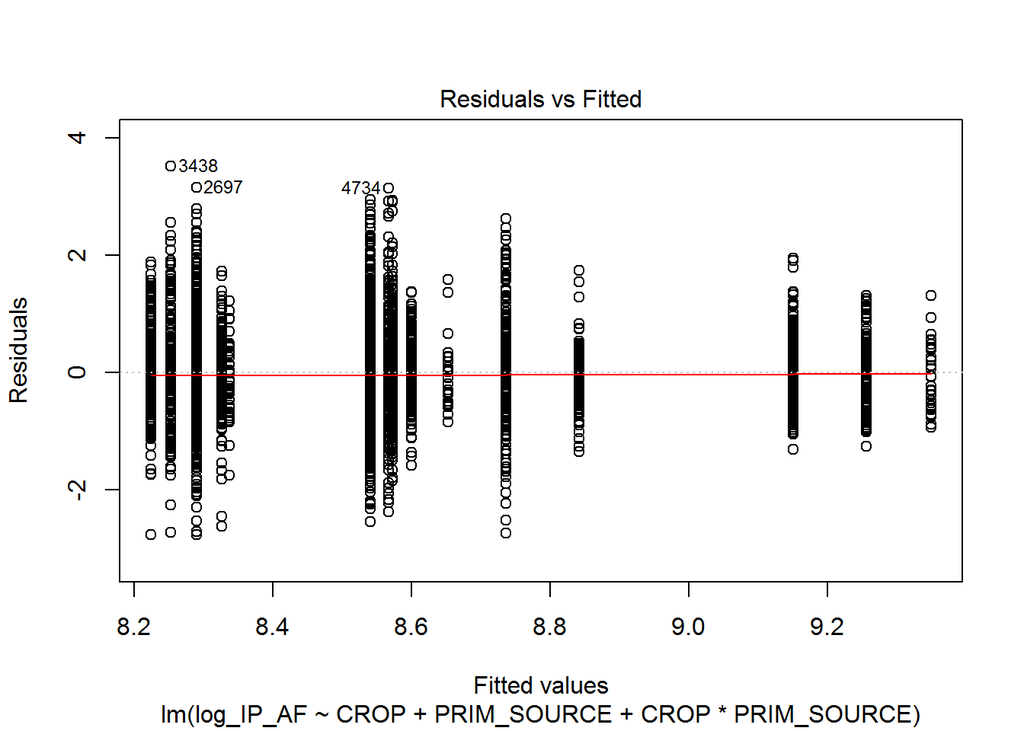

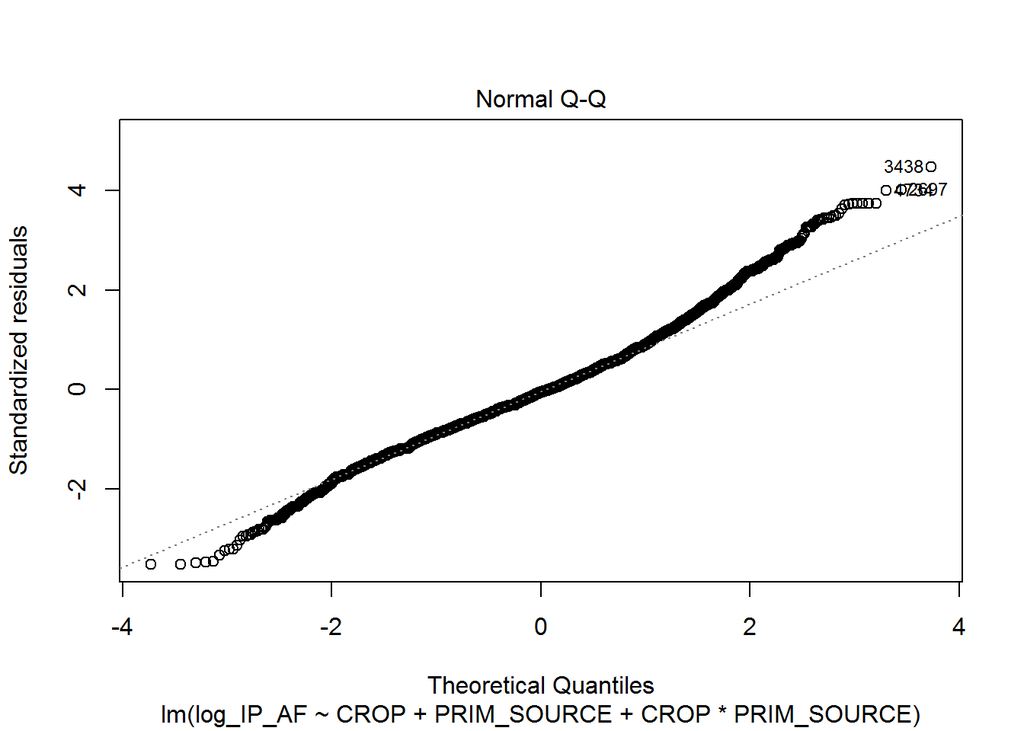

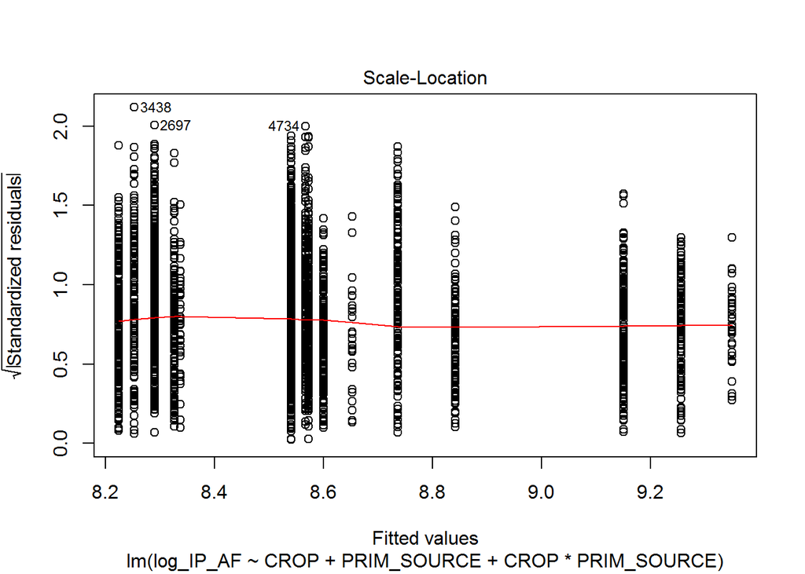

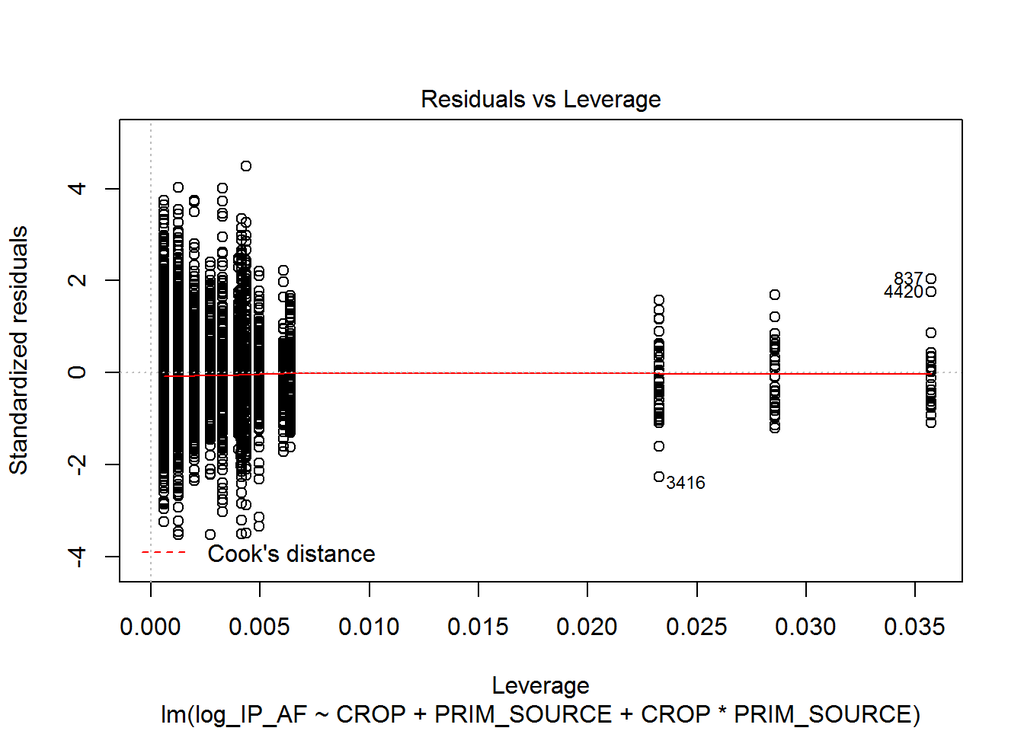

```r
# select only where prim_source is a single category
source <- anova_data %>% filter(PRIM_SOURCE == "OFF_FARM" | PRIM_SOURCE == "ONFARM_SURFACE" | PRIM_SOURCE == "WELL_WATER")

crop_lm <- lm(log_IP_AF ~ CROP + PRIM_SOURCE + CROP*PRIM_SOURCE, data = source)
plot(crop_lm)
```

```r
summary(crop_lm)
```

```
##
## Call:
## lm(formula = log_IP_AF ~ CROP + PRIM_SOURCE + CROP * PRIM_SOURCE,
##     data = source)
##
## Residuals:
##     Min      1Q  Median      3Q     Max
## -2.7718 -0.5021 -0.0467  0.4343  3.5223
##
## Coefficients:
##                                           Estimate Std. Error t value
## (Intercept)                                8.54147    0.01910 447.287
## CROPCORN_GRAIN                             0.05869    0.05407   1.086
## CROPCORN_SILAGE                            0.60994    0.05340  11.422
## CROPOTHER_HAY                             -0.25132    0.03392  -7.410
## CROPWHEAT                                 -0.31718    0.04540  -6.987
## PRIM_SOURCEONFARM_SURFACE                  0.02554    0.04894   0.522
## PRIM_SOURCEWELL_WATER                      0.03157    0.04010   0.787
## CROPCORN_GRAIN:PRIM_SOURCEONFARM_SURFACE   0.02734    0.16452   0.166
## CROPCORN_SILAGE:PRIM_SOURCEONFARM_SURFACE  0.17289    0.15024   1.151
## CROPOTHER_HAY:PRIM_SOURCEONFARM_SURFACE   -0.06275    0.07671  -0.818
## CROPWHEAT:PRIM_SOURCEONFARM_SURFACE        0.08820    0.13598   0.649
## CROPCORN_GRAIN:PRIM_SOURCEWELL_WATER       0.20991    0.08899   2.359
## CROPCORN_SILAGE:PRIM_SOURCEWELL_WATER      0.07376    0.08966   0.823
## CROPOTHER_HAY:PRIM_SOURCEWELL_WATER        0.41474    0.07045   5.887
## CROPWHEAT:PRIM_SOURCEWELL_WATER            0.07032    0.07981   0.881
##                                                       Pr(>|t|)
## (Intercept)                               < 0.0000000000000002 ***
## CROPCORN_GRAIN                                          0.2777
## CROPCORN_SILAGE                           < 0.0000000000000002 ***
## CROPOTHER_HAY                                0.000000000000147 ***
## CROPWHEAT                                    0.000000000003169 ***
## PRIM_SOURCEONFARM_SURFACE                               0.6018
## PRIM_SOURCEWELL_WATER                                   0.4312
## CROPCORN_GRAIN:PRIM_SOURCEONFARM_SURFACE                0.8680
## CROPCORN_SILAGE:PRIM_SOURCEONFARM_SURFACE               0.2499
## CROPOTHER_HAY:PRIM_SOURCEONFARM_SURFACE                 0.4134
## CROPWHEAT:PRIM_SOURCEONFARM_SURFACE                     0.5166
## CROPCORN_GRAIN:PRIM_SOURCEWELL_WATER                    0.0184 *
## CROPCORN_SILAGE:PRIM_SOURCEWELL_WATER                   0.4107
## CROPOTHER_HAY:PRIM_SOURCEWELL_WATER          0.000000004177477 ***
## CROPWHEAT:PRIM_SOURCEWELL_WATER                         0.3783
## ---
## Signif. codes:  0 '***' 0.001 '**' 0.01 '*' 0.05 '.' 0.1 ' ' 1
##
## Residual standard error: 0.7869 on 5230 degrees of freedom
## Multiple R-squared:  0.09462,    Adjusted R-squared:  0.09219
## F-statistic: 39.04 on 14 and 5230 DF,  p-value: < 0.00000000000000022
```

```r
cropsource_aov <- Anova(crop_lm, type = "III")
cropsource_aov
```

```
## Anova Table (Type III tests)
##
## Response: log_IP_AF
##                  Sum Sq   Df     F value                Pr(>F)
## (Intercept)      123881    1 200065.6684 < 0.00000000000000022 ***
## CROP                173    4     70.0223 < 0.00000000000000022 ***
## PRIM_SOURCE           0    2      0.3829                0.6819
## CROP:PRIM_SOURCE     28    8      5.6227          0.0000003989 ***
## Residuals          3238 5230
## ---
## Signif. codes:  0 '***' 0.001 '**' 0.01 '*' 0.05 '.' 0.1 ' ' 1
```

```r
# Let's do multiple one-way ANOVAs; ie. an ANOVA for each crop-source combination
# Alfalfa
alf_data <- source %>% filter(CROP == "ALFALFA")
alf_source_aov <- aov(log_IP_AF ~ PRIM_SOURCE, data = alf_data)
summary(alf_source_aov) # mean ip is the same across souces in Alfalfa
```

```
##               Df Sum Sq Mean Sq F value Pr(>F)
## PRIM_SOURCE    2    0.5  0.2371   0.368  0.692
## Residuals   2498 1608.2  0.6438
```

```r
# Corn grain
cg_data <- source %>% filter(CROP == "CORN_GRAIN")
cg_source_aov <- aov(log_IP_AF ~ PRIM_SOURCE, data = cg_data)
summary(cg_source_aov) # mean ip is NOT the same across souces in Corn Grain
```

```
##              Df Sum Sq Mean Sq F value    Pr(>F)
## PRIM_SOURCE   2   5.77  2.8869   11.63 0.0000121 ***
## Residuals   432 107.27  0.2483
## ---
## Signif. codes:  0 '***' 0.001 '**' 0.01 '*' 0.05 '.' 0.1 ' ' 1
```

```r
cg_source_post_hoc <- TukeyHSD(cg_source_aov)
cg_source_post_hoc
```

```
##   Tukey multiple comparisons of means
##     95% family-wise confidence level
##
## Fit: aov(formula = log_IP_AF ~ PRIM_SOURCE, data = cg_data)
##
## $PRIM_SOURCE
##                                 diff         lwr       upr     p adj
## ONFARM_SURFACE-OFF_FARM   0.05287823 -0.18105846 0.2868149 0.8558555
## WELL_WATER-OFF_FARM       0.24147724  0.12315928 0.3597952 0.0000065
## WELL_WATER-ONFARM_SURFACE 0.18859902 -0.05093148 0.4281295 0.1542265
```

```r
cg_source_ss <- cg_data %>%
  group_by(PRIM_SOURCE) %>%
  summarise(mean = mean(IP_AF),
            sd = sd(IP_AF),
            med = median(IP_AF))

cg_source_ss
```

```
## # A tibble: 3 x 4
##   PRIM_SOURCE     mean    sd   med
##   <chr>          <dbl> <dbl> <dbl>
## 1 OFF_FARM       6195. 3448. 5451.
## 2 ONFARM_SURFACE 6926. 5648. 5547.
## 3 WELL_WATER     7749. 4438. 7280
```

```r
# Corn silage
cs_data <- source %>% filter(CROP == "CORN_SILAGE")
cs_source_aov <- aov(log_IP_AF ~ PRIM_SOURCE, data = cs_data)
summary(cs_source_aov) # mean ip is the same across souces in Corn Silage
```

```
##              Df Sum Sq Mean Sq F value Pr(>F)
## PRIM_SOURCE   2   1.87  0.9348   2.539 0.0801 .
## Residuals   438 161.26  0.3682
## ---
## Signif. codes:  0 '***' 0.001 '**' 0.01 '*' 0.05 '.' 0.1 ' ' 1
```

```r
# Hay
hay_data <- source %>% filter(CROP == "OTHER_HAY")
hay_source_aov <- aov(log_IP_AF ~ PRIM_SOURCE, data = hay_data)
summary(hay_source_aov) # mean ip is NOT the same across souces in HAy
```

```
##               Df Sum Sq Mean Sq F value         Pr(>F)
## PRIM_SOURCE    2   40.5  20.262    22.8 0.000000000187 ***
## Residuals   1255 1115.1   0.889
## ---
## Signif. codes:  0 '***' 0.001 '**' 0.01 '*' 0.05 '.' 0.1 ' ' 1
```

```r
hay_source_post_hoc <- TukeyHSD(hay_source_aov)
hay_source_post_hoc
```

```
##   Tukey multiple comparisons of means
##     95% family-wise confidence level
##
## Fit: aov(formula = log_IP_AF ~ PRIM_SOURCE, data = hay_data)
##
## $PRIM_SOURCE
##                                  diff        lwr       upr     p adj
## ONFARM_SURFACE-OFF_FARM   -0.03720575 -0.2032555 0.1288440 0.8587348
## WELL_WATER-OFF_FARM        0.44630443  0.2834894 0.6091195 0.0000000
## WELL_WATER-ONFARM_SURFACE  0.48351018  0.2793922 0.6876281 0.0000001
```

```r
hay_source_ss <- hay_data %>%
  group_by(PRIM_SOURCE) %>%
  summarise(mean = mean(IP_AF),
            sd = sd(IP_AF),
            med = median(IP_AF))

hay_source_ss
```

```
## # A tibble: 3 x 4
##   PRIM_SOURCE      mean     sd   med
##   <chr>           <dbl>  <dbl> <dbl>
## 1 OFF_FARM        6466.  8788. 3846.
## 2 ONFARM_SURFACE  6496. 10833. 3529.
## 3 WELL_WATER     10523. 13145. 5200
```

```r
# Wheat
wh_data <- source %>% filter(CROP == "WHEAT")
wh_source_aov <- aov(log_IP_AF ~ PRIM_SOURCE, data = wh_data)
summary(wh_source_aov) # mean ip is the same across souces in Wheat
```

```
##              Df Sum Sq Mean Sq F value Pr(>F)
## PRIM_SOURCE   2   1.59  0.7948   1.957  0.142
## Residuals   607 246.56  0.4062
```

**Conclusion**: Analysis by two-way ANOVA revealed that irrigation productivity differs significantly by crop (F(4) = 70.0, *p* < 0.001), but not primary source (F(2) = 0.38, *p* = 0.68), and there is a significant interaction between crop and primary source (F(8) = 5.6, *p* < 0.001).

### Water Distribution Type

*Key Variables Code Chunk R)*: K250, K260, K280, K340, K350. These variables represent:

K250: primary method of water distribution (by crop).

I took the 24 potential codes reported by irrigators and created a binary response: Gravity (15-24) or Pressure (1-14) in irrigation-productivity.Rmd.

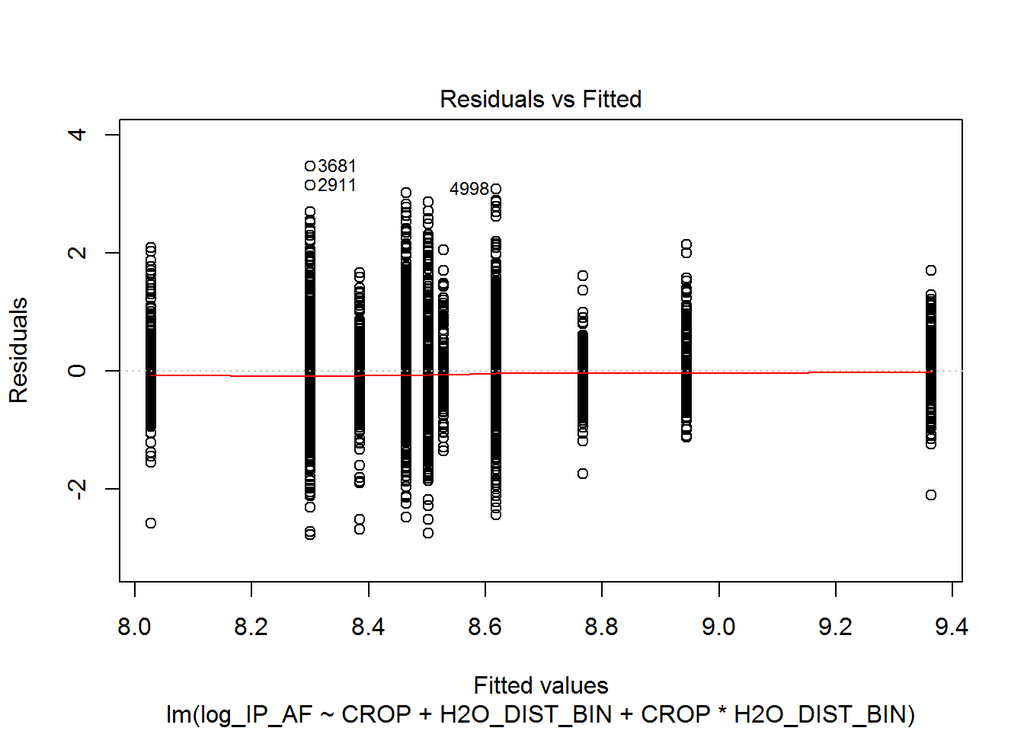

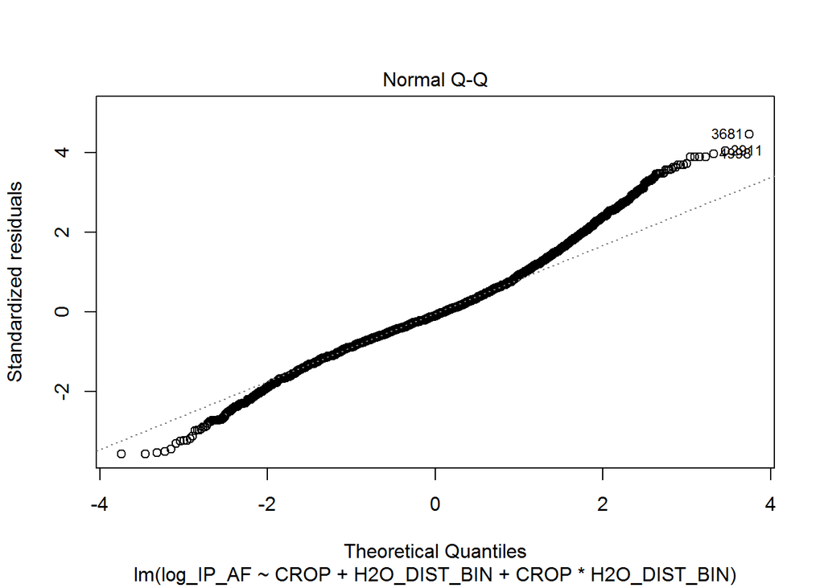

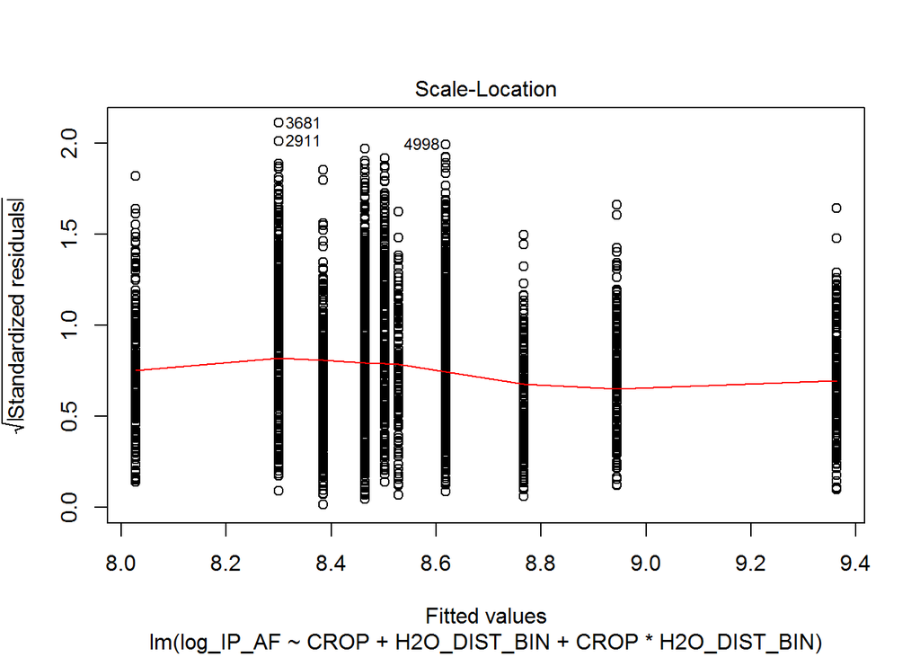

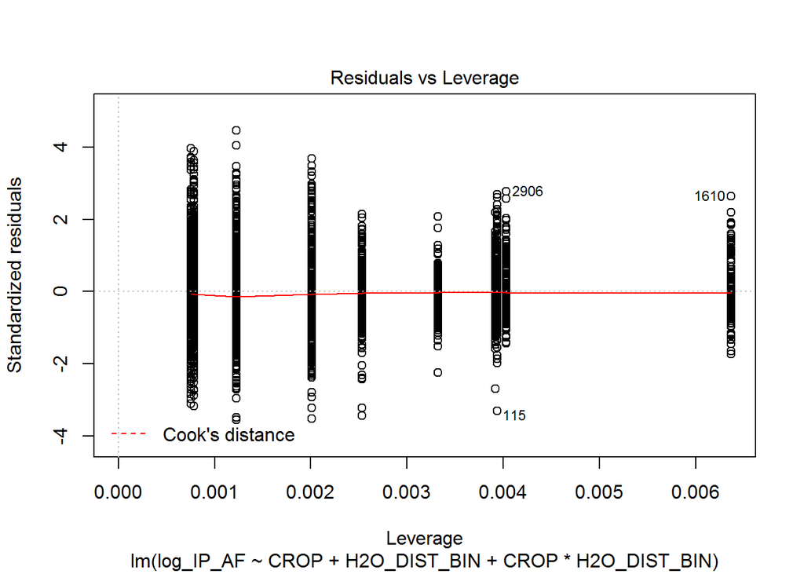

```r
# H2O_DIST_BIN
distbin_lm <- lm(log_IP_AF ~ CROP + H2O_DIST_BIN + CROP*H2O_DIST_BIN, data = anova_data)
plot(distbin_lm)
```

```r
summary(distbin_lm)
```

```
##
## Call:
## lm(formula = log_IP_AF ~ CROP + H2O_DIST_BIN + CROP * H2O_DIST_BIN,
##     data = anova_data)
##
## Residuals:
##     Min      1Q  Median      3Q     Max
## -2.7791 -0.4765 -0.0769  0.4184  3.4748
##
## Coefficients:
##                                      Estimate Std. Error t value
## (Intercept)                           8.46426    0.02186 387.190
## CROPCORN_GRAIN                        0.06450    0.06593   0.978
## CROPCORN_SILAGE                       0.48046    0.05410   8.880
## CROPOTHER_HAY                        -0.16375    0.03495  -4.686
## CROPWHEAT                            -0.43687    0.05357  -8.156
## H2O_DIST_BINPRESSURE                  0.15437    0.03058   5.048
## CROPCORN_GRAIN:H2O_DIST_BINPRESSURE   0.08424    0.08260   1.020
## CROPCORN_SILAGE:H2O_DIST_BINPRESSURE  0.26375    0.07594   3.473
## CROPOTHER_HAY:H2O_DIST_BINPRESSURE    0.04685    0.05386   0.870
## CROPWHEAT:H2O_DIST_BINPRESSURE        0.20319    0.06974   2.913
##                                                  Pr(>|t|)
## (Intercept)                          < 0.0000000000000002 ***
## CROPCORN_GRAIN                                   0.327940
## CROPCORN_SILAGE                      < 0.0000000000000002 ***
## CROPOTHER_HAY                        0.000002859475038028 ***
## CROPWHEAT                            0.000000000000000425 ***
## H2O_DIST_BINPRESSURE                 0.000000461346341026 ***
## CROPCORN_GRAIN:H2O_DIST_BINPRESSURE              0.307832
## CROPCORN_SILAGE:H2O_DIST_BINPRESSURE             0.000518 ***
## CROPOTHER_HAY:H2O_DIST_BINPRESSURE               0.384415
## CROPWHEAT:H2O_DIST_BINPRESSURE                   0.003590 **
## ---
## Signif. codes:  0 '***' 0.001 '**' 0.01 '*' 0.05 '.' 0.1 ' ' 1
##
## Residual standard error: 0.7794 on 5513 degrees of freedom
## Multiple R-squared:  0.09904,    Adjusted R-squared:  0.09757
## F-statistic: 67.34 on 9 and 5513 DF,  p-value: < 0.00000000000000022
```

```r
cropdistbin_aov <- Anova(distbin_lm, type = "III")
cropdistbin_aov
```

```
## Anova Table (Type III tests)
##
## Response: log_IP_AF
##                   Sum Sq   Df     F value                Pr(>F)
## (Intercept)        91059    1 149916.0795 < 0.00000000000000022 ***
## CROP                 123    4     50.8033 < 0.00000000000000022 ***
## H2O_DIST_BIN          15    1     25.4800          0.0000004613 ***
## CROP:H2O_DIST_BIN     11    4      4.4461              0.001375 **
## Residuals           3349 5513
## ---
## Signif. codes:  0 '***' 0.001 '**' 0.01 '*' 0.05 '.' 0.1 ' ' 1
```

```r
distbin_ss <- anova_data %>%
  group_by(H2O_DIST_BIN) %>%
  summarise(mean = mean(IP_AF),
            sd = sd(IP_AF),
            med = median(IP_AF))

distbin_ss
```

```
## # A tibble: 2 x 4
##   H2O_DIST_BIN  mean    sd   med
##   <chr>        <dbl> <dbl> <dbl>
## 1 GRAVITY      6947. 9369. 4087.
## 2 PRESSURE     7864. 8598. 5467.
```

```r
# Let's do multiple one-way ANOVAs; ie. an ANOVA for each crop-distribution combination
# Alfalfa
alf_data <- anova_data %>% filter(CROP == "ALFALFA")
alf_dist_aov <- aov(log_IP_AF ~ H2O_DIST_BIN, data = alf_data)
summary(alf_dist_aov) # mean ip is NOT the same across distribution types in Alfalfa
```

```
##                Df Sum Sq Mean Sq F value      Pr(>F)
## H2O_DIST_BIN    1   15.5  15.477   24.47 0.000000802 ***
## Residuals    2597 1642.3   0.632
## ---
## Signif. codes:  0 '***' 0.001 '**' 0.01 '*' 0.05 '.' 0.1 ' ' 1
```

```r
alf_dist_ss <- alf_data %>%
  group_by(H2O_DIST_BIN) %>%
  summarise(mean = mean(IP_AF),
            sd = sd(IP_AF),
            med = median(IP_AF))

alf_dist_ss
```

```
## # A tibble: 2 x 4
##   H2O_DIST_BIN  mean     sd   med
##   <chr>        <dbl>  <dbl> <dbl>
## 1 GRAVITY      7280. 10300.  4000
## 2 PRESSURE     7656.  9215.  5100
```

```r
# Corn grain
cg_data <- anova_data %>% filter(CROP == "CORN_GRAIN")
cg_dist_aov <- aov(log_IP_AF ~ H2O_DIST_BIN, data = cg_data)
summary(cg_dist_aov) # mean ip is NOT the same across distribution types in Corn Grain
```

```
##               Df Sum Sq Mean Sq F value     Pr(>F)
## H2O_DIST_BIN   1   5.87   5.875   22.96 0.00000224 ***
## Residuals    456 116.67   0.256
## ---
## Signif. codes:  0 '***' 0.001 '**' 0.01 '*' 0.05 '.' 0.1 ' ' 1
```

```r
cg_dist_ss <- cg_data %>%
  group_by(H2O_DIST_BIN) %>%
  summarise(mean = mean(IP_AF),
            sd = sd(IP_AF),
            med = median(IP_AF))

cg_dist_ss
```

```
## # A tibble: 2 x 4
##   H2O_DIST_BIN  mean    sd   med
##   <chr>        <dbl> <dbl> <dbl>
## 1 GRAVITY      6325. 5206. 4480
## 2 PRESSURE     7029. 3290. 6285.
```

```r
# Corn silage
cs_data <- anova_data %>% filter(CROP == "CORN_SILAGE")
cs_dist_aov <- aov(log_IP_AF ~ H2O_DIST_BIN, data = cs_data)
summary(cs_dist_aov) # mean ip is NOT the same across distribution types in Corn Silage
```

```
##               Df Sum Sq Mean Sq F value              Pr(>F)
## H2O_DIST_BIN   1  21.98  21.980    66.4 0.00000000000000296 ***
## Residuals    501 165.85   0.331
## ---
## Signif. codes:  0 '***' 0.001 '**' 0.01 '*' 0.05 '.' 0.1 ' ' 1
```

```r
cs_dist_ss <- cs_data %>%
  group_by(H2O_DIST_BIN) %>%
  summarise(mean = mean(IP_AF),
            sd = sd(IP_AF),
            med = median(IP_AF))

cs_dist_ss
```

```
## # A tibble: 2 x 4
##   H2O_DIST_BIN   mean    sd    med
##   <chr>         <dbl> <dbl>  <dbl>
## 1 GRAVITY       9360. 7774.  6768.
## 2 PRESSURE     13750. 8587. 11360
```

```r
# Hay
hay_data <- anova_data %>% filter(CROP == "OTHER_HAY")
hay_dist_aov <- aov(log_IP_AF ~ H2O_DIST_BIN, data = hay_data)
summary(hay_dist_aov) # mean ip is NOT the same across distribution types in HAy
```

```
##                Df Sum Sq Mean Sq F value   Pr(>F)
## H2O_DIST_BIN    1   12.5  12.512   13.88 0.000203 ***
## Residuals    1312 1182.7   0.901
## ---
## Signif. codes:  0 '***' 0.001 '**' 0.01 '*' 0.05 '.' 0.1 ' ' 1
```

```r
hay_dist_ss <- hay_data %>%
  group_by(H2O_DIST_BIN) %>%
  summarise(mean = mean(IP_AF),
            sd = sd(IP_AF),
            med = median(IP_AF))

hay_dist_ss
```

```
## # A tibble: 2 x 4
##   H2O_DIST_BIN  mean     sd   med
##   <chr>        <dbl>  <dbl> <dbl>
## 1 GRAVITY      6756.  9896. 3750
## 2 PRESSURE     8068. 10477. 4571.
```

```r
# Wheat
wh_data <- anova_data %>% filter(CROP == "WHEAT")
wh_dist_aov <- aov(log_IP_AF ~ H2O_DIST_BIN, data = wh_data)
summary(wh_dist_aov) # mean ip is NOT the same across souces in Wheat
```

```
##               Df Sum Sq Mean Sq F value            Pr(>F)
## H2O_DIST_BIN   1  19.76  19.765   53.05 0.000000000000946 ***
## Residuals    647 241.03   0.373
## ---
## Signif. codes:  0 '***' 0.001 '**' 0.01 '*' 0.05 '.' 0.1 ' ' 1
```

```r
wh_dist_ss <- wh_data %>%
  group_by(H2O_DIST_BIN) %>%
  summarise(mean = mean(IP_AF),
            sd = sd(IP_AF),
            med = median(IP_AF))

wh_dist_ss
```

```
## # A tibble: 2 x 4
##   H2O_DIST_BIN  mean    sd   med
##   <chr>        <dbl> <dbl> <dbl>
## 1 GRAVITY      3926. 3585. 2800
## 2 PRESSURE     5144. 3193. 4333.
```

**Conclusion**: Analysis by two-way ANOVA revealed that irrigation productivity differs significantly by crop (F(4) = 50.8, *p* < 0.001), and water distribution type (F(1) = 25.5, *p* < 0.001), and there is a significant interaction between crop and water distribution type (F(4) = 4.4, *p* = 0.001).

**Conclusion**: Irrigation productivity differed significantly by water distribution type across all crops (*p* < 0.001) in 2018. For all crops, irrigation productivity in pressure systems (mean ip ~ 7864 lbs/af) is higher than in gravity systems (mean ip ~ 6947 lbs/af).

### Water Use Scheduling Method

*Key Variables Code Chunk S)*: K1020-K1029 (2013 FRIS & 2018 IWMS) and K527 (2003 & 2008 FRIS); (responses from K527 were separated into K1020-K1029 to merge the four survey years in a different .Rmd).

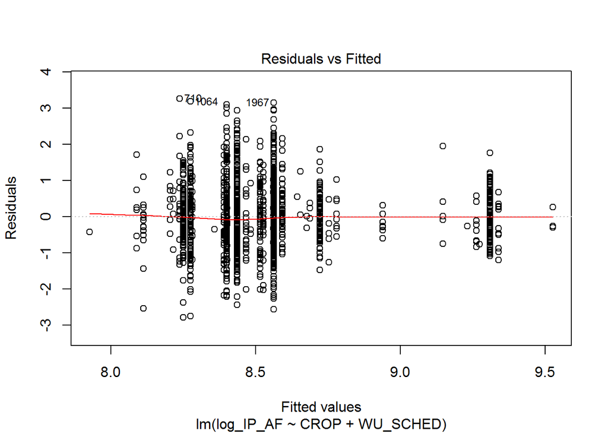

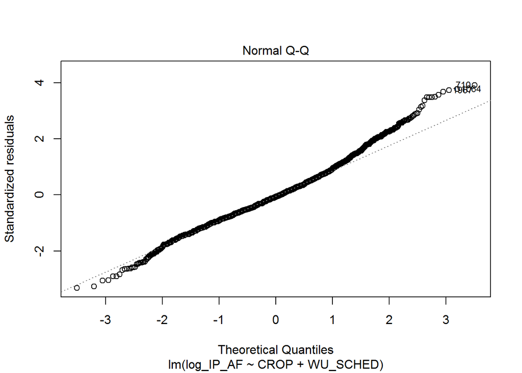

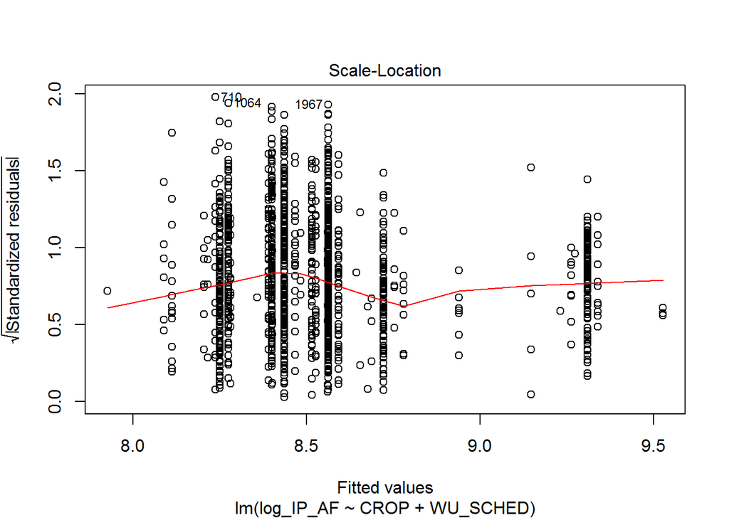

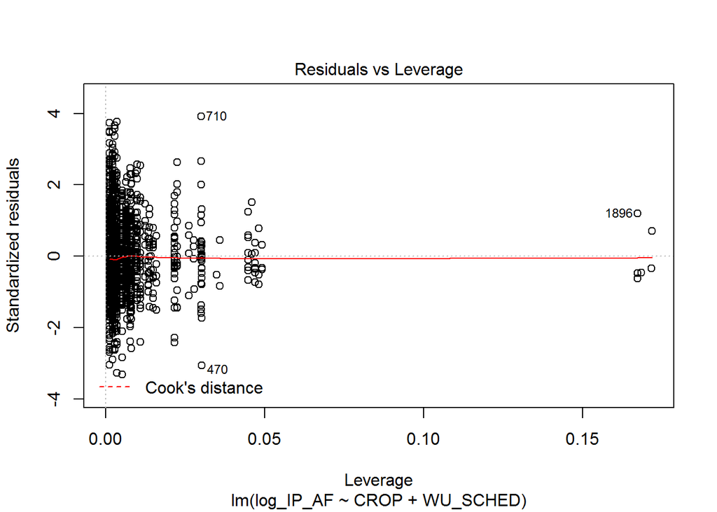

```r
# select only where WU_SCHED is not NA
sched <- anova_data %>% filter(!is.na(WU_SCHED))

# WU_SCHED
sched_lm <- lm(log_IP_AF ~ CROP + WU_SCHED, data = sched) # no interaction term because of NAs with 2 interactions
plot(sched_lm)
```

```r
summary(sched_lm)
```

```
##
## Call:
## lm(formula = log_IP_AF ~ CROP + WU_SCHED, data = sched)
##
## Residuals:
##     Min      1Q  Median      3Q     Max
## -2.7975 -0.5462 -0.0623  0.4757  3.2552
##
## Coefficients:
##                                               Estimate Std. Error t value
## (Intercept)                                    8.56167    0.02946 290.630
## CROPCORN_GRAIN                                 0.16075    0.07377   2.179
## CROPCORN_SILAGE                                0.74772    0.07255  10.307
## CROPOTHER_HAY                                 -0.12531    0.04347  -2.883
## CROPWHEAT                                     -0.31172    0.06621  -4.708
## WU_SCHEDDAILY CROP-WATER ET USE               -0.07847    0.34540  -0.227
## WU_SCHEDFEEL OF THE SOIL                       0.03054    0.08503   0.359
## WU_SCHEDIRRIGATION SCHEDULING SERVICE         -0.03520    0.12526  -0.281
## WU_SCHEDPERSONAL CALENDAR SCHEDULE            -0.04604    0.07551  -0.610
## WU_SCHEDSOIL MOISTURE DEVICE                   0.21739    0.17815   1.220
## WU_SCHEDWHEN NEIGHBORS BEGAN TO IRRIGATE      -0.32416    0.14684  -2.208
## WU_SCHEDWHEN WATER WAS DELIVERED OR AVAILABLE -0.16208    0.04867  -3.330
##                                                           Pr(>|t|)
## (Intercept)                                   < 0.0000000000000002 ***
## CROPCORN_GRAIN                                            0.029436 *
## CROPCORN_SILAGE                               < 0.0000000000000002 ***
## CROPOTHER_HAY                                             0.003978 **
## CROPWHEAT                                               0.00000266 ***
## WU_SCHEDDAILY CROP-WATER ET USE                           0.820295
## WU_SCHEDFEEL OF THE SOIL                                  0.719480
## WU_SCHEDIRRIGATION SCHEDULING SERVICE                     0.778706
## WU_SCHEDPERSONAL CALENDAR SCHEDULE                        0.542132
## WU_SCHEDSOIL MOISTURE DEVICE                              0.222497
## WU_SCHEDWHEN NEIGHBORS BEGAN TO IRRIGATE                  0.027383 *
## WU_SCHEDWHEN WATER WAS DELIVERED OR AVAILABLE             0.000883 ***
## ---
## Signif. codes:  0 '***' 0.001 '**' 0.01 '*' 0.05 '.' 0.1 ' ' 1
##
## Residual standard error: 0.8439 on 2171 degrees of freedom
## Multiple R-squared:  0.08396,    Adjusted R-squared:  0.07932
## F-statistic: 18.09 on 11 and 2171 DF,  p-value: < 0.00000000000000022
```

```r
cropsched_aov <- Anova(sched_lm, type = "III")
cropsched_aov
```

```
## Anova Table (Type III tests)
##
## Response: log_IP_AF
##             Sum Sq   Df    F value               Pr(>F)
## (Intercept)  60152    1 84465.8934 < 0.0000000000000002 ***
## CROP           119    4    41.7186 < 0.0000000000000002 ***
## WU_SCHED        12    7     2.4845              0.01532 *
## Residuals     1546 2171
## ---
## Signif. codes:  0 '***' 0.001 '**' 0.01 '*' 0.05 '.' 0.1 ' ' 1
```

```r
# Let's do multiple one-way ANOVAs; ie. an ANOVA for each crop-scheduling combination
# Alfalfa
alf_data <- sched %>% filter(CROP == "ALFALFA")
alf_sched_aov <- aov(log_IP_AF ~ WU_SCHED, data = alf_data)
summary(alf_sched_aov) # mean ip is NOT the same across scheduling method in Alfalfa
```

```
##               Df Sum Sq Mean Sq F value Pr(>F)
## WU_SCHED       7   10.2  1.4505   2.015 0.0504 .
## Residuals   1088  783.3  0.7199
## ---
## Signif. codes:  0 '***' 0.001 '**' 0.01 '*' 0.05 '.' 0.1 ' ' 1
```

```r
alf_sched_post_hoc <- TukeyHSD(alf_sched_aov)
alf_sched_post_hoc
```

```
##   Tukey multiple comparisons of means
##     95% family-wise confidence level
##
## Fit: aov(formula = log_IP_AF ~ WU_SCHED, data = alf_data)
##
## $WU_SCHED
##                                                                                diff
## DAILY CROP-WATER ET USE-CONDITION OF CROP                              -0.037101764
## FEEL OF THE SOIL-CONDITION OF CROP                                      0.228731245
## IRRIGATION SCHEDULING SERVICE-CONDITION OF CROP                        -0.123976219
## PERSONAL CALENDAR SCHEDULE-CONDITION OF CROP                            0.009631288
## SOIL MOISTURE DEVICE-CONDITION OF CROP                                  0.330762953
## WHEN NEIGHBORS BEGAN TO IRRIGATE-CONDITION OF CROP                     -0.001083859
## WHEN WATER WAS DELIVERED OR AVAILABLE-CONDITION OF CROP                -0.168999116
## FEEL OF THE SOIL-DAILY CROP-WATER ET USE                                0.265833009
## IRRIGATION SCHEDULING SERVICE-DAILY CROP-WATER ET USE                  -0.086874455
## PERSONAL CALENDAR SCHEDULE-DAILY CROP-WATER ET USE                      0.046733052
## SOIL MOISTURE DEVICE-DAILY CROP-WATER ET USE                            0.367864717
## WHEN NEIGHBORS BEGAN TO IRRIGATE-DAILY CROP-WATER ET USE                0.036017905
## WHEN WATER WAS DELIVERED OR AVAILABLE-DAILY CROP-WATER ET USE          -0.131897352
## IRRIGATION SCHEDULING SERVICE-FEEL OF THE SOIL                         -0.352707464
## PERSONAL CALENDAR SCHEDULE-FEEL OF THE SOIL                            -0.219099957
## SOIL MOISTURE DEVICE-FEEL OF THE SOIL                                   0.102031708
## WHEN NEIGHBORS BEGAN TO IRRIGATE-FEEL OF THE SOIL                      -0.229815104
## WHEN WATER WAS DELIVERED OR AVAILABLE-FEEL OF THE SOIL                 -0.397730361
## PERSONAL CALENDAR SCHEDULE-IRRIGATION SCHEDULING SERVICE                0.133607507
## SOIL MOISTURE DEVICE-IRRIGATION SCHEDULING SERVICE                      0.454739172
## WHEN NEIGHBORS BEGAN TO IRRIGATE-IRRIGATION SCHEDULING SERVICE          0.122892360
## WHEN WATER WAS DELIVERED OR AVAILABLE-IRRIGATION SCHEDULING SERVICE    -0.045022896
## SOIL MOISTURE DEVICE-PERSONAL CALENDAR SCHEDULE                         0.321131665
## WHEN NEIGHBORS BEGAN TO IRRIGATE-PERSONAL CALENDAR SCHEDULE            -0.010715147
## WHEN WATER WAS DELIVERED OR AVAILABLE-PERSONAL CALENDAR SCHEDULE       -0.178630404
## WHEN NEIGHBORS BEGAN TO IRRIGATE-SOIL MOISTURE DEVICE                  -0.331846812
## WHEN WATER WAS DELIVERED OR AVAILABLE-SOIL MOISTURE DEVICE             -0.499762068
## WHEN WATER WAS DELIVERED OR AVAILABLE-WHEN NEIGHBORS BEGAN TO IRRIGATE -0.167915257
##                                                                               lwr
## DAILY CROP-WATER ET USE-CONDITION OF CROP                              -1.5280457
## FEEL OF THE SOIL-CONDITION OF CROP                                     -0.1387419
## IRRIGATION SCHEDULING SERVICE-CONDITION OF CROP                        -0.6388814
## PERSONAL CALENDAR SCHEDULE-CONDITION OF CROP                           -0.3138083
```

[output cut: 67 more lines]

```
## IRRIGATION SCHEDULING SERVICE-FEEL OF THE SOIL                         0.6634672
## PERSONAL CALENDAR SCHEDULE-FEEL OF THE SOIL                            0.8489690
## SOIL MOISTURE DEVICE-FEEL OF THE SOIL                                  0.9999845
## WHEN NEIGHBORS BEGAN TO IRRIGATE-FEEL OF THE SOIL                      0.9783018
## WHEN WATER WAS DELIVERED OR AVAILABLE-FEEL OF THE SOIL                 0.0430911
## PERSONAL CALENDAR SCHEDULE-IRRIGATION SCHEDULING SERVICE               0.9973688
## SOIL MOISTURE DEVICE-IRRIGATION SCHEDULING SERVICE                     0.8891634
## WHEN NEIGHBORS BEGAN TO IRRIGATE-IRRIGATION SCHEDULING SERVICE         0.9997936
## WHEN WATER WAS DELIVERED OR AVAILABLE-IRRIGATION SCHEDULING SERVICE    0.9999963
## SOIL MOISTURE DEVICE-PERSONAL CALENDAR SCHEDULE                        0.9723853
## WHEN NEIGHBORS BEGAN TO IRRIGATE-PERSONAL CALENDAR SCHEDULE            1.0000000
## WHEN WATER WAS DELIVERED OR AVAILABLE-PERSONAL CALENDAR SCHEDULE       0.7803776
## WHEN NEIGHBORS BEGAN TO IRRIGATE-SOIL MOISTURE DEVICE                  0.9849390
## WHEN WATER WAS DELIVERED OR AVAILABLE-SOIL MOISTURE DEVICE             0.7265907
## WHEN WATER WAS DELIVERED OR AVAILABLE-WHEN NEIGHBORS BEGAN TO IRRIGATE 0.9937154
```

```r
alf_sched_ss <- alf_data %>%
  group_by(WU_SCHED) %>%
  summarise(mean = mean(IP_AF),
            sd = sd(IP_AF),
            med = median(IP_AF))

alf_sched_ss
```

```
## # A tibble: 8 x 4
##   WU_SCHED                                mean     sd   med
##   <chr>                                  <dbl>  <dbl> <dbl>
## 1 CONDITION OF CROP                      7617. 10635. 4756.
## 2 DAILY CROP-WATER ET USE                6178.  5218. 3333.
## 3 FEEL OF THE SOIL                       8939.  9085. 6000
## 4 IRRIGATION SCHEDULING SERVICE          6425.  5148. 4800
## 5 PERSONAL CALENDAR SCHEDULE             7576.  7339. 5214.
## 6 SOIL MOISTURE DEVICE                   8115.  4680. 6500
## 7 WHEN NEIGHBORS BEGAN TO IRRIGATE      12322. 23638. 4300
## 8 WHEN WATER WAS DELIVERED OR AVAILABLE  7332. 11666. 4000
```

```r
# Corn grain
cg_data <- sched %>% filter(CROP == "CORN_GRAIN")
cg_sched_aov <- aov(log_IP_AF ~ WU_SCHED, data = cg_data)
summary(cg_sched_aov) # mean ip is the same across scheduling methods in Corn Grain
```

```
##              Df Sum Sq Mean Sq F value Pr(>F)
## WU_SCHED      7   1.59  0.2268   0.762   0.62
## Residuals   145  43.17  0.2977
```

```r
# Corn silage
cs_data <- sched %>% filter(CROP == "CORN_SILAGE")
cs_sched_aov <- aov(log_IP_AF ~ WU_SCHED, data = cs_data)
summary(cs_sched_aov) # mean ip is the same across scheduling methods in Corn Silage
```

```
##              Df Sum Sq Mean Sq F value Pr(>F)
## WU_SCHED      6   2.22  0.3694   0.864  0.523
## Residuals   151  64.59  0.4278
```

```r
# Hay
hay_data <- sched %>% filter(CROP == "OTHER_HAY")
hay_sched_aov <- aov(log_IP_AF ~ WU_SCHED, data = hay_data)
summary(hay_sched_aov) # mean ip is the same across scheduling methods in HAy
```

```
##              Df Sum Sq Mean Sq F value Pr(>F)
## WU_SCHED      7   12.3   1.763   1.827 0.0796 .
## Residuals   572  552.0   0.965
## ---
## Signif. codes:  0 '***' 0.001 '**' 0.01 '*' 0.05 '.' 0.1 ' ' 1
```

```r
# Wheat
wh_data <- sched %>% filter(CROP == "WHEAT")
wh_sched_aov <- aov(log_IP_AF ~ WU_SCHED, data = wh_data)
summary(wh_sched_aov) # mean ip is the same across scheduling methods in Wheat
```

```
##              Df Sum Sq Mean Sq F value Pr(>F)
## WU_SCHED      6   2.07  0.3445   0.748  0.612
## Residuals   189  87.04  0.4605
```

**Conclusion**: Analysis by two-way ANOVA revealed that irrigation productivity differs significantly by crop (F(4) = 41.7, *p* < 0.001), and primary water scheduling practice (F(7) = 2.5, *p* = 0.015).

### Barriers to Implementing Irrigation Improvements

*Key Variables Code Chunk T)*: K1070-K1078 (2013 FRIS and 2018 IWMS) and K695 (2003 & 2008 FRIS); (responses from K695 were separated into K1070-K1078 to merge the four survey years in a different .Rmd).

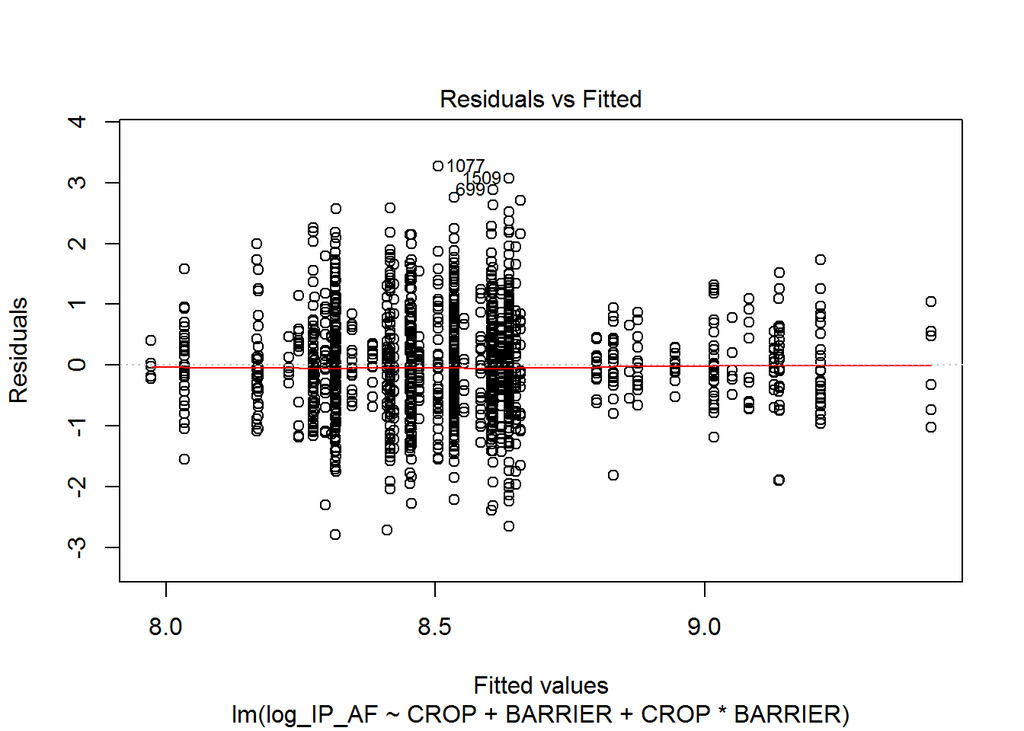

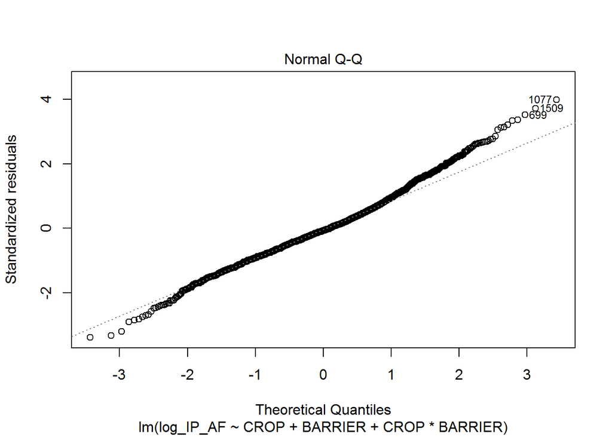

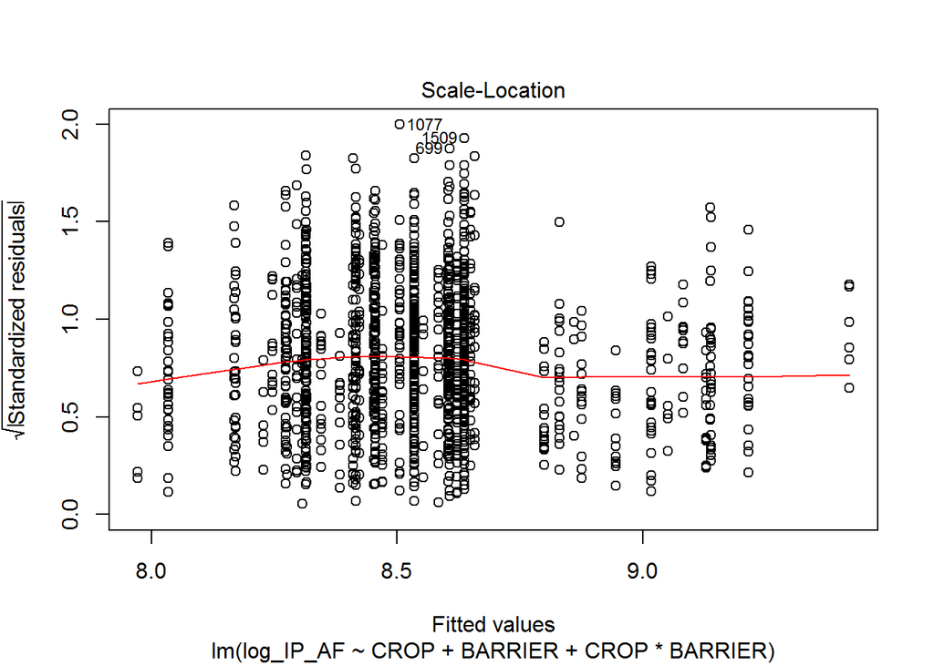

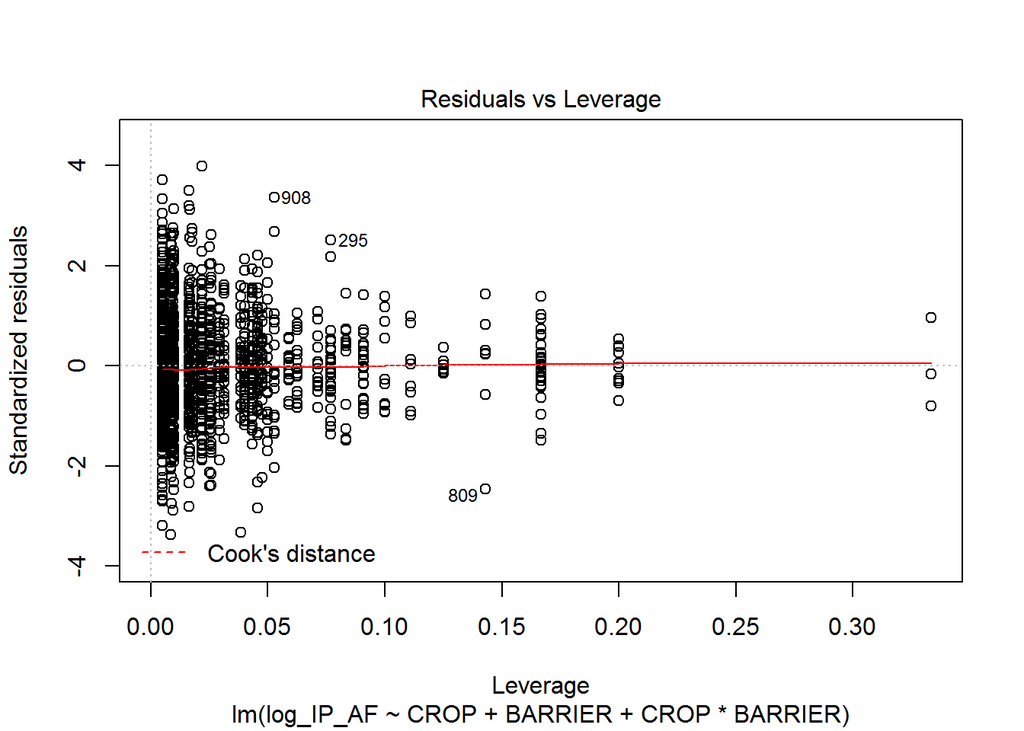

```r
# select only where BARRIER is not NA
barrier <- anova_data %>% filter(!is.na(BARRIER))

# BARRIER
barr_lm <- lm(log_IP_AF ~ CROP + BARRIER + CROP*BARRIER, data = barrier)
plot(barr_lm)
```

```r
summary(barr_lm)
```

```
##
## Call:
## lm(formula = log_IP_AF ~ CROP + BARRIER + CROP * BARRIER, data = barrier)
##
## Residuals:
##     Min      1Q  Median      3Q     Max
## -2.7924 -0.5256 -0.0570  0.4598  3.2700
##
## Coefficients:
##                                                                            Estimate
## (Intercept)                                                                 8.53447
## CROPCORN_GRAIN                                                             -0.06444
## CROPCORN_SILAGE                                                             0.48261
## CROPOTHER_HAY                                                              -0.11885
## CROPWHEAT                                                                  -0.49985
## BARRIERFIELD OR CROP CONDITIONS LIMIT IMPROVEMENTS                         -0.21838
## BARRIERIMPROVEMENTS WILL INCREASE MANAGEMENT TIME OR COSTS                  0.11586
## BARRIERLANDLORD WILL NOT SHARE COST                                         0.05038
## BARRIERNOT A PRIORITY                                                       0.10242
## BARRIERRISK OF REDUCED YIELD                                                0.08894
## BARRIERUNCERTAINTY ABOUT FUTURE WATER AVAILABILITY                         -0.07811
## BARRIERWILL NOT BE FARMING LONG ENOGH TO JUSTIFY                            0.07226
## BARRIERWILL NOT RECOVE IMPLEMENTATION COSTS                                 0.07013
## CROPCORN_GRAIN:BARRIERFIELD OR CROP CONDITIONS LIMIT IMPROVEMENTS           0.36992
## CROPCORN_SILAGE:BARRIERFIELD OR CROP CONDITIONS LIMIT IMPROVEMENTS          0.62215
## CROPOTHER_HAY:BARRIERFIELD OR CROP CONDITIONS LIMIT IMPROVEMENTS            0.25625
## CROPWHEAT:BARRIERFIELD OR CROP CONDITIONS LIMIT IMPROVEMENTS                0.45975
## CROPCORN_GRAIN:BARRIERIMPROVEMENTS WILL INCREASE MANAGEMENT TIME OR COSTS   0.35916
## CROPCORN_SILAGE:BARRIERIMPROVEMENTS WILL INCREASE MANAGEMENT TIME OR COSTS -0.05002
## CROPOTHER_HAY:BARRIERIMPROVEMENTS WILL INCREASE MANAGEMENT TIME OR COSTS   -0.23551
## CROPWHEAT:BARRIERIMPROVEMENTS WILL INCREASE MANAGEMENT TIME OR COSTS        0.07777
## CROPCORN_GRAIN:BARRIERLANDLORD WILL NOT SHARE COST                         -0.21334
## CROPCORN_SILAGE:BARRIERLANDLORD WILL NOT SHARE COST                        -0.01580
## CROPOTHER_HAY:BARRIERLANDLORD WILL NOT SHARE COST                          -0.29719
## CROPWHEAT:BARRIERLANDLORD WILL NOT SHARE COST                              -0.11341
## CROPCORN_GRAIN:BARRIERNOT A PRIORITY                                        0.25834
## CROPCORN_SILAGE:BARRIERNOT A PRIORITY                                       0.09672
## CROPOTHER_HAY:BARRIERNOT A PRIORITY                                        -0.20422
## CROPWHEAT:BARRIERNOT A PRIORITY                                             0.03474
## CROPCORN_GRAIN:BARRIERRISK OF REDUCED YIELD                                 0.38663
```

[output cut: 190 more lines]

```
## CROPWHEAT:BARRIERUNCERTAINTY ABOUT FUTURE WATER AVAILABILITY
## CROPCORN_GRAIN:BARRIERWILL NOT BE FARMING LONG ENOGH TO JUSTIFY
## CROPCORN_SILAGE:BARRIERWILL NOT BE FARMING LONG ENOGH TO JUSTIFY
## CROPOTHER_HAY:BARRIERWILL NOT BE FARMING LONG ENOGH TO JUSTIFY
## CROPWHEAT:BARRIERWILL NOT BE FARMING LONG ENOGH TO JUSTIFY
## CROPCORN_GRAIN:BARRIERWILL NOT RECOVE IMPLEMENTATION COSTS
## CROPCORN_SILAGE:BARRIERWILL NOT RECOVE IMPLEMENTATION COSTS
## CROPOTHER_HAY:BARRIERWILL NOT RECOVE IMPLEMENTATION COSTS
## CROPWHEAT:BARRIERWILL NOT RECOVE IMPLEMENTATION COSTS
## ---
## Signif. codes:  0 '***' 0.001 '**' 0.01 '*' 0.05 '.' 0.1 ' ' 1
##
## Residual standard error: 0.8291 on 1631 degrees of freedom
## Multiple R-squared:  0.07449,    Adjusted R-squared:  0.04952
## F-statistic: 2.983 on 44 and 1631 DF,  p-value: 0.0000000004115
```

```r
cropbarr_aov <- Anova(barr_lm, type = "III")
cropbarr_aov
```

```
## Anova Table (Type III tests)
##
## Response: log_IP_AF
##               Sum Sq   Df    F value                Pr(>F)
## (Intercept)  14858.8    1 21616.9246 < 0.00000000000000022 ***
## CROP            16.9    4     6.1480            0.00006568 ***
## BARRIER          7.0    8     1.2752                 0.252
## CROP:BARRIER    16.6   32     0.7558                 0.836
## Residuals     1121.1 1631
## ---
## Signif. codes:  0 '***' 0.001 '**' 0.01 '*' 0.05 '.' 0.1 ' ' 1
```

```r
# Let's do multiple one-way ANOVAs; ie. an ANOVA for each crop-scheduling combination
# Alfalfa
alf_data <- barrier %>% filter(CROP == "ALFALFA")
alf_liv_aov <- aov(log_IP_AF ~ BARRIER, data = alf_data)
summary(alf_liv_aov) # mean ip is the same across barriers in Alfalfa
```

```
##              Df Sum Sq Mean Sq F value Pr(>F)
## BARRIER       8    7.0  0.8766   1.246  0.269
## Residuals   853  600.2  0.7036
```

```r
# Corn grain
cg_data <- barrier %>% filter(CROP == "CORN_GRAIN")
cg_barr_aov <- aov(log_IP_AF ~ BARRIER, data = cg_data)
summary(cg_barr_aov) # mean ip is the same across barriers in Corn Grain
```

```
##             Df Sum Sq Mean Sq F value Pr(>F)
## BARRIER      8  5.127  0.6409   2.291 0.0274 *
## Residuals   95 26.577  0.2798
## ---
## Signif. codes:  0 '***' 0.001 '**' 0.01 '*' 0.05 '.' 0.1 ' ' 1
```

```r
cg_barr_post_hoc <- TukeyHSD(cg_barr_aov)
cg_barr_post_hoc
```

```
##   Tukey multiple comparisons of means
##     95% family-wise confidence level
##
## Fit: aov(formula = log_IP_AF ~ BARRIER, data = cg_data)
##
## $BARRIER
##                                                                                                          diff
## FIELD OR CROP CONDITIONS LIMIT IMPROVEMENTS-CANNOT FINANCE IMPROVEMENTS                          0.1515373314
## IMPROVEMENTS WILL INCREASE MANAGEMENT TIME OR COSTS-CANNOT FINANCE IMPROVEMENTS                  0.4750267525
## LANDLORD WILL NOT SHARE COST-CANNOT FINANCE IMPROVEMENTS                                        -0.1629629294
## NOT A PRIORITY-CANNOT FINANCE IMPROVEMENTS                                                       0.3607629085
## RISK OF REDUCED YIELD-CANNOT FINANCE IMPROVEMENTS                                                0.4755694060
## UNCERTAINTY ABOUT FUTURE WATER AVAILABILITY-CANNOT FINANCE IMPROVEMENTS                          0.0838684558
## WILL NOT BE FARMING LONG ENOGH TO JUSTIFY-CANNOT FINANCE IMPROVEMENTS                            0.6684903767
## WILL NOT RECOVE IMPLEMENTATION COSTS-CANNOT FINANCE IMPROVEMENTS                                 0.3292955686
## IMPROVEMENTS WILL INCREASE MANAGEMENT TIME OR COSTS-FIELD OR CROP CONDITIONS LIMIT IMPROVEMENTS  0.3234894211
## LANDLORD WILL NOT SHARE COST-FIELD OR CROP CONDITIONS LIMIT IMPROVEMENTS                        -0.3145002608
## NOT A PRIORITY-FIELD OR CROP CONDITIONS LIMIT IMPROVEMENTS                                       0.2092255770
## RISK OF REDUCED YIELD-FIELD OR CROP CONDITIONS LIMIT IMPROVEMENTS                                0.3240320745
## UNCERTAINTY ABOUT FUTURE WATER AVAILABILITY-FIELD OR CROP CONDITIONS LIMIT IMPROVEMENTS         -0.0676688756
## WILL NOT BE FARMING LONG ENOGH TO JUSTIFY-FIELD OR CROP CONDITIONS LIMIT IMPROVEMENTS            0.5169530452
## WILL NOT RECOVE IMPLEMENTATION COSTS-FIELD OR CROP CONDITIONS LIMIT IMPROVEMENTS                 0.1777582371
## LANDLORD WILL NOT SHARE COST-IMPROVEMENTS WILL INCREASE MANAGEMENT TIME OR COSTS                -0.6379896819
## NOT A PRIORITY-IMPROVEMENTS WILL INCREASE MANAGEMENT TIME OR COSTS                              -0.1142638440
## RISK OF REDUCED YIELD-IMPROVEMENTS WILL INCREASE MANAGEMENT TIME OR COSTS                        0.0005426535
## UNCERTAINTY ABOUT FUTURE WATER AVAILABILITY-IMPROVEMENTS WILL INCREASE MANAGEMENT TIME OR COSTS -0.3911582967
## WILL NOT BE FARMING LONG ENOGH TO JUSTIFY-IMPROVEMENTS WILL INCREASE MANAGEMENT TIME OR COSTS    0.1934636242
## WILL NOT RECOVE IMPLEMENTATION COSTS-IMPROVEMENTS WILL INCREASE MANAGEMENT TIME OR COSTS        -0.1457311839
## NOT A PRIORITY-LANDLORD WILL NOT SHARE COST                                                      0.5237258379
## RISK OF REDUCED YIELD-LANDLORD WILL NOT SHARE COST                                               0.6385323354
## UNCERTAINTY ABOUT FUTURE WATER AVAILABILITY-LANDLORD WILL NOT SHARE COST                         0.2468313852
## WILL NOT BE FARMING LONG ENOGH TO JUSTIFY-LANDLORD WILL NOT SHARE COST                           0.8314533061
## WILL NOT RECOVE IMPLEMENTATION COSTS-LANDLORD WILL NOT SHARE COST                                0.4922584980
## RISK OF REDUCED YIELD-NOT A PRIORITY                                                             0.1148064975
## UNCERTAINTY ABOUT FUTURE WATER AVAILABILITY-NOT A PRIORITY                                      -0.2768944527
## WILL NOT BE FARMING LONG ENOGH TO JUSTIFY-NOT A PRIORITY                                         0.3077274682
## WILL NOT RECOVE IMPLEMENTATION COSTS-NOT A PRIORITY                                             -0.0314673399
## UNCERTAINTY ABOUT FUTURE WATER AVAILABILITY-RISK OF REDUCED YIELD                               -0.3917009502
## WILL NOT BE FARMING LONG ENOGH TO JUSTIFY-RISK OF REDUCED YIELD                                  0.1929209707
## WILL NOT RECOVE IMPLEMENTATION COSTS-RISK OF REDUCED YIELD                                      -0.1462738374
```

[output cut: 99 more lines]

```
## NOT A PRIORITY-LANDLORD WILL NOT SHARE COST                                                     0.4536950
## RISK OF REDUCED YIELD-LANDLORD WILL NOT SHARE COST                                              0.3919472
## UNCERTAINTY ABOUT FUTURE WATER AVAILABILITY-LANDLORD WILL NOT SHARE COST                        0.9932579
## WILL NOT BE FARMING LONG ENOGH TO JUSTIFY-LANDLORD WILL NOT SHARE COST                          0.1216373
## WILL NOT RECOVE IMPLEMENTATION COSTS-LANDLORD WILL NOT SHARE COST                               0.5746332
## RISK OF REDUCED YIELD-NOT A PRIORITY                                                            0.9998476
## UNCERTAINTY ABOUT FUTURE WATER AVAILABILITY-NOT A PRIORITY                                      0.9247697
## WILL NOT BE FARMING LONG ENOGH TO JUSTIFY-NOT A PRIORITY                                        0.9187412
## WILL NOT RECOVE IMPLEMENTATION COSTS-NOT A PRIORITY                                             1.0000000
## UNCERTAINTY ABOUT FUTURE WATER AVAILABILITY-RISK OF REDUCED YIELD                               0.8414499
## WILL NOT BE FARMING LONG ENOGH TO JUSTIFY-RISK OF REDUCED YIELD                                 0.9986197
## WILL NOT RECOVE IMPLEMENTATION COSTS-RISK OF REDUCED YIELD                                      0.9992722
## WILL NOT BE FARMING LONG ENOGH TO JUSTIFY-UNCERTAINTY ABOUT FUTURE WATER AVAILABILITY           0.4184958
## WILL NOT RECOVE IMPLEMENTATION COSTS-UNCERTAINTY ABOUT FUTURE WATER AVAILABILITY                0.9688585
## WILL NOT RECOVE IMPLEMENTATION COSTS-WILL NOT BE FARMING LONG ENOGH TO JUSTIFY                  0.8841746
```

```r
cg_barr_ss <- cg_data %>%
  group_by(BARRIER) %>%
  summarise(mean = mean(IP_AF),
            sd = sd(IP_AF),
            med = median(IP_AF))

cg_barr_ss
```

```
## # A tibble: 9 x 4
##   BARRIER                                               mean    sd    med
##   <chr>                                                <dbl> <dbl>  <dbl>
## 1 CANNOT FINANCE IMPROVEMENTS                          5402. 3800.  4878.
## 2 FIELD OR CROP CONDITIONS LIMIT IMPROVEMENTS          6328. 3116.  5823.
## 3 IMPROVEMENTS WILL INCREASE MANAGEMENT TIME OR COSTS  8069. 2655.  9348.
## 4 LANDLORD WILL NOT SHARE COST                         4538. 1897.  4480
## 5 NOT A PRIORITY                                       7927. 4092.  7140
## 6 RISK OF REDUCED YIELD                                7734. 1089.  7302.
## 7 UNCERTAINTY ABOUT FUTURE WATER AVAILABILITY          6058. 3490.  5333.
## 8 WILL NOT BE FARMING LONG ENOGH TO JUSTIFY           12421. 8473. 11200
## 9 WILL NOT RECOVE IMPLEMENTATION COSTS                 6929. 2072.  6976.
```

```r
# Corn silage
cs_data <- barrier %>% filter(CROP == "CORN_SILAGE")
cs_barr_aov <- aov(log_IP_AF ~ BARRIER, data = cs_data)
summary(cs_barr_aov) # mean ip is the same across barriers in Corn Silage
```

```
##              Df Sum Sq Mean Sq F value Pr(>F)
## BARRIER       8   2.11  0.2633   0.642  0.741
## Residuals   122  50.03  0.4101
```

```r
# Hay
hay_data <- barrier %>% filter(CROP == "OTHER_HAY")
hay_barr_aov <- aov(log_IP_AF ~ BARRIER, data = hay_data)
summary(hay_barr_aov) # mean ip is the same across barriers in HAy
```

```
##              Df Sum Sq Mean Sq F value Pr(>F)
## BARRIER       8    4.5  0.5573   0.609  0.771
## Residuals   426  390.0  0.9155
```

```r
# Wheat
wh_data <- barrier %>% filter(CROP == "WHEAT")
wh_barr_aov <- aov(log_IP_AF ~ BARRIER, data = wh_data)
summary(wh_barr_aov) # mean ip is the same across scheduling methods in Wheat
```

```
##              Df Sum Sq Mean Sq F value Pr(>F)
## BARRIER       8   3.05  0.3817   0.949  0.479
## Residuals   135  54.32  0.4024
```

**Conclusion**: Analysis by two-way ANOVA revealed that irrigation productivity differs significantly by crop (F(4) = 6.1, *p* < 0.001), but not by primary barrier to irrigation improvements (F(8) = 1.3, *p* = 0.25). Additionally, there is no significant interaction between crop and primary barrier (F(32) = 0.76, *p* = 0.84).

### Sources of Information

*Key Variables Code Chunk U)*: K1040-K1047 (2013 FRIS & 2018 IWMS) and K696 (2003 & 2008 FRIS); (responses from K695 were separated into K1040-K1047 to merge the four survey years in a different .Rmd).

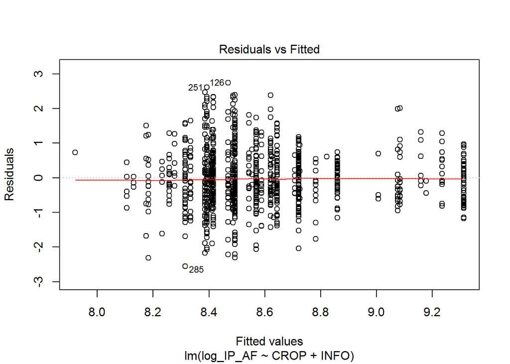

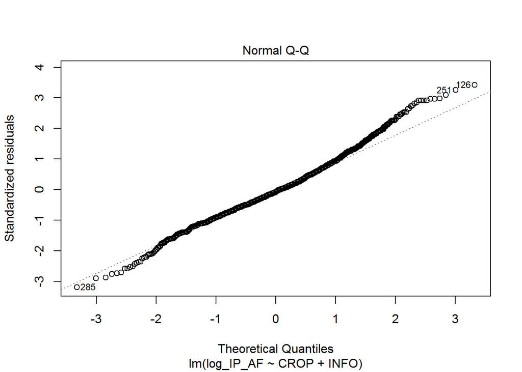

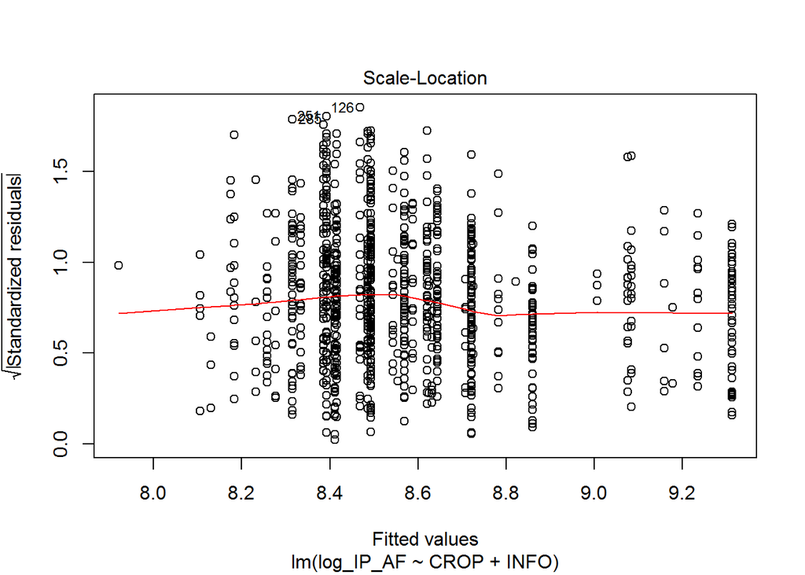

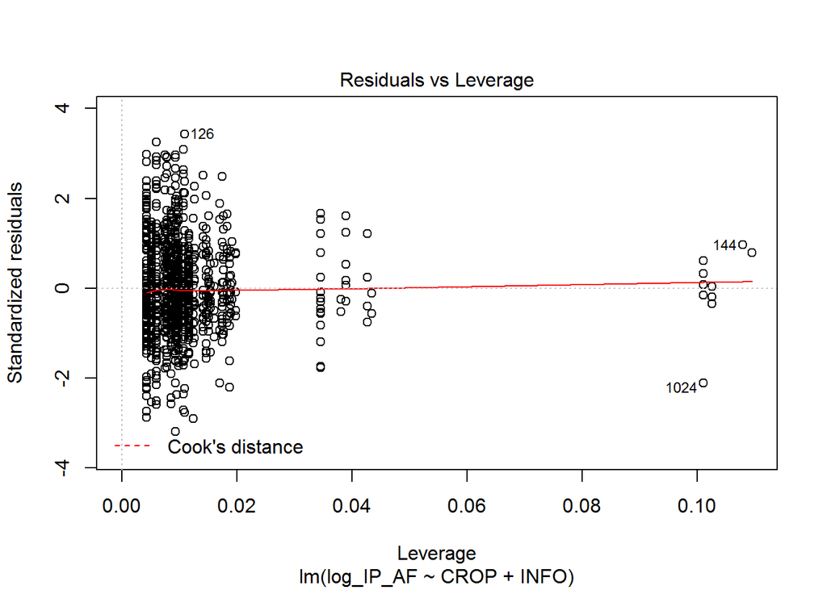

```r
# select only where INFO is not NA
info <- anova_data %>% filter(!is.na(INFO))

# INFORMATION
info_lm <- lm(log_IP_AF ~ CROP + INFO, data = info) # no interaction term because of NAs with 1 interactions
plot(info_lm)
```

```r
summary(info_lm)
```

```
##
## Call:
## lm(formula = log_IP_AF ~ CROP + INFO, data = info)
##
## Residuals:
##      Min       1Q   Median       3Q      Max
## -2.56000 -0.50865 -0.06318  0.46793  2.74371
##
## Coefficients:
##                                                         Estimate Std. Error
## (Intercept)                                              8.58779    0.14966
## CROPCORN_GRAIN                                           0.13820    0.09316
## CROPCORN_SILAGE                                          0.59068    0.08987
## CROPOTHER_HAY                                           -0.10111    0.06033
## CROPWHEAT                                               -0.31085    0.08195
## INFOEXTENSION AGENTS OR UNIVERSITY SPECIALISTS          -0.01857    0.16383
## INFOGOVERNMENT SPECIALISTS                              -0.10159    0.16550
## INFOIRRIGATION EQUIPMENT DEALERS                         0.05650    0.16495
## INFOLOCAL IRRIGATION DISTRICT EMPLOYEES                 -0.17161    0.16336
## INFOMEDIA REPORTS OR INFO IN THE PRESS                  -0.35637    0.29450
## INFONEIGHBORING FARMERS                                 -0.09424    0.15605
## INFOPRIVATE IFFIRGATION SPECIALISTS OR CROP CONSULTANTS  0.13442    0.15432
##                                                         t value
## (Intercept)                                              57.383
## CROPCORN_GRAIN                                            1.484
## CROPCORN_SILAGE                                           6.573
## CROPOTHER_HAY                                            -1.676
## CROPWHEAT                                                -3.793
## INFOEXTENSION AGENTS OR UNIVERSITY SPECIALISTS           -0.113
## INFOGOVERNMENT SPECIALISTS                               -0.614
## INFOIRRIGATION EQUIPMENT DEALERS                          0.343
## INFOLOCAL IRRIGATION DISTRICT EMPLOYEES                  -1.050
## INFOMEDIA REPORTS OR INFO IN THE PRESS                   -1.210
## INFONEIGHBORING FARMERS                                  -0.604
## INFOPRIVATE IFFIRGATION SPECIALISTS OR CROP CONSULTANTS   0.871
##                                                                     Pr(>|t|)
## (Intercept)                                             < 0.0000000000000002
## CROPCORN_GRAIN                                                      0.138216
## CROPCORN_SILAGE                                              0.0000000000754
## CROPOTHER_HAY                                                       0.094008
```

[output cut: 12 more lines]

```
## CROPOTHER_HAY                                           .
## CROPWHEAT                                               ***
## INFOEXTENSION AGENTS OR UNIVERSITY SPECIALISTS
## INFOGOVERNMENT SPECIALISTS
## INFOIRRIGATION EQUIPMENT DEALERS
## INFOLOCAL IRRIGATION DISTRICT EMPLOYEES
## INFOMEDIA REPORTS OR INFO IN THE PRESS
## INFONEIGHBORING FARMERS
## INFOPRIVATE IFFIRGATION SPECIALISTS OR CROP CONSULTANTS
## ---
## Signif. codes:  0 '***' 0.001 '**' 0.01 '*' 0.05 '.' 0.1 ' ' 1
##
## Residual standard error: 0.8047 on 1125 degrees of freedom
## Multiple R-squared:  0.08907,    Adjusted R-squared:  0.08017
## F-statistic:    10 on 11 and 1125 DF,  p-value: < 0.00000000000000022
```

```r
cropinfo_aov <- Anova(info_lm, type = "III")
cropinfo_aov
```

```
## Anova Table (Type III tests)
##
## Response: log_IP_AF
##              Sum Sq   Df   F value                Pr(>F)
## (Intercept) 2132.16    1 3292.8156 < 0.00000000000000022 ***
## CROP          50.46    4   19.4809  0.000000000000001632 ***
## INFO          12.67    7    2.7964              0.006891 **
## Residuals    728.46 1125
## ---
## Signif. codes:  0 '***' 0.001 '**' 0.01 '*' 0.05 '.' 0.1 ' ' 1
```

```r
# Let's do multiple one-way ANOVAs; ie. an ANOVA for each crop-information combination
# Alfalfa
alf_data <- info %>% filter(CROP == "ALFALFA")
alf_info_aov <- aov(log_IP_AF ~ INFO, data = alf_data)
summary(alf_info_aov) # mean ip is the same across information type in Alfalfa
```

```
##              Df Sum Sq Mean Sq F value Pr(>F)
## INFO          7    2.5  0.3611   0.551  0.796
## Residuals   541  354.8  0.6559
```

```r
# Corn grain
cg_data <- info %>% filter(CROP == "CORN_GRAIN")
cg_info_aov <- aov(log_IP_AF ~ INFO, data = cg_data)
summary(cg_info_aov) # mean ip is NOT the same across information sources in Corn Grain
```

```
##             Df Sum Sq Mean Sq F value Pr(>F)
## INFO         6  3.906  0.6511   2.796 0.0156 *
## Residuals   87 20.260  0.2329
## ---
## Signif. codes:  0 '***' 0.001 '**' 0.01 '*' 0.05 '.' 0.1 ' ' 1
```

```r
cg_info_post_hoc <- TukeyHSD(cg_info_aov)
cg_info_post_hoc
```

```
##   Tukey multiple comparisons of means
##     95% family-wise confidence level
##
## Fit: aov(formula = log_IP_AF ~ INFO, data = cg_data)
##
## $INFO
##                                                                                                        diff
## EXTENSION AGENTS OR UNIVERSITY SPECIALISTS-ELECTRONIC INFORMATION SERVICES                     -0.122426941
## GOVERNMENT SPECIALISTS-ELECTRONIC INFORMATION SERVICES                                         -0.100967079
## IRRIGATION EQUIPMENT DEALERS-ELECTRONIC INFORMATION SERVICES                                   -0.346441524
## LOCAL IRRIGATION DISTRICT EMPLOYEES-ELECTRONIC INFORMATION SERVICES                             0.010717837
## NEIGHBORING FARMERS-ELECTRONIC INFORMATION SERVICES                                            -0.340833667
## PRIVATE IFFIRGATION SPECIALISTS OR CROP CONSULTANTS-ELECTRONIC INFORMATION SERVICES             0.158820659
## GOVERNMENT SPECIALISTS-EXTENSION AGENTS OR UNIVERSITY SPECIALISTS                               0.021459862
## IRRIGATION EQUIPMENT DEALERS-EXTENSION AGENTS OR UNIVERSITY SPECIALISTS                        -0.224014584
## LOCAL IRRIGATION DISTRICT EMPLOYEES-EXTENSION AGENTS OR UNIVERSITY SPECIALISTS                  0.133144778
## NEIGHBORING FARMERS-EXTENSION AGENTS OR UNIVERSITY SPECIALISTS                                 -0.218406726
## PRIVATE IFFIRGATION SPECIALISTS OR CROP CONSULTANTS-EXTENSION AGENTS OR UNIVERSITY SPECIALISTS  0.281247600
## IRRIGATION EQUIPMENT DEALERS-GOVERNMENT SPECIALISTS                                            -0.245474445
## LOCAL IRRIGATION DISTRICT EMPLOYEES-GOVERNMENT SPECIALISTS                                      0.111684916
## NEIGHBORING FARMERS-GOVERNMENT SPECIALISTS                                                     -0.239866588
## PRIVATE IFFIRGATION SPECIALISTS OR CROP CONSULTANTS-GOVERNMENT SPECIALISTS                      0.259787739
## LOCAL IRRIGATION DISTRICT EMPLOYEES-IRRIGATION EQUIPMENT DEALERS                                0.357159361
## NEIGHBORING FARMERS-IRRIGATION EQUIPMENT DEALERS                                                0.005607857
## PRIVATE IFFIRGATION SPECIALISTS OR CROP CONSULTANTS-IRRIGATION EQUIPMENT DEALERS                0.505262184
## NEIGHBORING FARMERS-LOCAL IRRIGATION DISTRICT EMPLOYEES                                        -0.351551504
## PRIVATE IFFIRGATION SPECIALISTS OR CROP CONSULTANTS-LOCAL IRRIGATION DISTRICT EMPLOYEES         0.148102823
## PRIVATE IFFIRGATION SPECIALISTS OR CROP CONSULTANTS-NEIGHBORING FARMERS                         0.499654326
##                                                                                                        lwr
## EXTENSION AGENTS OR UNIVERSITY SPECIALISTS-ELECTRONIC INFORMATION SERVICES                     -1.03540298
## GOVERNMENT SPECIALISTS-ELECTRONIC INFORMATION SERVICES                                         -1.07808799
## IRRIGATION EQUIPMENT DEALERS-ELECTRONIC INFORMATION SERVICES                                   -1.19691612
## LOCAL IRRIGATION DISTRICT EMPLOYEES-ELECTRONIC INFORMATION SERVICES                            -1.10178326
## NEIGHBORING FARMERS-ELECTRONIC INFORMATION SERVICES                                            -1.21614485
## PRIVATE IFFIRGATION SPECIALISTS OR CROP CONSULTANTS-ELECTRONIC INFORMATION SERVICES            -0.59550124
## GOVERNMENT SPECIALISTS-EXTENSION AGENTS OR UNIVERSITY SPECIALISTS                              -0.83144120
## IRRIGATION EQUIPMENT DEALERS-EXTENSION AGENTS OR UNIVERSITY SPECIALISTS                        -0.92827445
## LOCAL IRRIGATION DISTRICT EMPLOYEES-EXTENSION AGENTS OR UNIVERSITY SPECIALISTS                 -0.87200876
## NEIGHBORING FARMERS-EXTENSION AGENTS OR UNIVERSITY SPECIALISTS                                 -0.95246708
## PRIVATE IFFIRGATION SPECIALISTS OR CROP CONSULTANTS-EXTENSION AGENTS OR UNIVERSITY SPECIALISTS -0.30328338
```

[output cut: 39 more lines]

```
## GOVERNMENT SPECIALISTS-EXTENSION AGENTS OR UNIVERSITY SPECIALISTS                              1.0000000
## IRRIGATION EQUIPMENT DEALERS-EXTENSION AGENTS OR UNIVERSITY SPECIALISTS                        0.9610765
## LOCAL IRRIGATION DISTRICT EMPLOYEES-EXTENSION AGENTS OR UNIVERSITY SPECIALISTS                 0.9996655
## NEIGHBORING FARMERS-EXTENSION AGENTS OR UNIVERSITY SPECIALISTS                                 0.9719434
## PRIVATE IFFIRGATION SPECIALISTS OR CROP CONSULTANTS-EXTENSION AGENTS OR UNIVERSITY SPECIALISTS 0.7716675
## IRRIGATION EQUIPMENT DEALERS-GOVERNMENT SPECIALISTS                                            0.9643074
## LOCAL IRRIGATION DISTRICT EMPLOYEES-GOVERNMENT SPECIALISTS                                     0.9999137
## NEIGHBORING FARMERS-GOVERNMENT SPECIALISTS                                                     0.9730042
## PRIVATE IFFIRGATION SPECIALISTS OR CROP CONSULTANTS-GOVERNMENT SPECIALISTS                     0.9095700
## LOCAL IRRIGATION DISTRICT EMPLOYEES-IRRIGATION EQUIPMENT DEALERS                               0.9150324
## NEIGHBORING FARMERS-IRRIGATION EQUIPMENT DEALERS                                               1.0000000
## PRIVATE IFFIRGATION SPECIALISTS OR CROP CONSULTANTS-IRRIGATION EQUIPMENT DEALERS               0.0330893
## NEIGHBORING FARMERS-LOCAL IRRIGATION DISTRICT EMPLOYEES                                        0.9286542
## PRIVATE IFFIRGATION SPECIALISTS OR CROP CONSULTANTS-LOCAL IRRIGATION DISTRICT EMPLOYEES        0.9985357
## PRIVATE IFFIRGATION SPECIALISTS OR CROP CONSULTANTS-NEIGHBORING FARMERS                        0.0715850
```